# NHB Analysis

Adeline Lo

This version: December 2025

```r
rm(list=ls())

pacman::p_load(here,Hmisc,dplyr,lubridate,gridExtra,grid,stargazer,hrbrthemes,quanteda,readtext,tidyverse,knitr,papeR,tidyr,kableExtra,ggpubr,printr,tab,lfe,sjPlot,clusterSEs,BBmisc,miceadds,mediation,estimatr,sensemakr,SentimentAnalysis,ggplot2,ggridges,viridis,BayesFactor,mediation,broom,scales)

source(here::here("Code","R_fns.R"))
exists("classify_education")
```

```
## [1] TRUE
```

# 1 Study 1

Peer Praise effects on Racial/Ethnic Outgroup Inclusion

## 1.1 Clean preprocess data

```r
data1<-readRDS(here::here("Data/Survey Data/Main Study 1/Study1Wave1.rds"))
data2<-readRDS(here::here("Data/Survey Data/Main Study 1/Study1Wave2.rds"))

#######################################################################
###### CLEAN DATA -- PUBLIC DEIDENTIFIED VERSION STARTS HERE ##########
#######################################################################

### Treatment ###
data1$PraiseControl<-ifelse(data1$treatment=="empathetic",1,ifelse(data1$treatment=="control",0,NA))
data1$PraisePlacebo<-ifelse(data1$treatment=="empathetic",1,ifelse(data1$treatment=="placebo",0,NA))
data1$PlaceboControl<-ifelse(data1$treatment=="placebo",1,ifelse(data1$treatment=="control",0,NA))
data2$PraiseControl<-ifelse(data2$treatment=="empathetic",1,ifelse(data2$treatment=="control",0,NA))
data2$PraisePlacebo<-ifelse(data2$treatment=="empathetic",1,ifelse(data2$treatment=="placebo",0,NA))
data2$PlaceboControl<-ifelse(data2$treatment=="placebo",1,ifelse(data2$treatment=="control",0,NA))
### Covs ###
#Race
data1$raceWhite<-ifelse(data1$race=="White, not-Hispanic",1,0)#not include multirace -- only strictly White
data2$raceWhite<-ifelse(data2$race=="White, not-Hispanic",1,0)
data1$raceBH <- ifelse(
  grepl("Black or African American", data1$race) |
  grepl("Hispanic or Latino", data1$race),
  1, ifelse(data1$raceWhite==1,0,NA)
)
data2$raceBH <- ifelse(
  grepl("Black or African American", data2$race) |
  grepl("Hispanic or Latino", data2$race),
  1, ifelse(data2$raceWhite==1,0,NA)
)
data1$min<-as.numeric(data1$Duration..in.seconds.)/60
data2$min<-as.numeric(data2$Duration..in.seconds.)/60
#Ethnocentrism: higher values more ethnocentric
  #culturebackward
data1$ethnocentrism_1n <- ifelse(data1$ethnocentrism_1=="Strongly disagree",0,ifelse(data1$ethnocentrism_1=="Disagree",1,ifelse(data1$ethnocentrism_1=="Neutral",2,ifelse(data1$ethnocentrism_1=="Agree",3,ifelse(data1$ethnocentrism_1=="Strongly agree",4,NA)))))
  #rolemodel
data1$ethnocentrism_2n <- ifelse(data1$ethnocentrism_2=="Strongly disagree",0,ifelse(data1$ethnocentrism_2=="Disagree",1,ifelse(data1$ethnocentrism_2=="Neutral",2,ifelse(data1$ethnocentrism_2=="Agree",3,ifelse(data1$ethnocentrism_2=="Strongly agree",4,NA)))))
  #actstrange
data1$ethnocentrism_3n <- ifelse(data1$ethnocentrism_3=="Strongly disagree",0,ifelse(data1$ethnocentrism_3=="Disagree",1,ifelse(data1$ethnocentrism_3=="Neutral",2,ifelse(data1$ethnocentrism_3=="Agree",3,ifelse(data1$ethnocentrism_3=="Strongly agree",4,NA)))))
  #othersvalid --- reverse code
data1$ethnocentrism_4n <- ifelse(data1$ethnocentrism_4=="Strongly disagree",4,ifelse(data1$ethnocentrism_4=="Disagree",3,ifelse(data1$ethnocentrism_4=="Neutral",2,ifelse(data1$ethnocentrism_4=="Agree",1,ifelse(data1$ethnocentrism_4=="Strongly agree",0,NA)))))
  #othersshouldbelikemine
data1$ethnocentrism_5n <- ifelse(data1$ethnocentrism_5=="Strongly disagree",0,ifelse(data1$ethnocentrism_5=="Disagree",1,ifelse(data1$ethnocentrism_5=="Neutral",2,ifelse(data1$ethnocentrism_5=="Agree",3,ifelse(data1$ethnocentrism_5=="Strongly agree",4,NA)))))
  #notinterested
data1$ethnocentrism_6n <- ifelse(data1$ethnocentrism_6=="Strongly disagree",0,ifelse(data1$ethnocentrism_6=="Disagree",1,ifelse(data1$ethnocentrism_6=="Neutral",2,ifelse(data1$ethnocentrism_6=="Agree",3,ifelse(data1$ethnocentrism_6=="Strongly agree",4,NA)))))
  #learnfromothers --- reverse code
data1$ethnocentrism_7n <- ifelse(data1$ethnocentrism_7=="Strongly disagree",4,ifelse(data1$ethnocentrism_7=="Disagree",3,ifelse(data1$ethnocentrism_7=="Neutral",2,ifelse(data1$ethnocentrism_7=="Agree",1,ifelse(data1$ethnocentrism_7=="Strongly agree",0,NA)))))
  #dkwhatsgood
data1$ethnocentrism_8n <- ifelse(data1$ethnocentrism_8=="Strongly disagree",0,ifelse(data1$ethnocentrism_8=="Disagree",1,ifelse(data1$ethnocentrism_8=="Neutral",2,ifelse(data1$ethnocentrism_8=="Agree",3,ifelse(data1$ethnocentrism_8=="Strongly agree",4,NA)))))
  #create index
data1$ethnocentrism_index<-rowSums(data1[, c("ethnocentrism_1n", "ethnocentrism_2n", "ethnocentrism_3n", "ethnocentrism_4n","ethnocentrism_5n","ethnocentrism_6n","ethnocentrism_7n","ethnocentrism_8n")], na.rm = FALSE)

data2$ethnocentrism_1n <- ifelse(data2$ethnocentrism_1=="Strongly disagree",0,ifelse(data2$ethnocentrism_1=="Disagree",1,ifelse(data2$ethnocentrism_1=="Neutral",2,ifelse(data2$ethnocentrism_1=="Agree",3,ifelse(data2$ethnocentrism_1=="Strongly agree",4,NA)))))
  #rolemodel
data2$ethnocentrism_2n <- ifelse(data2$ethnocentrism_2=="Strongly disagree",0,ifelse(data2$ethnocentrism_2=="Disagree",1,ifelse(data2$ethnocentrism_2=="Neutral",2,ifelse(data2$ethnocentrism_2=="Agree",3,ifelse(data2$ethnocentrism_2=="Strongly agree",4,NA)))))
  #actstrange
data2$ethnocentrism_3n <- ifelse(data2$ethnocentrism_3=="Strongly disagree",0,ifelse(data2$ethnocentrism_3=="Disagree",1,ifelse(data2$ethnocentrism_3=="Neutral",2,ifelse(data2$ethnocentrism_3=="Agree",3,ifelse(data2$ethnocentrism_3=="Strongly agree",4,NA)))))
  #othersvalid --- reverse code
data2$ethnocentrism_4n <- ifelse(data2$ethnocentrism_4=="Strongly disagree",4,ifelse(data2$ethnocentrism_4=="Disagree",3,ifelse(data2$ethnocentrism_4=="Neutral",2,ifelse(data2$ethnocentrism_4=="Agree",1,ifelse(data2$ethnocentrism_4=="Strongly agree",0,NA)))))
  #othersshouldbelikemine
data2$ethnocentrism_5n <- ifelse(data2$ethnocentrism_5=="Strongly disagree",0,ifelse(data2$ethnocentrism_5=="Disagree",1,ifelse(data2$ethnocentrism_5=="Neutral",2,ifelse(data2$ethnocentrism_5=="Agree",3,ifelse(data2$ethnocentrism_5=="Strongly agree",4,NA)))))
  #notinterested
data2$ethnocentrism_6n <- ifelse(data2$ethnocentrism_6=="Strongly disagree",0,ifelse(data2$ethnocentrism_6=="Disagree",1,ifelse(data2$ethnocentrism_6=="Neutral",2,ifelse(data2$ethnocentrism_6=="Agree",3,ifelse(data2$ethnocentrism_6=="Strongly agree",4,NA)))))
  #learnfromothers --- reverse code
data2$ethnocentrism_7n <- ifelse(data2$ethnocentrism_7=="Strongly disagree",4,ifelse(data2$ethnocentrism_7=="Disagree",3,ifelse(data2$ethnocentrism_7=="Neutral",2,ifelse(data2$ethnocentrism_7=="Agree",1,ifelse(data2$ethnocentrism_7=="Strongly agree",0,NA)))))
  #dkwhatsgood
data2$ethnocentrism_8n <- ifelse(data2$ethnocentrism_8=="Strongly disagree",0,ifelse(data2$ethnocentrism_8=="Disagree",1,ifelse(data2$ethnocentrism_8=="Neutral",2,ifelse(data2$ethnocentrism_8=="Agree",3,ifelse(data2$ethnocentrism_8=="Strongly agree",4,NA)))))
  #create index
data2$ethnocentrism_index<-rowSums(data2[, c("ethnocentrism_1n", "ethnocentrism_2n", "ethnocentrism_3n", "ethnocentrism_4n","ethnocentrism_5n","ethnocentrism_6n","ethnocentrism_7n","ethnocentrism_8n")], na.rm = FALSE)
```

```r
#Age
data1$age<-as.numeric(data1$age)
data2$age<-as.numeric(data2$age)
#Sex
data1$sex<-factor(data1$sex,levels=c("Female","Male","Non-binary","Other"))
data2$sex<-factor(data2$sex,levels=c("Female","Male","Non-binary","Other"))
#Educ: code a version that is up to and including HS, college of Assoc degree, beyond college code as L, M, H

data1$education_level <- sapply(data1$education, classify_education)
data1$education_level <- factor(data1$education_level, levels = c("Low", "Medium", "High"))
data2$education_level <- sapply(data2$education, classify_education)
data2$education_level <- factor(data2$education_level, levels = c("Low", "Medium", "High"))

#Political Party: code version D, I, R
data1$party<-ifelse(data1$party_id=="Strong Democrat"|data1$party_id=="Democrat"|data1$party_id=="Lean Democrat","Democrat",ifelse(data1$party_id=="Strong Republican"|data1$party_id=="Republican"|data1$party_id=="Lean Republican","Republican",ifelse(data1$party_id=="Independent","Independent",NA)))
data1$party<-factor(data1$party,levels=c("Republican","Independent","Democrat"))

data2$party<-ifelse(data2$party_id=="Strong Democrat"|data2$party_id=="Democrat"|data2$party_id=="Lean Democrat","Democrat",ifelse(data2$party_id=="Strong Republican"|data2$party_id=="Republican"|data2$party_id=="Lean Republican","Republican",ifelse(data2$party_id=="Independent","Independent",NA)))
data2$party<-factor(data2$party,levels=c("Republican","Independent","Democrat"))

#Income
income_levels <- c("Less than 25k", "25k to less than 50k", "50k to less than 75k", "75k to less than 100k", "100k or more")
# Convert the income variable to an ordered factor
data1$income <- factor(data1$income, levels = income_levels, ordered = TRUE)

#Baseline Empathy - Post11--Empathy Battery (measured post DV)
  #inshoes
data1$base_empathy1 <- as.numeric(gsub("\\D.*", "", data1$post11_1))
  #imagineinplace
data1$base_empathy2 <- as.numeric(gsub("\\D.*", "", data1$post11_2))
  #tenderconcern
data1$base_empathy3 <- as.numeric(gsub("\\D.*", "", data1$post11_3))
  #protective
data1$base_empathy4 <- as.numeric(gsub("\\D.*", "", data1$post11_4))
  #emotional situation scares me: reverse code
data1$base_empathy5 <- ifelse(data1$post11_5=="5\nDescribes me very well",1,ifelse(data1$post11_5=="4\nDescribes me",2,ifelse(data1$post11_5=="3\nSomewhat describes me",3,ifelse(data1$post11_5=="2\nDoes not describe me",4,ifelse(data1$post11_5=="1\nDoes not describe me well",5,NA)))))
  #emergencypieces
data1$base_empathy6 <- as.numeric(gsub("\\D.*", "", data1$post11_6))
  #storynovel
data1$base_empathy7 <- as.numeric(gsub("\\D.*", "", data1$post11_7))
  #movie
data1$base_empathy8 <- as.numeric(gsub("\\D.*", "", data1$post11_8))
  #index
data1$base_empathy <- rowSums(data1[, c("base_empathy1", "base_empathy2", "base_empathy3", "base_empathy4", "base_empathy5","base_empathy6","base_empathy7","base_empathy8")], na.rm = FALSE)
#Desirable to be empathetic (personal belief)
data1$empathy_desirable <- ifelse(data1$post17=="Objectivity is much more desirable",0,ifelse(data1$post17=="Objectivity is more desirable",1,ifelse(data1$post17=="They are equally desirable",2,ifelse(data1$post17=="Empathy is more desirable",3,ifelse(data1$post17=="Empathy is much more desirable",4,NA)))))
#Norms: how strongly agree/disagree people value empathetic behavior
data1$norms_n<-ifelse(data1$norms=="Strongly disagree",0,ifelse(data1$norms=="Disagree",1,ifelse(data1$norms=="Neither agree nor disagree",2,ifelse(data1$norms=="Agree",3,ifelse(data1$norms=="Strongly agree",4,NA)))))
data2$norms_n<-ifelse(data2$norms=="Strongly disagree",0,ifelse(data2$norms=="Disagree",1,ifelse(data2$norms=="Neither agree nor disagree",2,ifelse(data2$norms=="Agree",3,ifelse(data2$norms=="Strongly agree",4,NA)))))
#Emotions:
  ##Happy: indiv vars numeric, and indexed together
data1$Happy_1_n<-ifelse(data1$Happy_1=="Very slightly or not at all",0,ifelse(data1$Happy_1=="A little",1,ifelse(data1$Happy_1=="Moderately",2,ifelse(data1$Happy_1=="Quite a lot",3,ifelse(data1$Happy_1=="Extremely",4,NA)))))
data1$Happy_2_n<-ifelse(data1$Happy_2=="Very slightly or not at all",0,ifelse(data1$Happy_2=="A little",1,ifelse(data1$Happy_2=="Moderately",2,ifelse(data1$Happy_2=="Quite a lot",3,ifelse(data1$Happy_2=="Extremely",4,NA)))))
data1$Happy_3_n<-ifelse(data1$Happy_3=="Very slightly or not at all",0,ifelse(data1$Happy_3=="A little",1,ifelse(data1$Happy_3=="Moderately",2,ifelse(data1$Happy_3=="Quite a lot",3,ifelse(data1$Happy_3=="Extremely",4,NA)))))
data1$Happy_index<-rowSums(data1[, c("Happy_1_n", "Happy_2_n", "Happy_3_n")], na.rm = FALSE)

data2$Happy_1_n<-ifelse(data2$Happy_1=="Very slightly or not at all",0,ifelse(data2$Happy_1=="A little",1,ifelse(data2$Happy_1=="Moderately",2,ifelse(data2$Happy_1=="Quite a lot",3,ifelse(data2$Happy_1=="Extremely",4,NA)))))
data2$Happy_2_n<-ifelse(data2$Happy_2=="Very slightly or not at all",0,ifelse(data2$Happy_2=="A little",1,ifelse(data2$Happy_2=="Moderately",2,ifelse(data2$Happy_2=="Quite a lot",3,ifelse(data2$Happy_2=="Extremely",4,NA)))))
data2$Happy_3_n<-ifelse(data2$Happy_3=="Very slightly or not at all",0,ifelse(data2$Happy_3=="A little",1,ifelse(data2$Happy_3=="Moderately",2,ifelse(data2$Happy_3=="Quite a lot",3,ifelse(data2$Happy_3=="Extremely",4,NA)))))
data2$Happy_index<-rowSums(data2[, c("Happy_1_n", "Happy_2_n", "Happy_3_n")], na.rm = FALSE)


  ##anxiety
data1$anxiety_1_n<-ifelse(data1$anxiety_1=="Very slightly or not at all",0,ifelse(data1$anxiety_1=="A little",1,ifelse(data1$anxiety_1=="Moderately",2,ifelse(data1$anxiety_1=="Quite a lot",3,ifelse(data1$anxiety_1=="Extremely",4,NA)))))
data1$anxiety_2_n<-ifelse(data1$anxiety_2=="Very slightly or not at all",0,ifelse(data1$anxiety_2=="A little",1,ifelse(data1$anxiety_2=="Moderately",2,ifelse(data1$anxiety_2=="Quite a lot",3,ifelse(data1$anxiety_2=="Extremely",4,NA)))))
data1$anxiety_3_n<-ifelse(data1$anxiety_3=="Very slightly or not at all",0,ifelse(data1$anxiety_3=="A little",1,ifelse(data1$anxiety_3=="Moderately",2,ifelse(data1$anxiety_3=="Quite a lot",3,ifelse(data1$anxiety_3=="Extremely",4,NA)))))
data1$anxiety_index<-rowSums(data1[, c("anxiety_1_n", "anxiety_2_n", "anxiety_3_n")], na.rm = FALSE)
```

```r
data2$anxiety_1_n<-ifelse(data2$anxiety_1=="Very slightly or not at all",0,ifelse(data2$anxiety_1=="A little",1,ifelse(data2$anxiety_1=="Moderately",2,ifelse(data2$anxiety_1=="Quite a lot",3,ifelse(data2$anxiety_1=="Extremely",4,NA)))))
data2$anxiety_2_n<-ifelse(data2$anxiety_2=="Very slightly or not at all",0,ifelse(data2$anxiety_2=="A little",1,ifelse(data2$anxiety_2=="Moderately",2,ifelse(data2$anxiety_2=="Quite a lot",3,ifelse(data2$anxiety_2=="Extremely",4,NA)))))
data2$anxiety_3_n<-ifelse(data2$anxiety_3=="Very slightly or not at all",0,ifelse(data2$anxiety_3=="A little",1,ifelse(data2$anxiety_3=="Moderately",2,ifelse(data2$anxiety_3=="Quite a lot",3,ifelse(data2$anxiety_3=="Extremely",4,NA)))))
data2$anxiety_index<-rowSums(data2[, c("anxiety_1_n", "anxiety_2_n", "anxiety_3_n")], na.rm = FALSE)


  ##anger
data1$anger_1_n<-ifelse(data1$anger_1=="Very slightly or not at all",0,ifelse(data1$anger_1=="A little",1,ifelse(data1$anger_1=="Moderately",2,ifelse(data1$anger_1=="Quite a lot",3,ifelse(data1$anger_1=="Extremely",4,NA)))))
data1$anger_2_n<-ifelse(data1$anger_2=="Very slightly or not at all",0,ifelse(data1$anger_2=="A little",1,ifelse(data1$anger_2=="Moderately",2,ifelse(data1$anger_2=="Quite a lot",3,ifelse(data1$anger_2=="Extremely",4,NA)))))
data1$anger_3_n<-ifelse(data1$anger_3=="Very slightly or not at all",0,ifelse(data1$anger_3=="A little",1,ifelse(data1$anger_3=="Moderately",2,ifelse(data1$anger_3=="Quite a lot",3,ifelse(data1$anger_3=="Extremely",4,NA)))))
data1$anger_index<-rowSums(data1[, c("anger_1_n", "anger_2_n", "anger_3_n")], na.rm = FALSE)

data2$anger_1_n<-ifelse(data2$anger_1=="Very slightly or not at all",0,ifelse(data2$anger_1=="A little",1,ifelse(data2$anger_1=="Moderately",2,ifelse(data2$anger_1=="Quite a lot",3,ifelse(data2$anger_1=="Extremely",4,NA)))))
data2$anger_2_n<-ifelse(data2$anger_2=="Very slightly or not at all",0,ifelse(data2$anger_2=="A little",1,ifelse(data2$anger_2=="Moderately",2,ifelse(data2$anger_2=="Quite a lot",3,ifelse(data2$anger_2=="Extremely",4,NA)))))
data2$anger_3_n<-ifelse(data2$anger_3=="Very slightly or not at all",0,ifelse(data2$anger_3=="A little",1,ifelse(data2$anger_3=="Moderately",2,ifelse(data2$anger_3=="Quite a lot",3,ifelse(data2$anger_3=="Extremely",4,NA)))))
data2$anger_index<-rowSums(data2[, c("anger_1_n", "anger_2_n", "anger_3_n")], na.rm = FALSE)

#Manipulation check (man_check)
data1$pass_manipcheckstrict<-ifelse((data1$man_check=="Yes"&data1$treatment=="empathetic")|(data1$man_check=="No"&data1$treatment=="control")|(data1$man_check=="No"&data1$treatment=="placebo"),1,0) #strict rule
data1$pass_manipchecklax<-ifelse((data1$man_check=="Yes"&data1$treatment=="empathetic")|(data1$man_check=="No"&data1$treatment=="control")|(data1$man_check=="No"&data1$treatment=="placebo")|(data1$man_check=="Not sure"&data1$treatment=="empathetic")|(data1$man_check=="Not sure"&data1$treatment=="placebo"),1,0) #lax rule
#Peers -- extent see other mturkers as peers, learn or gather info from other mturkers, value other mturkers' opinions
data1$peers_1<-factor(data1$peers_1,levels=c("Strongly disagree", "Disagree", "Neither agree nor disagree", "Agree", "Strongly agree"),ordered=T)
data1$peers_1n<-ifelse(data1$peers_1=="Strongly disagree",0,ifelse(data1$peers_1=="Disagree",1,ifelse(data1$peers_1=="Neither agree nor disagree",2,ifelse(data1$peers_1=="Agree",3,ifelse(data1$peers_1=="Strongly agree",4,NA)))))
data1$peers_2<-factor(data1$peers_2,levels=c("Strongly disagree", "Disagree", "Neither agree nor disagree", "Agree", "Strongly agree"),ordered=T)
data1$peers_2n<-ifelse(data1$peers_2=="Strongly disagree",0,ifelse(data1$peers_2=="Disagree",1,ifelse(data1$peers_2=="Neither agree nor disagree",2,ifelse(data1$peers_2=="Agree",3,ifelse(data1$peers_2=="Strongly agree",4,NA)))))
data1$peers_3<-factor(data1$peers_3,levels=c("Strongly disagree", "Disagree", "Neither agree nor disagree", "Agree", "Strongly agree"),ordered=T)
data1$peers_3n<-ifelse(data1$peers_3=="Strongly disagree",0,ifelse(data1$peers_3=="Disagree",1,ifelse(data1$peers_3=="Neither agree nor disagree",2,ifelse(data1$peers_3=="Agree",3,ifelse(data1$peers_3=="Strongly agree",4,NA)))))
data1$peers_index<-rowSums(data1[, c("peers_1n", "peers_2n", "peers_3n")], na.rm = FALSE)

data2$peers_1<-factor(data2$peers_1,levels=c("Strongly disagree", "Disagree", "Neither agree nor disagree", "Agree", "Strongly agree"),ordered=T)
data2$peers_1n<-ifelse(data2$peers_1=="Strongly disagree",0,ifelse(data2$peers_1=="Disagree",1,ifelse(data2$peers_1=="Neither agree nor disagree",2,ifelse(data2$peers_1=="Agree",3,ifelse(data2$peers_1=="Strongly agree",4,NA)))))
data2$peers_2<-factor(data2$peers_2,levels=c("Strongly disagree", "Disagree", "Neither agree nor disagree", "Agree", "Strongly agree"),ordered=T)
data2$peers_2n<-ifelse(data2$peers_2=="Strongly disagree",0,ifelse(data2$peers_2=="Disagree",1,ifelse(data2$peers_2=="Neither agree nor disagree",2,ifelse(data2$peers_2=="Agree",3,ifelse(data2$peers_2=="Strongly agree",4,NA)))))
data2$peers_3<-factor(data2$peers_3,levels=c("Strongly disagree", "Disagree", "Neither agree nor disagree", "Agree", "Strongly agree"),ordered=T)
data2$peers_3n<-ifelse(data2$peers_3=="Strongly disagree",0,ifelse(data2$peers_3=="Disagree",1,ifelse(data2$peers_3=="Neither agree nor disagree",2,ifelse(data2$peers_3=="Agree",3,ifelse(data2$peers_3=="Strongly agree",4,NA)))))
data2$peers_index<-rowSums(data2[, c("peers_1n", "peers_2n", "peers_3n")], na.rm = FALSE)

#Trump approval (measured post DV)
data1$trump_approval_n<-ifelse(data1$trump_approval=="Disapprove extremely strongly",0,ifelse(data1$trump_approval=="Disapprove moderately strongly",1,ifelse(data1$trump_approval=="Disapprove slightly",2,ifelse(data1$trump_approval=="Neither approve nor disapprove",3,ifelse(data1$trump_approval=="Approve slightly",4,ifelse(data1$trump_approval=="Approve moderately strongly",5,ifelse(data1$trump_approval=="Approve extremely strongly",6,NA))))))) #numeric
#Image information: image race/emotion
data1$Image_race<-substr(data1$ImageName, 1, 1)
data1$Image_raceBH<-ifelse(data1$Image_race=="B"|data1$Image_race=="L",1,ifelse(data1$Image_race=="W",0,NA))
data1$Image_emotion<-substr(data1$ImageName, 2, 2)
```

```r
data2$Image_race<-substr(data2$ImageName, 1, 1)
data2$Image_raceBH<-ifelse(data2$Image_race=="B"|data2$Image_race=="L",1,ifelse(data2$Image_race=="W",0,NA))
data2$Image_emotion<-substr(data2$ImageName, 2, 2)

### DVs ###
# 1) EmpathyBehavior: Behavioral empathy task
data1$empathytask<-ifelse(data1$cards1=="IM_et9Fsf1O3VPwxnw",0,ifelse(data1$cards1=="IM_01Di3evwDTtxlFs",1,NA)) #"IM_et9Fsf1O3VPwxnw" is for describe=0, and "IM_01Di3evwDTtxlFs" is feel=1
data2$empathytask<-ifelse(data2$cards1=="IM_et9Fsf1O3VPwxnw",0,ifelse(data2$cards1=="IM_01Di3evwDTtxlFs",1,NA))
# 2) EmpathySelf: Self-reported empathy --  combine the responses to the statements into a single “Self-reported empathy” outcome measure (normalizing each and adding to an index taking values from 0 to 3).
  #EmpathySelfPre and Post
data1$pre_empathyself1<-ifelse(data1$empathyself1=="Strongly disagree",0,ifelse(data1$empathyself1=="Disagree",1,ifelse(data1$empathyself1=="Neither agree nor disagree",2,ifelse(data1$empathyself1=="Agree",3,ifelse(data1$empathyself1=="Strongly agree",4,NA)))))/4
data2$pre_empathyself1<-ifelse(data2$empathyself1=="Strongly disagree",0,ifelse(data2$empathyself1=="Disagree",1,ifelse(data2$empathyself1=="Neither agree nor disagree",2,ifelse(data2$empathyself1=="Agree",3,ifelse(data2$empathyself1=="Strongly agree",4,NA)))))/4

data1$pre_empathyself2<-ifelse(data1$empathyself2=="Strongly disagree",0,ifelse(data1$empathyself2=="Disagree",1,ifelse(data1$empathyself2=="Neither agree nor disagree",2,ifelse(data1$empathyself2=="Agree",3,ifelse(data1$empathyself2=="Strongly agree",4,NA)))))/4
data2$pre_empathyself2<-ifelse(data2$empathyself2=="Strongly disagree",0,ifelse(data2$empathyself2=="Disagree",1,ifelse(data2$empathyself2=="Neither agree nor disagree",2,ifelse(data2$empathyself2=="Agree",3,ifelse(data2$empathyself2=="Strongly agree",4,NA)))))/4

data1$pre_empathyself3<-ifelse(data1$empathyself3=="Strongly disagree",0,ifelse(data1$empathyself3=="Disagree",1,ifelse(data1$empathyself3=="Neither agree nor disagree",2,ifelse(data1$empathyself3=="Agree",3,ifelse(data1$empathyself3=="Strongly agree",4,NA)))))/4
data2$pre_empathyself3<-ifelse(data2$empathyself3=="Strongly disagree",0,ifelse(data2$empathyself3=="Disagree",1,ifelse(data2$empathyself3=="Neither agree nor disagree",2,ifelse(data2$empathyself3=="Agree",3,ifelse(data2$empathyself3=="Strongly agree",4,NA)))))/4

# Sum the original index variables (raw scores)
data1$pre_empathyselfindex <- rowSums(data1[, c("pre_empathyself1", "pre_empathyself2", "pre_empathyself3")], na.rm = FALSE)
data2$pre_empathyselfindex <- rowSums(data2[, c("pre_empathyself1", "pre_empathyself2", "pre_empathyself3")], na.rm = FALSE)

data1$post_empathyself1<-ifelse(data1$empathyself1b=="Strongly disagree",0,ifelse(data1$empathyself1b=="Disagree",1,ifelse(data1$empathyself1b=="Neither agree nor disagree",2,ifelse(data1$empathyself1b=="Agree",3,ifelse(data1$empathyself1b=="Strongly agree",4,NA)))))/4
data2$post_empathyself1<-ifelse(data2$empathyself1b=="Strongly disagree",0,ifelse(data2$empathyself1b=="Disagree",1,ifelse(data2$empathyself1b=="Neither agree nor disagree",2,ifelse(data2$empathyself1b=="Agree",3,ifelse(data2$empathyself1b=="Strongly agree",4,NA)))))/4

data1$post_empathyself2<-ifelse(data1$empathyself2b=="Strongly disagree",0,ifelse(data1$empathyself2b=="Disagree",1,ifelse(data1$empathyself2b=="Neither agree nor disagree",2,ifelse(data1$empathyself2b=="Agree",3,ifelse(data1$empathyself2b=="Strongly agree",4,NA)))))/4
data2$post_empathyself2<-ifelse(data2$empathyself2b=="Strongly disagree",0,ifelse(data2$empathyself2b=="Disagree",1,ifelse(data2$empathyself2b=="Neither agree nor disagree",2,ifelse(data2$empathyself2b=="Agree",3,ifelse(data2$empathyself2b=="Strongly agree",4,NA)))))/4

data1$post_empathyself3<-ifelse(data1$empathyself3b=="Strongly disagree",0,ifelse(data1$empathyself3b=="Disagree",1,ifelse(data1$empathyself3b=="Neither agree nor disagree",2,ifelse(data1$empathyself3b=="Agree",3,ifelse(data1$empathyself3b=="Strongly agree",4,NA)))))/4
data2$post_empathyself3<-ifelse(data2$empathyself3b=="Strongly disagree",0,ifelse(data2$empathyself3b=="Disagree",1,ifelse(data2$empathyself3b=="Neither agree nor disagree",2,ifelse(data2$empathyself3b=="Agree",3,ifelse(data2$empathyself3b=="Strongly agree",4,NA)))))/4

# Sum the original index variables (raw scores)
data1$post_empathyselfindex <- rowSums(data1[, c("post_empathyself1", "post_empathyself2", "post_empathyself3")], na.rm = FALSE)
data2$post_empathyselfindex <- rowSums(data2[, c("post_empathyself1", "post_empathyself2", "post_empathyself3")], na.rm = FALSE)

# 3) Attitudinal Inclusion Index -- combine from social distance and thermometer: We combine Social Distance and Thermometer into a single Attitudinal Outcome Index in which Social Distance and Thermometer take on equal weight; the Index ranges from [0,2].

#Social Distance (norm divided by 6 to have variable from 0-1)
data1$pre_socialdist <- ifelse(data1$social_dis1=="None",0,ifelse(data1$social_dis1=="Visitors",1,ifelse(data1$social_dis1=="Citizens",2,ifelse(data1$social_dis1=="Coworkers",3,ifelse(data1$social_dis1=="Neighbors",4,ifelse(data1$social_dis1=="Friends",5,ifelse(data1$social_dis1=="Relatives",6,NA)))))))/6
data2$pre_socialdist <- ifelse(data2$social_dis1=="None",0,ifelse(data2$social_dis1=="Visitors",1,ifelse(data2$social_dis1=="Citizens",2,ifelse(data2$social_dis1=="Coworkers",3,ifelse(data2$social_dis1=="Neighbors",4,ifelse(data2$social_dis1=="Friends",5,ifelse(data2$social_dis1=="Relatives",6,NA)))))))/6

data1$post_socialdist <- ifelse(data1$social_dis2=="None",0,ifelse(data1$social_dis2=="Visitors",1,ifelse(data1$social_dis2=="Citizens",2,ifelse(data1$social_dis2=="Coworkers",3,ifelse(data1$social_dis2=="Neighbors",4,ifelse(data1$social_dis2=="Friends",5,ifelse(data1$social_dis2=="Relatives",6,NA)))))))/6
data2$post_socialdist <- ifelse(data2$social_dis2=="None",0,ifelse(data2$social_dis2=="Visitors",1,ifelse(data1$social_dis2=="Citizens",2,ifelse(data2$social_dis2=="Coworkers",3,ifelse(data2$social_dis2=="Neighbors",4,ifelse(data2$social_dis2=="Friends",5,ifelse(data2$social_dis2=="Relatives",6,NA)))))))/6
#Thermometer
data1$pre_thermB<-as.numeric(data1$therm1_1)
data1$pre_thermH<-as.numeric(data1$therm1_2)
data1$pre_therm<-ifelse(is.na(data1$pre_thermB) | is.na(data1$pre_thermH), NA, (data1$pre_thermB+data1$pre_thermH) / 2)
```

```r
data1$post_thermB<-as.numeric(data1$therm2_1)
data1$post_thermH<-as.numeric(data1$therm2_2)
data1$post_therm<-ifelse(is.na(data1$post_thermB) | is.na(data1$post_thermH), NA, (data1$post_thermB+data1$post_thermH) / 2)

data2$pre_thermB<-as.numeric(data2$therm1_1)
data2$pre_thermH<-as.numeric(data2$therm1_2)
data2$pre_therm<-ifelse(is.na(data2$pre_thermB) | is.na(data2$pre_thermH), NA, (data2$pre_thermB+data2$pre_thermH) / 2)
data2$post_thermB<-as.numeric(data2$therm2_1)
data2$post_thermH<-as.numeric(data2$therm2_2)
data2$post_therm<-ifelse(is.na(data2$post_thermB) | is.na(data2$post_thermH), NA, (data2$post_thermB+data2$post_thermH) / 2)

#norm to 0-1 variable
data1$pre_therm<-data1$pre_therm/100
data1$post_therm<-data1$post_therm/100
data2$pre_therm<-data2$pre_therm/100
data2$post_therm<-data2$post_therm/100

# Create equal-weighted index (average of normalized values)
data1$post_attitudinalindex <- rowSums(data1[, c("post_socialdist", "post_therm")], na.rm = FALSE)
data1$pre_attitudinalindex <- rowSums(data1[, c("pre_socialdist", "pre_therm")], na.rm = FALSE)

data2$post_attitudinalindex <- rowSums(data2[, c("post_socialdist", "post_therm")], na.rm = FALSE)
data2$pre_attitudinalindex <- rowSums(data2[, c("pre_socialdist", "pre_therm")], na.rm = FALSE)

# 4) Behavioral Inclusion-- donation and letter normalized and weighted equally
  #Donation --sum donation_blm and donation_unidos
data1$donation_blm<-as.numeric(data1$donation_blm_1)
data1$donation_unidos<-as.numeric(data1$donation_unidos_1)
data1$donation<-rowSums(data1[, c("donation_blm", "donation_unidos")], na.rm = FALSE)
data2$donation_blm<-as.numeric(data2$donation_blm_1)
data2$donation_unidos<-as.numeric(data2$donation_unidos_1)
data2$donation<-rowSums(data2[, c("donation_blm", "donation_unidos")], na.rm = FALSE)
  #Letter: will need to create robust version that checks letter content matches
data1$letter<-ifelse(data1$letter=="Yes",1,ifelse(data1$letter=="No",0,NA))
data2$letter<-ifelse(data2$letter=="Yes",1,ifelse(data2$letter=="No",0,NA))
# Create equal-weighted index for Behavioral Inclusion
data1$behavioralindex <- rowMeans(data1[, c("donation", "letter")], na.rm = FALSE)
data2$behavioralindex <- rowMeans(data2[, c("donation", "letter")], na.rm = FALSE)
#Mechanisms
  #1) norms
  #2) happy -- Happy


#subset to white:
data1White<-subset(data1,raceWhite==1)
data2White<-subset(data2,raceWhite==1)

#Save Data
saveRDS(data1,file=here::here("Data","Survey Data","Main Study 1","study1w1full.rds")) #study 1 wave 1 full
saveRDS(data1White,file=here::here("Data","Survey Data","Main Study 1","study1w1.rds")) #study 1 wave 1 white
saveRDS(data2,file=here::here("Data","Survey Data","Main Study 1","study1w2full.rds")) #study 1 wave 2 full
saveRDS(data2White,file=here::here("Data","Survey Data","Main Study 1","study1w2.rds")) #study 1 wave 2 white


#Subset to White who see BH image
data1White_BH<-subset(data1White,Image_raceBH==1)
#Subset to White who see BH image
data2White_BH<-subset(data2White,Image_raceBH==1)
```

### 1.1.1 Balance tests

- find covariates by-chance imbalanced — we don’t find imbalance in sex, age, education, party and income variables.

```r
#Sex=sex,Age=age, Educ=education_level, Party=party, Income=income
table_sex <- table(data1$sex, data1$treatment)
res1<-chisq.test(table_sex)
res2<-t.test(age ~ PraiseControl, data = data1)
table_education <- table(data1$education, data1$treatment)
res3<-chisq.test(table_education)
table_party <- table(data1$party, data1$treatment)
res4<-chisq.test(table_party)
table_income <- table(data1$income, data1$treatment)
res5<-chisq.test(table_income)

results_df <- data.frame(
  var      = c("sex","age","education","party","income"),
  test     = c("chi-sq","t.test","chi-sq","chi-sq","chi-sq"),
  test_val = c(res1$statistic, res2$statistic, res3$statistic, res4$statistic, res5$statistic),
  pval     = c(res1$p.value, res2$p.value, res3$p.value, res4$p.value, res5$p.value)
)

# Output as LaTeX table (requires \usepackage{booktabs})
kable(
  results_df,
  format   = "latex",
  booktabs = TRUE,
  digits   = 3,
  col.names = c("Variable","Test","Statistic","p-value"),
  caption  = "Balance Tests Study 1",
  label    = "balance1"
)
#Table D.18 in Appendix
```

## 1.2 Registered Hypothesis Tests

### 1.2.1 H1: White respondents who receive peer praise are more likely to empathize with racial/ethnic outgroup members than respondents who do not receive peer praise.

- We run this test on white respondents who see a racial/ethnic outgroup image
- OLS coef test of Peer Praise on behavioral empathy task. Robustness check: OLS regression with controls for pre-treatment covariates that are imbalanced.

```r
#H1: DV is Behavioral Empathy
h1_model<-lm(empathytask~PraiseControl,data=data1White_BH)
summary(h1_model) #-0.01249, p=0.437
```

```
##
## Call:
## lm(formula = empathytask ~ PraiseControl, data = data1White_BH)
##
## Residuals:
##     Min      1Q  Median      3Q     Max
## -0.3735 -0.3735 -0.3610  0.6265  0.6390
##
## Coefficients:
##               Estimate Std. Error t value Pr(>|t|)
## (Intercept)    0.37348    0.01133  32.955   <2e-16 ***
## PraiseControl -0.01249    0.01609  -0.777    0.437
## ---
## Signif. codes:  0 '***' 0.001 '**' 0.01 '*' 0.05 '.' 0.1 ' ' 1
##
## Residual standard error: 0.4822 on 3592 degrees of freedom
##   (922 observations deleted due to missingness)
## Multiple R-squared:  0.0001679,  Adjusted R-squared:  -0.0001104
## F-statistic: 0.6033 on 1 and 3592 DF,  p-value: 0.4374
```

```r
confint(h1_model, level = 0.95) #-0.0440322 0.01904397
```

|  | 2.5 % | 97.5 % |
| --- | --- | --- |
| (Intercept) | 0.3512607 | 0.3957006 |
| PraiseControl | -0.0440322 | 0.0190440 |

```r
#summary(lm(empathytask~PraisePlacebo,data=data1White_BH))
```

### 1.2.2 H2: White respondents receiving peer praise are more likely to report empathizing with racial/ethnic outgroup members, compared to respondents who did not receive peer praise.

- OLS coef test of Peer Praise on self- reported empathy, an index created from three agreement statements, normalized and summed.

```r
#H2: DV is Self Reported Empathy
h2_model<-lm(post_empathyselfindex~PraiseControl,data=data1White)
summary(h2_model) #-0.010725,p=0.442
```

```
##
## Call:
## lm(formula = post_empathyselfindex ~ PraiseControl, data = data1White)
##
## Residuals:
##     Min      1Q  Median      3Q     Max
## -2.3907 -0.1407  0.1093  0.3593  0.6201
##
## Coefficients:
##                Estimate Std. Error t value Pr(>|t|)
## (Intercept)    2.390656   0.009819 243.465   <2e-16 ***
## PraiseControl -0.010725   0.013957  -0.768    0.442
## ---
## Signif. codes:  0 '***' 0.001 '**' 0.01 '*' 0.05 '.' 0.1 ' ' 1
##
## Residual standard error: 0.4439 on 4045 degrees of freedom
##   (1034 observations deleted due to missingness)
## Multiple R-squared:  0.000146,   Adjusted R-squared:  -0.0001012
## F-statistic: 0.5905 on 1 and 4045 DF,  p-value: 0.4423
```

```r
confint(h2_model, level = 0.95) #CIs for paper  -0.03808975 0.0166388
```

|  | 2.5 % | 97.5 % |
| --- | --- | --- |
| (Intercept) | 2.3714044 | 2.4099068 |
| PraiseControl | -0.0380897 | 0.0166388 |

```r
#h2_model_robustness<-lm(post_empathyselfindex~PraiseControl*pre_empathyselfindex,data=data1White)
#summary(h2_model_robustness) #not pre-registered just checking
```

### 1.2.3 H3: White respondents who receive peer praise are more likely to act politically inclusively towards racial/ethnic outgroup members, compared to respondents who don’t receive peer praise.

```r
#H3: Political Inclusion
h3_model<-lm(behavioralindex~PraiseControl,data=data1White)
summary(h3_model)  #0.030553, p=0.00156
```

```
##
## Call:
## lm(formula = behavioralindex ~ PraiseControl, data = data1White)
##
## Residuals:
##      Min       1Q   Median       3Q      Max
## -0.42686 -0.22686 -0.09631  0.32314  0.60369
##
## Coefficients:
##               Estimate Std. Error t value Pr(>|t|)
## (Intercept)   0.396306   0.006792  58.348  < 2e-16 ***
## PraiseControl 0.030553   0.009654   3.165  0.00156 **
## ---
## Signif. codes:  0 '***' 0.001 '**' 0.01 '*' 0.05 '.' 0.1 ' ' 1
##
## Residual standard error: 0.3071 on 4045 degrees of freedom
##   (1034 observations deleted due to missingness)
## Multiple R-squared:  0.00247,    Adjusted R-squared:  0.002223
## F-statistic: 10.02 on 1 and 4045 DF,  p-value: 0.001564
```

```r
confint(h3_model, level = 0.95) #CIs for paper 0.01162539 0.0494815
```

|  | 2.5 % | 97.5 % |
| --- | --- | --- |
| (Intercept) | 0.3829901 | 0.4096224 |
| PraiseControl | 0.0116254 | 0.0494815 |

```r
#0.030553/ sd(data1White$behavioralindex, na.rm = TRUE) #the treatment increases the outcome by ~0.1 standard deviations.
```

Check based on disagreggated index: “donation”, “letter”

```r
#donation
h3_model_check1<-lm(donation~PraiseControl,data=data1White)
summary(h3_model_check1)
```

```
##
## Call:
## lm(formula = donation ~ PraiseControl, data = data1White)
##
## Residuals:
##      Min       1Q   Median       3Q      Max
## -0.45749 -0.15749  0.04251  0.24251  0.54668
##
## Coefficients:
##                Estimate Std. Error t value Pr(>|t|)
## (Intercept)    0.457485   0.006368   71.84   <2e-16 ***
## PraiseControl -0.004165   0.009051   -0.46    0.645
## ---
## Signif. codes:  0 '***' 0.001 '**' 0.01 '*' 0.05 '.' 0.1 ' ' 1
##
## Residual standard error: 0.2879 on 4045 degrees of freedom
##   (1034 observations deleted due to missingness)
## Multiple R-squared:  5.235e-05,  Adjusted R-squared:  -0.0001949
## F-statistic: 0.2118 on 1 and 4045 DF,  p-value: 0.6454
```

```r
#letter
h3_model_check2<-lm(letter~PraiseControl,data=data1White)
summary(h3_model_check2)
```

```
##
## Call:
## lm(formula = letter ~ PraiseControl, data = data1White)
##
## Residuals:
##     Min      1Q  Median      3Q     Max
## -0.4004 -0.4004 -0.3351  0.5996  0.6649
##
## Coefficients:
##               Estimate Std. Error t value Pr(>|t|)
## (Intercept)    0.33513    0.01064  31.492  < 2e-16 ***
## PraiseControl  0.06527    0.01513   4.315 1.63e-05 ***
## ---
## Signif. codes:  0 '***' 0.001 '**' 0.01 '*' 0.05 '.' 0.1 ' ' 1
##
## Residual standard error: 0.4811 on 4045 degrees of freedom
##   (1034 observations deleted due to missingness)
## Multiple R-squared:  0.004582,   Adjusted R-squared:  0.004336
## F-statistic: 18.62 on 1 and 4045 DF,  p-value: 1.633e-05
```

Movement on index can likely largely be attributed to “letter”.

### 1.2.4 H4: White respondents who receive peer praise are more likely to be attitudinally inclusive towards racial/ethnic outgroup members, compared to respondents who did not receive peer praise.

*OLS coef test of Peer Praise on attitudinal index composed of social distance and thermometer outcomes, normalized and weighted equally. Robustness check adds pretreatment attitudinal index.

```r
#H4: DV is Attitudinal Inclusion
h4_model<-lm(post_attitudinalindex~PraiseControl,data=data1White)
summary(h4_model) #-0.003050, p=0.563
```

```
##
## Call:
## lm(formula = post_attitudinalindex ~ PraiseControl, data = data1White)
##
## Residuals:
##      Min       1Q   Median       3Q      Max
## -1.36845 -0.07095  0.02516  0.09821  0.58155
##
## Coefficients:
##                Estimate Std. Error t value Pr(>|t|)
## (Intercept)    1.421503   0.003714 382.724   <2e-16 ***
## PraiseControl -0.003050   0.005279  -0.578    0.563
## ---
## Signif. codes:  0 '***' 0.001 '**' 0.01 '*' 0.05 '.' 0.1 ' ' 1
##
## Residual standard error: 0.1679 on 4045 degrees of freedom
##   (1034 observations deleted due to missingness)
## Multiple R-squared:  8.253e-05,  Adjusted R-squared:  -0.0001647
## F-statistic: 0.3339 on 1 and 4045 DF,  p-value: 0.5634
```

```r
confint(h4_model, level = 0.95) #-0.01340106 0.007300161
```

|  | 2.5 % | 97.5 % |
| --- | --- | --- |
| (Intercept) | 1.4142210 | 1.4287846 |
| PraiseControl | -0.0134011 | 0.0073002 |

```r
#Robustness check: appears in text for interaction
h4_model_robustnesscheck<-lm(post_attitudinalindex~PraiseControl*pre_attitudinalindex,data=data1White)
summary(h4_model_robustnesscheck)#0.05773, p=0.00247
```

```
##
## Call:
## lm(formula = post_attitudinalindex ~ PraiseControl * pre_attitudinalindex,
##     data = data1White)
##
## Residuals:
##      Min       1Q   Median       3Q      Max
## -0.92723 -0.04976  0.00024  0.05543  0.50401
##
## Coefficients:
##                                    Estimate Std. Error t value Pr(>|t|)
## (Intercept)                         0.33383    0.01949  17.126  < 2e-16 ***
## PraiseControl                      -0.08535    0.02723  -3.135  0.00173 **
## pre_attitudinalindex                0.76670    0.01365  56.176  < 2e-16 ***
## PraiseControl:pre_attitudinalindex  0.05773    0.01906   3.029  0.00247 **
## ---
## Signif. codes:  0 '***' 0.001 '**' 0.01 '*' 0.05 '.' 0.1 ' ' 1
##
## Residual standard error: 0.1016 on 4043 degrees of freedom
##   (1034 observations deleted due to missingness)
## Multiple R-squared:  0.6338, Adjusted R-squared:  0.6335
## F-statistic:  2333 on 3 and 4043 DF,  p-value: < 2.2e-16
```

```r
confint(h4_model_robustnesscheck, level = 0.95) #0.02036909  0.09509890
```

|  | 2.5 % | 97.5 % |
| --- | --- | --- |
| (Intercept) | 0.2956102 | 0.3720404 |
| PraiseControl | -0.1387376 | -0.0319674 |
| pre_attitudinalindex | 0.7399459 | 0.7934620 |
| PraiseControl:pre_attitudinalindex | 0.0203691 | 0.0950989 |

```r
#size of effect (interacted treatment x attitudinal): 0.05773/sd(data1White$post_attitudinalindex,na.rm=T) = 0.339
```

Some evidence towards positive interaction effect of Peer Praise and Pre Attitudinal Index values (moderation effect) on Post Attitudinal Index values.

Check based on disagreggated index: “post_socialdist”, “post_therm”

```r
#Social distance
h4_model_check1<-lm(post_socialdist~PraiseControl,data=data1White)
summary(h4_model_check1)
```

```
##
## Call:
## lm(formula = post_socialdist ~ PraiseControl, data = data1White)
##
## Residuals:
##      Min       1Q   Median       3Q      Max
## -0.68497 -0.01831 -0.01688 -0.01688  0.31645
##
## Coefficients:
##               Estimate Std. Error t value Pr(>|t|)
## (Intercept)   0.683545   0.001846 370.362   <2e-16 ***
## PraiseControl 0.001427   0.002623   0.544    0.586
## ---
## Signif. codes:  0 '***' 0.001 '**' 0.01 '*' 0.05 '.' 0.1 ' ' 1
##
## Residual standard error: 0.08344 on 4045 degrees of freedom
##   (1034 observations deleted due to missingness)
## Multiple R-squared:  7.316e-05,  Adjusted R-squared:  -0.000174
## F-statistic: 0.296 on 1 and 4045 DF,  p-value: 0.5865
```

```r
#Robustness check
h4_model_check1robustness<-lm(post_socialdist~PraiseControl*pre_attitudinalindex,data=data1White)
summary(h4_model_check1robustness)
```

```
##
## Call:
## lm(formula = post_socialdist ~ PraiseControl * pre_attitudinalindex,
##     data = data1White)
##
## Residuals:
##      Min       1Q   Median       3Q      Max
## -0.77859 -0.03290 -0.01782  0.01696  0.38408
##
## Coefficients:
##                                    Estimate Std. Error t value Pr(>|t|)
## (Intercept)                         0.45162    0.01490  30.310   <2e-16 ***
## PraiseControl                      -0.04671    0.02081  -2.244   0.0249 *
## pre_attitudinalindex                0.16348    0.01043  15.670   <2e-16 ***
## PraiseControl:pre_attitudinalindex  0.03387    0.01457   2.325   0.0201 *
## ---
## Signif. codes:  0 '***' 0.001 '**' 0.01 '*' 0.05 '.' 0.1 ' ' 1
##
## Residual standard error: 0.0777 on 4043 degrees of freedom
##   (1034 observations deleted due to missingness)
## Multiple R-squared:  0.1334, Adjusted R-squared:  0.1328
## F-statistic: 207.5 on 3 and 4043 DF,  p-value: < 2.2e-16
```

```r
#Thermometer
h4_model_check2<-lm(post_therm~PraiseControl,data=data1White)
summary(h4_model_check2)
```

```
##
## Call:
## lm(formula = post_therm ~ PraiseControl, data = data1White)
##
## Residuals:
##      Min       1Q   Median       3Q      Max
## -0.73796 -0.06848  0.02704  0.10704  0.26652
##
## Coefficients:
##                Estimate Std. Error t value Pr(>|t|)
## (Intercept)    0.737957   0.003237 227.945   <2e-16 ***
## PraiseControl -0.004478   0.004602  -0.973    0.331
## ---
## Signif. codes:  0 '***' 0.001 '**' 0.01 '*' 0.05 '.' 0.1 ' ' 1
##
## Residual standard error: 0.1464 on 4045 degrees of freedom
##   (1034 observations deleted due to missingness)
## Multiple R-squared:  0.000234,   Adjusted R-squared:  -1.316e-05
## F-statistic: 0.9468 on 1 and 4045 DF,  p-value: 0.3306
```

```r
#Robustness check
h4_model_check2robustness<-lm(post_therm~PraiseControl*pre_attitudinalindex,data=data1White)
summary(h4_model_check2robustness)
```

```
##
## Call:
## lm(formula = post_therm ~ PraiseControl * pre_attitudinalindex,
##     data = data1White)
##
## Residuals:
##      Min       1Q   Median       3Q      Max
## -0.57203 -0.06447  0.00686  0.06806  0.53257
##
## Coefficients:
##                                    Estimate Std. Error t value Pr(>|t|)
## (Intercept)                        -0.11780    0.01990  -5.921 3.47e-09 ***
## PraiseControl                      -0.03864    0.02779  -1.390    0.165
## pre_attitudinalindex                0.60322    0.01393  43.302  < 2e-16 ***
## PraiseControl:pre_attitudinalindex  0.02387    0.01945   1.227    0.220
## ---
## Signif. codes:  0 '***' 0.001 '**' 0.01 '*' 0.05 '.' 0.1 ' ' 1
##
## Residual standard error: 0.1037 on 4043 degrees of freedom
##   (1034 observations deleted due to missingness)
## Multiple R-squared:  0.498,  Adjusted R-squared:  0.4976
## F-statistic:  1337 on 3 and 4043 DF,  p-value: < 2.2e-16
```

No marginal effects, but evidence positive moderation effect (Peer Praise * Pre Attitudinal Index) may derive in part from movement on Post Social Distance score.

### 1.2.5 H5: A week after intervention, white respondents who receive peer praise are more likely to choose to empathize with racial/ethnic outgroup members than respondents who do not receive peer praise.

- OLS coef test of long-term Peer Praise on behavioral empathy task.
- note we have attrition in wave 2 so we have to follow up in Attrition check section (finding from Attrition check: H5 treatment effect is not point identified and could be zero)

```r
#H5:DV is Long-run behavioral inclusion
h5_model <-lm(empathytask~PraiseControl,data=data2White_BH)
summary(h5_model)#-0.04473 , p= 0.0116
```

```
##
## Call:
## lm(formula = empathytask ~ PraiseControl, data = data2White_BH)
##
## Residuals:
##     Min      1Q  Median      3Q     Max
## -0.3478 -0.3478 -0.3030  0.6522  0.6970
##
## Coefficients:
##               Estimate Std. Error t value Pr(>|t|)
## (Intercept)    0.34776    0.01247  27.880   <2e-16 ***
## PraiseControl -0.04473    0.01771  -2.525   0.0116 *
## ---
## Signif. codes:  0 '***' 0.001 '**' 0.01 '*' 0.05 '.' 0.1 ' ' 1
##
## Residual standard error: 0.4682 on 2793 degrees of freedom
##   (730 observations deleted due to missingness)
## Multiple R-squared:  0.002278,   Adjusted R-squared:  0.001921
## F-statistic: 6.378 on 1 and 2793 DF,  p-value: 0.01161
```

```r
confint(h5_model, level = 0.95) #-0.07946727 -0.01000086
```

|  | 2.5 % | 97.5 % |
| --- | --- | --- |
| (Intercept) | 0.3233055 | 0.3722232 |
| PraiseControl | -0.0794673 | -0.0100009 |

Check on partisan disaggregation

```r
#H5:DV is Long-run behavioral inclusion
h5_model_check1<-lm(empathytask~PraiseControl*party,data=data2White_BH)
summary(h5_model_check1)
```

```
##
## Call:
## lm(formula = empathytask ~ PraiseControl * party, data = data2White_BH)
##
## Residuals:
##     Min      1Q  Median      3Q     Max
## -0.5017 -0.3478 -0.1781  0.5345  0.8242
##
## Coefficients:
##                                 Estimate Std. Error t value Pr(>|t|)
## (Intercept)                     0.175824   0.019305   9.108   <2e-16 ***
## PraiseControl                   0.002306   0.027047   0.085   0.9321
## partyIndependent                0.325894   0.032740   9.954   <2e-16 ***
## partyDemocrat                   0.257742   0.026989   9.550   <2e-16 ***
## PraiseControl:partyIndependent -0.038507   0.046179  -0.834   0.4044
## PraiseControl:partyDemocrat    -0.088047   0.038366  -2.295   0.0218 *
## ---
## Signif. codes:  0 '***' 0.001 '**' 0.01 '*' 0.05 '.' 0.1 ' ' 1
##
## Residual standard error: 0.4511 on 2789 degrees of freedom
##   (730 observations deleted due to missingness)
## Multiple R-squared:  0.0753, Adjusted R-squared:  0.07364
## F-statistic: 45.42 on 5 and 2789 DF,  p-value: < 2.2e-16
```

```r
#summary(lm(empathytask~PraisePlacebo,data=data2White_BH))
```

Long-run negative treatment effect of Peer Praise on behavioral empathy estimated if not accounting for attrition — in attrition check section we find that in our *registered Manski bound calculations H5 is a null*; non-registered exploratory test suggests moderation by party.

### 1.2.6 H6: A week after intervention, white respondents who receive peer praise rate attitudinal index higher towards racial/ethnic outgroup members than respondents who do not receive peer praise.

- OLS coef test of long-run Peer Praise on attitudinal index. Robustness check adds pretreatment attitudinal index.

```r
#H6:DV is Long-run attitudinal inclusion
h6_model<-lm(post_attitudinalindex~PraiseControl,data=data2White)
summary(h6_model)# 0.001415, p=0.814
```

```
##
## Call:
## lm(formula = post_attitudinalindex ~ PraiseControl, data = data2White)
##
## Residuals:
##      Min       1Q   Median       3Q      Max
## -1.37425 -0.07223  0.03741  0.10383  0.58716
##
## Coefficients:
##               Estimate Std. Error t value Pr(>|t|)
## (Intercept)   1.412840   0.004240 333.212   <2e-16 ***
## PraiseControl 0.001415   0.006027   0.235    0.814
## ---
## Signif. codes:  0 '***' 0.001 '**' 0.01 '*' 0.05 '.' 0.1 ' ' 1
##
## Residual standard error: 0.1687 on 3132 degrees of freedom
##   (813 observations deleted due to missingness)
## Multiple R-squared:  1.759e-05,  Adjusted R-squared:  -0.0003017
## F-statistic: 0.05509 on 1 and 3132 DF,  p-value: 0.8144
```

```r
confint(h6_model, level = 0.95) # -0.01040298 0.01323238
```

|  | 2.5 % | 97.5 % |
| --- | --- | --- |
| (Intercept) | 1.404526 | 1.4211531 |
| PraiseControl | -0.010403 | 0.0132324 |

```r
#Robustness check: appears in text for interaction
h6_model_robustnesscheck<-lm(post_attitudinalindex~PraiseControl*pre_attitudinalindex,data=data2White)
summary(h6_model_robustnesscheck) #beta 0.07244 p=0.0188
```

```
##
## Call:
## lm(formula = post_attitudinalindex ~ PraiseControl * pre_attitudinalindex,
##     data = data2White)
##
## Residuals:
##      Min       1Q   Median       3Q      Max
## -0.82835 -0.07103  0.01469  0.07991  0.67990
##
## Coefficients:
##                                    Estimate Std. Error t value Pr(>|t|)
## (Intercept)                         0.67727    0.03132  21.624   <2e-16 ***
## PraiseControl                      -0.10096    0.04395  -2.297   0.0217 *
## pre_attitudinalindex                0.51900    0.02196  23.639   <2e-16 ***
## PraiseControl:pre_attitudinalindex  0.07244    0.03081   2.351   0.0188 *
## ---
## Signif. codes:  0 '***' 0.001 '**' 0.01 '*' 0.05 '.' 0.1 ' ' 1
##
## Residual standard error: 0.1417 on 3130 degrees of freedom
##   (813 observations deleted due to missingness)
## Multiple R-squared:  0.2946, Adjusted R-squared:  0.294
## F-statistic: 435.8 on 3 and 3130 DF,  p-value: < 2.2e-16
```

```r
confint(h6_model_robustnesscheck, level = 0.95) # 0.01203323  0.13285596 on treatXpre_attit
```

|  | 2.5 % | 97.5 % |
| --- | --- | --- |
| (Intercept) | 0.6158559 | 0.7386781 |
| PraiseControl | -0.1871362 | -0.0147776 |
| pre_attitudinalindex | 0.4759487 | 0.5620461 |
| PraiseControl:pre_attitudinalindex | 0.0120332 | 0.1328560 |

No marginal effects, but evidence positive moderation effect (Peer Praise * Pre Attitudinal Index) on long-run Post Attitudinal Index. In attrition check section we find that in our *registered Manski bound calculations H6 is still a null*;

Check based on disagreggated index: “post_socialdist”, “post_therm”

```r
#Social distance
h6_model_check1<-lm(post_socialdist~PraiseControl,data=data2White)
summary(h6_model_check1)
```

```
##
## Call:
## lm(formula = post_socialdist ~ PraiseControl, data = data2White)
##
## Residuals:
##      Min       1Q   Median       3Q      Max
## -0.67816 -0.01150 -0.00927 -0.00927  0.32407
##
## Coefficients:
##               Estimate Std. Error t value Pr(>|t|)
## (Intercept)   0.675932   0.002541 265.976   <2e-16 ***
## PraiseControl 0.002233   0.003612   0.618    0.537
## ---
## Signif. codes:  0 '***' 0.001 '**' 0.01 '*' 0.05 '.' 0.1 ' ' 1
##
## Residual standard error: 0.1011 on 3132 degrees of freedom
##   (813 observations deleted due to missingness)
## Multiple R-squared:  0.000122,   Adjusted R-squared:  -0.0001973
## F-statistic: 0.382 on 1 and 3132 DF,  p-value: 0.5366
```

```r
  #Robustness check
h6_model_check2<-lm(post_socialdist~PraiseControl*pre_attitudinalindex,data=data2White)
summary(h6_model_check2)
```

```
##
## Call:
## lm(formula = post_socialdist ~ PraiseControl * pre_attitudinalindex,
##     data = data2White)
##
## Residuals:
##      Min       1Q   Median       3Q      Max
## -0.72938 -0.01624 -0.01149  0.00208  0.34674
##
## Coefficients:
##                                    Estimate Std. Error t value Pr(>|t|)
## (Intercept)                         0.59580    0.02217  26.876  < 2e-16 ***
## PraiseControl                      -0.05244    0.03111  -1.686 0.091958 .
## pre_attitudinalindex                0.05654    0.01554   3.638 0.000279 ***
## PraiseControl:pre_attitudinalindex  0.03861    0.02181   1.770 0.076742 .
## ---
## Signif. codes:  0 '***' 0.001 '**' 0.01 '*' 0.05 '.' 0.1 ' ' 1
##
## Residual standard error: 0.1003 on 3130 degrees of freedom
##   (813 observations deleted due to missingness)
## Multiple R-squared:  0.01644,    Adjusted R-squared:  0.01549
## F-statistic: 17.43 on 3 and 3130 DF,  p-value: 3.18e-11
```

```r
#Thermometer
h6_model_check3<-lm(post_therm~PraiseControl,data=data2White)
summary(h6_model_check3)
```

```
##
## Call:
## lm(formula = post_therm ~ PraiseControl, data = data2White)
##
## Residuals:
##      Min       1Q   Median       3Q      Max
## -0.73652 -0.08611  0.03348  0.11348  0.26389
##
## Coefficients:
##                 Estimate Std. Error t value Pr(>|t|)
## (Intercept)    0.7365174  0.0037231 197.822   <2e-16 ***
## PraiseControl -0.0004027  0.0052932  -0.076    0.939
## ---
## Signif. codes:  0 '***' 0.001 '**' 0.01 '*' 0.05 '.' 0.1 ' ' 1
##
## Residual standard error: 0.1482 on 3135 degrees of freedom
##   (810 observations deleted due to missingness)
## Multiple R-squared:  1.846e-06,  Adjusted R-squared:  -0.0003171
## F-statistic: 0.005787 on 1 and 3135 DF,  p-value: 0.9394
```

```r
  #Robustness check
h6_model_check4<-lm(post_therm~PraiseControl*pre_attitudinalindex,data=data2White)
summary(h6_model_check4)
```

```
##
## Call:
## lm(formula = post_therm ~ PraiseControl * pre_attitudinalindex,
##     data = data2White)
##
## Residuals:
##      Min       1Q   Median       3Q      Max
## -0.81534 -0.08228  0.01414  0.08690  0.63665
##
## Coefficients:
##                                    Estimate Std. Error t value Pr(>|t|)
## (Intercept)                         0.08273    0.02774   2.982  0.00288 **
## PraiseControl                      -0.04979    0.03894  -1.279  0.20107
## pre_attitudinalindex                0.46124    0.01945  23.720  < 2e-16 ***
## PraiseControl:pre_attitudinalindex  0.03507    0.02729   1.285  0.19898
## ---
## Signif. codes:  0 '***' 0.001 '**' 0.01 '*' 0.05 '.' 0.1 ' ' 1
##
## Residual standard error: 0.1256 on 3133 degrees of freedom
##   (810 observations deleted due to missingness)
## Multiple R-squared:  0.2826, Adjusted R-squared:  0.2819
## F-statistic: 411.4 on 3 and 3133 DF,  p-value: < 2.2e-16
```

Again, while no marginal effects, but evidence long-term positive moderation effect (Peer Praise * Pre Attitudinal Index) may derive in part from movement on Post Social Distance score.

### 1.2.7 MH adjusted p-values

- Benjamini-Hochberg multiple-hypothesis adjustments H1-H6

```r
# Extract p-values for the PraiseControl coefficient from each model
pvals <- c(
  summary(h1_model)$coefficients["PraiseControl", "Pr(>|t|)"],
  summary(h2_model)$coefficients["PraiseControl", "Pr(>|t|)"],
  summary(h3_model)$coefficients["PraiseControl", "Pr(>|t|)"],
  summary(h4_model)$coefficients["PraiseControl", "Pr(>|t|)"],
  summary(h5_model)$coefficients["PraiseControl", "Pr(>|t|)"],
  summary(h6_model)$coefficients["PraiseControl", "Pr(>|t|)"]
)

# Apply Benjamini-Hochberg (FDR) correction
pvals_BH <- p.adjust(pvals, method = "BH")

# Print both raw and adjusted p-values
presult1 <- data.frame(
  hypothesis = paste0("hypothesis", 1:6),
  raw_p = pvals,
  BH_adjusted_p = pvals_BH
)

cat("BH adjusted hypothesis tests and adjusted p-values:\n")
```

```
## BH adjusted hypothesis tests and adjusted p-values:
```

```r
presult1
```

| hypothesis | raw_p | BH_adjusted_p |
| --- | --- | --- |
| hypothesis1 | 0.4373749 | 0.6634051 |
| hypothesis2 | 0.4422701 | 0.6634051 |
| hypothesis3 | 0.0015640 | 0.0093837 |
| hypothesis4 | 0.5634326 | 0.6761192 |
| hypothesis5 | 0.0116116 | 0.0348349 |
| hypothesis6 | 0.8144423 | 0.8144423 |

Hypotheses 3 and 5 are supported with BH MH adjustments. However, note we have to verify with Manski bounds in our Attrition check section whether the H5 is supported once accounting for attrition (we find that the H5 treatment effect is not point identified and could be zero).

In the below, we use the same models, except for H4 and H6 we use the robustness check versions of the models (inclusive of pre-attitudinal index) and find that the pre-attitudinal index *positively moderates* the treatment effect on short and long-term attitudinal inclusion, passing BH tests.

```r
# The same, but use the version models for H4, H6 that include pre-attitudinal (as pre-registered for robustness check)---
# Extract p-values for the PraiseControl coefficient from each model
pvals <- c(
  summary(h1_model)$coefficients["PraiseControl", "Pr(>|t|)"],
  summary(h2_model)$coefficients["PraiseControl", "Pr(>|t|)"],
  summary(h3_model)$coefficients["PraiseControl", "Pr(>|t|)"],
  summary(h4_model_robustnesscheck)$coefficients["PraiseControl:pre_attitudinalindex", "Pr(>|t|)"],
  summary(h5_model)$coefficients["PraiseControl", "Pr(>|t|)"],
  summary(h6_model_robustnesscheck)$coefficients["PraiseControl:pre_attitudinalindex", "Pr(>|t|)"]
)

# Apply Benjamini-Hochberg (FDR) correction
pvals_BH <- p.adjust(pvals, method = "BH")

# Print both raw and adjusted p-values
result <- data.frame(
  hypothesis = paste0("hypothesis", 1:6),
  raw_p = pvals,
  BH_adjusted_p = pvals_BH
)
cat("BH adjusted hypothesis tests (robustness versions included) and adjusted p-values:\n")
```

```
## BH adjusted hypothesis tests (robustness versions included) and adjusted p-values:
```

```r
result
```

| hypothesis | raw_p | BH_adjusted_p |
| --- | --- | --- |
| hypothesis1 | 0.4373749 | 0.4422701 |
| hypothesis2 | 0.4422701 | 0.4422701 |
| hypothesis3 | 0.0015640 | 0.0073995 |
| hypothesis4 | 0.0024665 | 0.0073995 |
| hypothesis5 | 0.0116116 | 0.0232232 |
| hypothesis6 | 0.0187709 | 0.0281563 |

### 1.2.8 Attrition check

- We examine whether we have between-study attrition from wave1 to wave2
- Given we find roughly 10% attrition, we further conduct Manski bound estimations for the treatment effects of our H5 and H6 hypotheses.

```r
#How many respondents attrited from Wave 1 to Wave 2? 0.09694455 (we were able to follow-up with 90%)
1-nrow(data2)/nrow(data1) #1- 4789/5303
```

```
## [1] 0.09692627
```

```r
#Differential follow-up in Wave 2 via treatment status?
t.test(data1$wave2_present~data1$PraiseControl,data=data1)
```

```
##
##  Welch Two Sample t-test
##
## data:  data1$wave2_present by data1$PraiseControl
## t = -0.19847, df = 4224.6, p-value = 0.8427
## alternative hypothesis: true difference in means between group 0 and group 1 is not equal to 0
## 95 percent confidence interval:
##  -0.02729397  0.02227589
## sample estimates:
## mean in group 0 mean in group 1
##       0.7835821       0.7860911
```

We recapture 90% of respondents from Wave 1 in Wave 2, with a low attrition rate of 10%. Because of attrition from Wave 1 to Wave 2 in Study 1, we calculate pre-registered Manski bounds for our long-run effects H5 and H6.

#### 1.2.8.1 H5 Manski bound

```r
##H5:DV is Long-run behavioral inclusion: h5_model <-lm(empathytask~PraiseControl,data=data2White_BH)

#Variables needed: Y (outcome, NA if missing), Z treatment indicator, R observed response indicator
mb_data<-data.frame(Y=rep(NA,nrow(data1)),Z=data1$treatment,R=data1$wave2_present,keyID=data1$keyID,raceWhite=data1$raceWhite,Image_raceBH=data1$Image_raceBH)
idx <- match(mb_data$keyID, data2$keyID)      # NA where no match
mb_data$Y[!is.na(idx)] <- data2$empathytask[idx[!is.na(idx)]]

#subset only to white respondents who see outgroup faces for H5, set peer praise=1, control=0
mb_data<-subset(mb_data,raceWhite==1&Image_raceBH==1&(Z=="control"|Z=="empathetic"))
mb_data$Z<-ifelse(mb_data$Z=="empathetic",1,ifelse(mb_data$Z=="control",0,NA))
## set up manski bounds:
# Set bounds for Y:
a <- 0   # lower bound of Y
b <- 1   # upper bound of Y

df <- data.frame(Z = mb_data$Z, Y = mb_data$Y)
bounds <- compute_manski_bounds(df, a = 0, b = 1)
print(bounds)
```

```
## $n
## [1] 3594
##
## $n1
## [1] 1784
##
## $n0
## [1] 1810
##
## $rz1
## [1] 0.7724215
##
## $rz0
## [1] 0.7701657
##
## $y1_obs
## [1] 0.3069666
##
## $y0_obs
## [1] 0.3507891
##
## $mu1_lower
## [1] 0.2371076
##
## $mu1_upper
## [1] 0.4646861
##
## $mu0_lower
## [1] 0.2701657
##
## $mu0_upper
## [1] 0.5
##
## $ate_lower
## [1] -0.2628924
##
## $ate_upper
## [1] 0.1945204
```

```r
# Calculate bootstrapped CIs
boot_res <- bootstrap_manski(df, a = 0, b = 1, Rboot = 5000, seed = 101)
print(boot_res$point)
```

```
## $ate_lower
## [1] -0.2628924
##
## $ate_upper
## [1] 0.1945204
```

```r
print(boot_res$ci_lower)
```

```
##       2.5%      97.5%
## -0.2938246 -0.2331208
```

```r
print(boot_res$ci_upper)
```

```
##      2.5%     97.5%
## 0.1640889 0.2244776
```

Manski identified interval for the ATE is approximately [-0.263, 0.195], which contains zero. That means under the weakest assumptions (only that Y lies in the specified bounds) the data alone are consistent with negative effects, zero effect, or positive effects — so the treatment effect is not point identified and could be zero.

The bootstrap results add sampling uncertainty about those bound endpoints:

The bootstrap percentile CI for the lower bound endpoint is about [-0.294, -0.233]. The data gives reasonably precise evidence that the lower bound is negative (i.e., even in the worst-case assignment of missing outcomes to minimize the ATE, the lower bound is likely negative). The bootstrap percentile CI for the upper bound endpoint is about [0.164, 0.224]. The upper bound is likely positive. Combining these: the identified set (the population Manski interval) lies roughly between a negative lower bound and a positive upper bound. Because zero lies inside that interval, we cannot rule out a zero treatment effect without further assumptions (e.g., MAR, monotone selection, or other restrictions).

#### 1.2.8.2 H6 Manski bound

```r
#H6:DV is Long-run attitudinal inclusion h6_model<-lm(post_attitudinalindex~PraiseControl,data=data2White)#Variables needed: Y (outcome, NA if missing), Z treatment indicator, R observed response indicator
mb_data<-data.frame(Y=rep(NA,nrow(data1)),Z=data1$treatment,R=data1$wave2_present,keyID=data1$keyID,raceWhite=data1$raceWhite,Image_raceBH=data1$Image_raceBH)
idx <- match(mb_data$keyID, data2$keyID)      # NA where no match
mb_data$Y[!is.na(idx)] <- data2$post_attitudinalindex[idx[!is.na(idx)]]

#subset only to white respondents H6, set peer praise=1, control=0
mb_data<-subset(mb_data,raceWhite==1&(Z=="control"|Z=="empathetic"))
mb_data$Z<-ifelse(mb_data$Z=="empathetic",1,ifelse(mb_data$Z=="control",0,NA))
## set up manski bounds:
# Set bounds for Y:
a <- 0   # lower bound of Y
b <- 2   # upper bound of Y

df <- data.frame(Z = mb_data$Z, Y = mb_data$Y)
bounds <- compute_manski_bounds(df, a = 0, b = 1)
print(bounds) #ate_lower -0.224617 ate_upper 0.2265827
```

```
## $n
## [1] 4047
##
## $n1
## [1] 2003
##
## $n0
## [1] 2044
##
## $rz1
## [1] 0.7743385
##
## $rz0
## [1] 0.7744618
##
## $y1_obs
## [1] 1.414254
##
## $y0_obs
## [1] 1.41284
##
## $mu1_lower
## [1] 1.095111
##
## $mu1_upper
## [1] 1.320773
##
## $mu0_lower
## [1] 1.09419
##
## $mu0_upper
## [1] 1.319728
##
## $ate_lower
## [1] -0.224617
##
## $ate_upper
## [1] 0.2265827
```

```r
# Calculate bootstrapped CIs
boot_res <- bootstrap_manski(df, a = 0, b = 1, Rboot = 5000, seed = 101)
print(boot_res$point)
```

```
## $ate_lower
## [1] -0.224617
##
## $ate_upper
## [1] 0.2265827
```

```r
print(boot_res$ci_lower)
```

```
##       2.5%      97.5%
## -0.2539230 -0.1967522
```

```r
print(boot_res$ci_upper)
```

```
##      2.5%     97.5%
## 0.1980017 0.2549632
```

Manski identified interval for the ATE is approximately [-0.22, 0.22], which contains zero. That means under the weakest assumptions (only that Y lies in the specified bounds) the data alone are consistent with negative effects, zero effect, or positive effects — so the treatment effect is not point identified and could be zero.

## 1.3 Bayes Factor checks

As noted in our registered protocol, we conduct Bayesian analysis for null treatment effects (H1, H2, H4, H6) using the “BayesFactor” package in R, using a noninformative Jeffreys prior on the variance of the normal population, and a Cauchy prior on the standardized effect size. We use standard ranges for Bayes Factors (BF) from Kass & Raftery 1995 for interpretation: BFs<1 as evidence for null hypothesis, 1-3 as anecdotal evidence for alternative hypothesis, 3-10 as moderate evidence for alternative, 10-30 as strong evidence for alternative, 30-100 as very strong evidence for alternative, and BF-100 as extreme evidence for alternative.

### 1.3.1 H1 BF check

```r
#H1: DV is Behavioral Empathy: h1_model<-lm(empathytask~PraiseControl,data=data1White_BH)
# Run the Bayesian linear model: remove NAs in predictors
bf_result <- lmBF(empathytask ~ PraiseControl, data = subset(data1White_BH,treatment!="placebo"),
                    whichModels = "null")
# Extract the Bayes Factor in favor of the alternative over the null
bf_value <- extractBF(bf_result)$bf

# Print the Bayes Factor
cat("Bayes Factor (BF) = ", bf_value, "\n")
```

```
## Bayes Factor (BF) =  0.05072093
```

```r
# Interpretation based on Kass & Raftery (1995)
if (bf_value < 1) {
  cat("Evidence for null hypothesis\n")
} else if (bf_value < 3) {
  cat("Anecdotal evidence for alternative hypothesis\n")
} else if (bf_value < 10) {
  cat("Moderate evidence for alternative hypothesis\n")
} else if (bf_value < 30) {
  cat("Strong evidence for alternative hypothesis\n")
} else if (bf_value < 100) {
  cat("Very strong evidence for alternative hypothesis\n")
} else {
  cat("Extreme evidence for alternative hypothesis\n")
}
```

```
## Evidence for null hypothesis
```

### 1.3.2 H2 BF check

```r
#H2: DV is Self Reported Empathy : h2_model<-lm(post_empathyselfindex~PraiseControl,data=data1White)
# Run the Bayesian linear model: remove NAs in predictors
bf_result <- lmBF(post_empathyselfindex ~ PraiseControl, data = subset(data1White,treatment!="placebo"),
                    whichModels = "null")
# Extract the Bayes Factor in favor of the alternative over the null
bf_value <- extractBF(bf_result)$bf

# Print the Bayes Factor
cat("Bayes Factor (BF) = ", bf_value, "\n")
```

```
## Bayes Factor (BF) =  0.04751278
```

```r
# Interpretation based on Kass & Raftery (1995)
if (bf_value < 1) {
  cat("Evidence for null hypothesis\n")
} else if (bf_value < 3) {
  cat("Anecdotal evidence for alternative hypothesis\n")
} else if (bf_value < 10) {
  cat("Moderate evidence for alternative hypothesis\n")
} else if (bf_value < 30) {
  cat("Strong evidence for alternative hypothesis\n")
} else if (bf_value < 100) {
  cat("Very strong evidence for alternative hypothesis\n")
} else {
  cat("Extreme evidence for alternative hypothesis\n")
}
```

```
## Evidence for null hypothesis
```

### 1.3.3 H4 BF check

```r
#H4: Attitudinal Inclusion: h4_model<-lm(post_attitudinalindex~PraiseControl,data=data1White)
# Run the Bayesian linear model: remove NAs in predictors
bf_result <- lmBF(post_attitudinalindex ~ PraiseControl, data = subset(data1White,treatment!="placebo"),
                    whichModels = "null")
# Extract the Bayes Factor in favor of the alternative over the null
bf_value <- extractBF(bf_result)$bf

# Print the Bayes Factor
cat("Bayes Factor (BF) = ", bf_value, "\n")
```

```
## Bayes Factor (BF) =  0.04181095
```

```r
# Interpretation based on Kass & Raftery (1995)
if (bf_value < 1) {
  cat("Evidence for null hypothesis\n")
} else if (bf_value < 3) {
  cat("Anecdotal evidence for alternative hypothesis\n")
} else if (bf_value < 10) {
  cat("Moderate evidence for alternative hypothesis\n")
} else if (bf_value < 30) {
  cat("Strong evidence for alternative hypothesis\n")
} else if (bf_value < 100) {
  cat("Very strong evidence for alternative hypothesis\n")
} else {
  cat("Extreme evidence for alternative hypothesis\n")
}
```

```
## Evidence for null hypothesis
```

### 1.3.4 H6 BF check

```r
#H6:Long-run attitudinal inclusion: h6_model<-lm(post_attitudinalindex~PraiseControl,data=data2White)
# Run the Bayesian linear model: remove NAs in predictors / outcome (3 obs)
tmp<-subset(data2White,treatment!="placebo")
tmp<-subset(tmp,select=c("post_attitudinalindex","PraiseControl"))
tmp <- tmp[complete.cases(tmp), ]
bf_result <- lmBF(post_attitudinalindex ~ PraiseControl, data = tmp,
                    whichModels = "null")
# Extract the Bayes Factor in favor of the alternative over the null
bf_value <- extractBF(bf_result)$bf

# Print the Bayes Factor
cat("Bayes Factor (BF) = ", bf_value, "\n")
```

```
## Bayes Factor (BF) =  0.04132764
```

```r
# Interpretation based on Kass & Raftery (1995)
if (bf_value < 1) {
  cat("Evidence for null hypothesis\n")
} else if (bf_value < 3) {
  cat("Anecdotal evidence for alternative hypothesis\n")
} else if (bf_value < 10) {
  cat("Moderate evidence for alternative hypothesis\n")
} else if (bf_value < 30) {
  cat("Strong evidence for alternative hypothesis\n")
} else if (bf_value < 100) {
  cat("Very strong evidence for alternative hypothesis\n")
} else {
  cat("Extreme evidence for alternative hypothesis\n")
}
```

```
## Evidence for null hypothesis
```

We find evidence for null hypotheses H1, H2, H4 and H6.

## 1.4 Mechanism tests

To assess our proposed mechanisms for H3 and H5, for which we find MH-adjusted effects of peer praise, we both measure respondents’ level of happiness and their perceptions of norms around empathy, as well as use the longitudinal study to calibrate the plausibility of different causal paths. To the latter point, any average treatment effect (ATE) found in the longitudinal follow-up is less likely to be driven by (fleeting) positive emotions induced by our intervention.

- norms
- happy

H3 Mediation

```r
#H3: Behavioral Inclusion: h3_model<-lm(behavioralindex~PraiseControl,data=data1White)
set.seed(123)
##norms
norms_med <- lm(norms_n~PraiseControl,data=data1White)

norms_out <- lm(behavioralindex~PraiseControl + norms_n, data = data1White)

mediation_norms <- mediate(norms_med, norms_out, treat = "PraiseControl",
                                mediator = "norms_n", dropobs=TRUE,
                                boot=TRUE, conf.level=.95)

sens.out <- medsens(mediation_norms, rho.by = 0.1, effect.type = "both")

summary(mediation_norms)
```

```
##
## Causal Mediation Analysis
##
## Nonparametric Bootstrap Confidence Intervals with the Percentile Method
##
##                 Estimate 95% CI Lower 95% CI Upper p-value
## ACME            0.001414    -0.000345         0.00   0.128
## ADE             0.029139     0.010756         0.05   0.004 **
## Total Effect    0.030553     0.011791         0.05   0.002 **
## Prop. Mediated  0.046284    -0.014874         0.15   0.130
## ---
## Signif. codes:  0 '***' 0.001 '**' 0.01 '*' 0.05 '.' 0.1 ' ' 1
##
## Sample Size Used: 4047
##
##
## Simulations: 1000
```

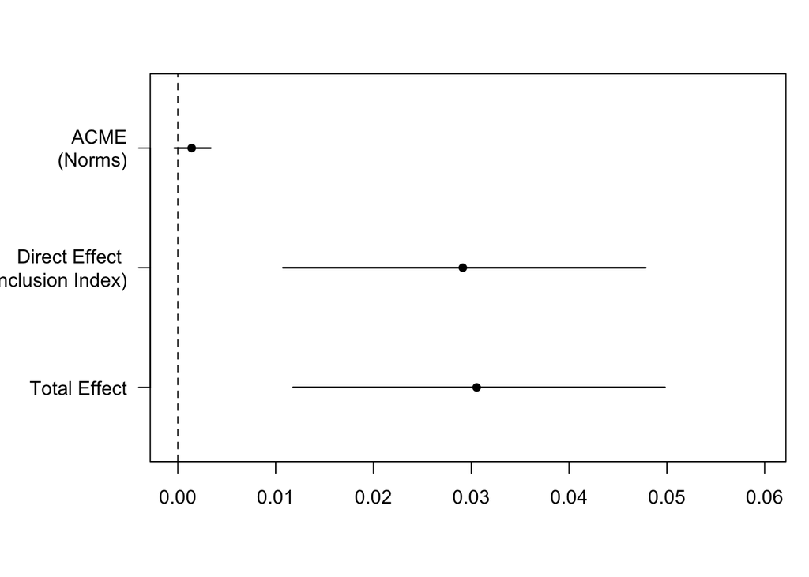

```r
par(mar=c(5,6.5,3.2,01))
plot(mediation_norms, labels=c("ACME\n(Norms)",
                            "Direct Effect \n(Behavioral Inclusion Index)", "Total Effect"))
```

```r
# save plot to PDF: Appendix Figure D.42
pdf(here::here("Figures/si_fig42_med_norms.pdf"), width = 7, height = 5)
par(mar = c(5, 6.5, 3.2, 0.1))
plot(mediation_norms, labels = c("ACME\n(Norms)",
                                 "Direct Effect \n(Behavioral Inclusion Index)",
                                 "Total Effect"))
dev.off()
```

```r
# plot(sens.out, sign.prod="positive", sens.par = "R2", r.type = c("residual"),
#      xlab="Proportion of Total Variance in M \nExplained by Confounder",
#      ylab="Proportion of Total Variance in Y \n Explained by Confounder", main="(a)")
#
# plot(sens.out, sign.prod="negative", sens.par = "R2", r.type = c("residual"),
#      xlab="Proportion of Total Variance in M \nExplained by Confounder",
#      ylab="Proportion of Total Variance in Y \n Explained by Confounder", main="(b)")

##happy
happy_med <- lm(Happy_index~PraiseControl,
                     data=data1White)

happy_out <- lm(behavioralindex~PraiseControl + Happy_index, data = data1White)

mediation_happy <- mediate(happy_med, happy_out, treat = "PraiseControl",
                                mediator = "Happy_index", dropobs=TRUE,
                                boot=TRUE, conf.level=.95)

sens.out <- medsens(mediation_happy, rho.by = 0.1, effect.type = "both")

summary(mediation_happy)
```

```
##
## Causal Mediation Analysis
##
## Nonparametric Bootstrap Confidence Intervals with the Percentile Method
##
##                 Estimate 95% CI Lower 95% CI Upper p-value
## ACME            0.000796    -0.003096         0.00   0.730
## ADE             0.029757     0.011191         0.05   0.002 **
## Total Effect    0.030553     0.012575         0.05   0.002 **
## Prop. Mediated  0.026066    -0.140949         0.16   0.728
## ---
## Signif. codes:  0 '***' 0.001 '**' 0.01 '*' 0.05 '.' 0.1 ' ' 1
##
## Sample Size Used: 4047
##
##
## Simulations: 1000
```

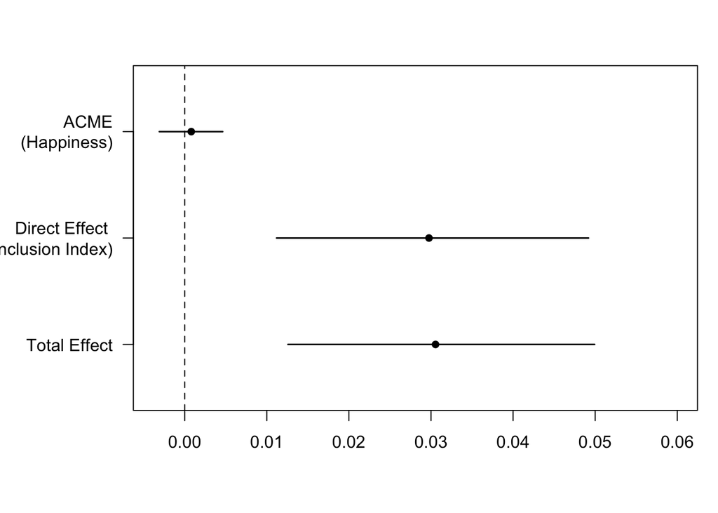

```r
par(mar=c(5,6.5,3.2,01))
plot(mediation_happy, labels=c("ACME\n(Happiness)",
                            "Direct Effect \n(Behavioral Inclusion Index)", "Total Effect"))
```

```r
# save plot to PDF: Appendix Figure D.43
pdf(here::here("Figures/si_fig43_med_happy.pdf"), width = 7, height = 5)
par(mar=c(5,6.5,3.2,01))
plot(mediation_happy, labels=c("ACME\n(Happiness)",
                            "Direct Effect \n(Behavioral Inclusion Index)", "Total Effect"))
dev.off()
```

```r
# plot(sens.out, sign.prod="positive", sens.par = "R2", r.type = c("residual"),
#      xlab="Proportion of Total Variance in M \nExplained by Confounder",
#      ylab="Proportion of Total Variance in Y \n Explained by Confounder", main="(a)")
#
# plot(sens.out, sign.prod="negative", sens.par = "R2", r.type = c("residual"),
#      xlab="Proportion of Total Variance in M \nExplained by Confounder",
#      ylab="Proportion of Total Variance in Y \n Explained by Confounder", main="(b)")
```

We do not find evidence for norms or elicited happiness serving as mediators for the (+) peer praise treatment effect on behavioral inclusion.

## 1.5 Figure 7 H1-H6

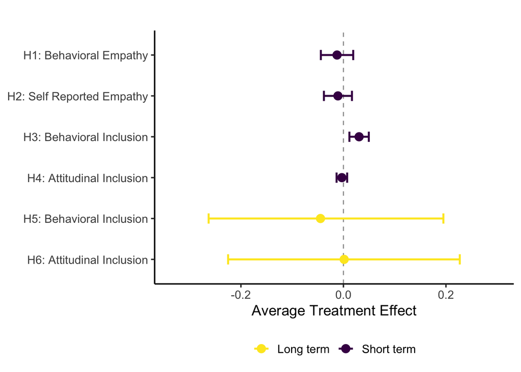

```r
# Define consistent colors (hex) — viridis-like palette adjusted:
cols <- viridis(n = 3,option="D")
models <- list(h1_model, h2_model, h3_model, h4_model,h5_model,h6_model)
# Extract PraiseControl coef and 95% CI for each model
coef_df <- lapply(seq_along(models), function(i) {
  m <- models[[i]]
  td <- broom::tidy(m, conf.int = TRUE, conf.level = 0.95)
  row <- td %>% filter(term == "PraiseControl")
  if (nrow(row) == 0) {
    stop(paste0("Coefficient 'PraiseControl' not found in model ", i))
  }
  data.frame(
    H = paste0("H", i),
    estimate = row$estimate,
    conf.low = row$conf.low,
    conf.high = row$conf.high,
    stringsAsFactors = FALSE
  )
}) %>% bind_rows()

# Override H5 confidence interval with Manski bound interval [-0.263, 0.195]
coef_df <- coef_df %>%
  mutate(
    conf.low = ifelse(H == "H5", -0.263, conf.low),
    conf.high = ifelse(H == "H5",  0.195, conf.high)
  )
# Override H6 confidence interval with Manski bound interval #ate_lower -0.224617 ate_upper 0.2265827
coef_df <- coef_df %>%
  mutate(
    conf.low = ifelse(H == "H6", -0.225, conf.low),
    conf.high = ifelse(H == "H6",  0.227, conf.high)
  )


# Replace H labels with full descriptive labels
label_map <- c(
  H1 = "H1: Behavioral Empathy",
  H2 = "H2: Self Reported Empathy",
  H3 = "H3: Behavioral Inclusion",
  H4 = "H4: Attitudinal Inclusion",
  H5 = "H5: Behavioral Inclusion",
  H6 = "H6: Attitudinal Inclusion"
)
coef_df <- coef_df %>%
  mutate(H_label = label_map[H])

# Order factor so H1 at top and H6 at bottom
coef_df$H_label <- factor(coef_df$H_label, levels = rev(unname(label_map)))

# Assign color group: H1-H4 = one color, H5-H6 = different color
coef_df <- coef_df %>%
  mutate(group = ifelse(H %in% c("H1","H2","H3","H4"), "short-term", "long-run"))

# Plot without numeric point estimate labels
p <- ggplot(coef_df, aes(x = estimate, y = H_label, color = group)) +
  geom_vline(xintercept = 0, linetype = "dashed", color = "gray60") +
  geom_errorbarh(aes(xmin = conf.low, xmax = conf.high), height = 0.25, size = 0.9) +
  geom_point(size = 3.5) +
  scale_color_manual(
    values = c("short-term" = "#440154FF", "long-run" = "#FDE725FF"),
    labels = c("short-term" = "Short term",
               "long-run"   = "Long term")
  )  +
  labs(x = "Average Treatment Effect", y = NULL,
       color = NULL,
       title = "") +
  theme_classic(base_size = 14) +
  theme(legend.position = "bottom",
        panel.grid.major.y = element_blank(),
        panel.grid.minor = element_blank())
# Expand x-axis a bit so error bars are not cut off
x_range <- range(coef_df$conf.low, coef_df$conf.high, coef_df$estimate)
xpad <- diff(x_range) * 0.15
p <- p + scale_x_continuous(limits = c(x_range[1] - xpad, x_range[2] + xpad), labels = comma)

# Print plot
print(p)
```

```r
ggsave(p,file=here::here("Figures","Fig7.pdf"),width=6,height=5)
```

Note H5 and H6 plots the Manski bounds on ATE.

## 1.6 Appendix Table Main Results H1-H6

```r
#use presult1 -- MH adjusted pvalues
models <- list(h1_model, h2_model, h3_model, h4_model, h5_model, h6_model)

# presult1 must be a data.frame with BH_adjusted_p in the same order as models
# Prepare BH-adjusted p-values from presult1 (must be same order as models)
adjp <- presult1$BH_adjusted_p

# Add a row with the BH-adjusted p-values (formatted)
add_line <- list(c("BH-adjusted p-value", formatC(adjp, format = "f", digits = 3)))
col.labels <- paste("H",1:6,sep="")


# Create the stargazer table and write to file
stargazer(
    models,
    type = "latex",
    out = "regression_table1.tex",
    title = "H1-H6 models",
    column.labels = col.labels,
    dep.var.labels.include = FALSE,
    covariate.labels = c("Intercept", "PeerPraise"),
    keep.stat = c("n", "rsq"),
    add.lines = add_line,
    digits = 2,
    single.row = TRUE,
    no.space = TRUE, notes=c("Manski ATE intervals: H5=[-0.263, 0.195]; H6=[-0.22, 0.22]")
)
```

[output not shown]

```r
#Table D.19 in Appendix
```

## 1.7 Robustness/Checks

### 1.7.1 Placebo analyses (alternative control condition)

“To ensure that the average treatment effect of peer praise is not driven by extraneous elements of the praise intervention—e.g., the colors of the text—our main study includes a placebo arm in which respondents also receive peer praise, but for “description” rather than empathy. If the elements of the treatment that matter for promoting empathy are only presentational, then “praise for description” should also cause a higher likelihood of choosing to engage in empathy in our choice task. ”

```r
#Placebo H1: DV is Behavioral Empathy
placebo_h1_model<-lm(empathytask~PraisePlacebo,data=data1White_BH)
summary(placebo_h1_model)
```

```
##
## Call:
## lm(formula = empathytask ~ PraisePlacebo, data = data1White_BH)
##
## Residuals:
##     Min      1Q  Median      3Q     Max
## -0.3655 -0.3610 -0.3610  0.6345  0.6390
##
## Coefficients:
##                Estimate Std. Error t value Pr(>|t|)
## (Intercept)    0.365510   0.015838  23.078   <2e-16 ***
## PraisePlacebo -0.004523   0.019506  -0.232    0.817
## ---
## Signif. codes:  0 '***' 0.001 '**' 0.01 '*' 0.05 '.' 0.1 ' ' 1
##
## Residual standard error: 0.4809 on 2704 degrees of freedom
##   (1810 observations deleted due to missingness)
## Multiple R-squared:  1.989e-05,  Adjusted R-squared:  -0.0003499
## F-statistic: 0.05377 on 1 and 2704 DF,  p-value: 0.8166
```

```r
#Placebo H2: DV is Self Reported Empathy
placebo_h2_model<-lm(post_empathyselfindex~PraisePlacebo,data=data1White)
summary(placebo_h2_model)
```

```
##
## Call:
## lm(formula = post_empathyselfindex ~ PraisePlacebo, data = data1White)
##
## Residuals:
##     Min      1Q  Median      3Q     Max
## -2.3819 -0.1319  0.1181  0.3681  0.6201
##
## Coefficients:
##                Estimate Std. Error t value Pr(>|t|)
## (Intercept)    2.381897   0.014148 168.356   <2e-16 ***
## PraisePlacebo -0.001967   0.017418  -0.113     0.91
## ---
## Signif. codes:  0 '***' 0.001 '**' 0.01 '*' 0.05 '.' 0.1 ' ' 1
##
## Residual standard error: 0.4547 on 3034 degrees of freedom
##   (2045 observations deleted due to missingness)
## Multiple R-squared:  4.204e-06,  Adjusted R-squared:  -0.0003254
## F-statistic: 0.01276 on 1 and 3034 DF,  p-value: 0.9101
```

```r
#Placebo H3: DV is Behavioral Inclusion
placebo_h3_model<-lm(behavioralindex~PraisePlacebo,data=data1White)
summary(placebo_h3_model)
```

```
##
## Call:
## lm(formula = behavioralindex ~ PraisePlacebo, data = data1White)
##
## Residuals:
##     Min      1Q  Median      3Q     Max
## -0.4269 -0.2269 -0.1016  0.3231  0.5985
##
## Coefficients:
##               Estimate Std. Error t value Pr(>|t|)
## (Intercept)   0.401549   0.009605   41.81   <2e-16 ***
## PraisePlacebo 0.025311   0.011825    2.14   0.0324 *
## ---
## Signif. codes:  0 '***' 0.001 '**' 0.01 '*' 0.05 '.' 0.1 ' ' 1
##
## Residual standard error: 0.3087 on 3034 degrees of freedom
##   (2045 observations deleted due to missingness)
## Multiple R-squared:  0.001508,   Adjusted R-squared:  0.001179
## F-statistic: 4.582 on 1 and 3034 DF,  p-value: 0.03239
```

```r
#Placebo H4: DV is Attitudinal Inclusion
placebo_h4_model<-lm(post_attitudinalindex~PraisePlacebo,data=data1White)
summary(placebo_h4_model) ##
```

```
##
## Call:
## lm(formula = post_attitudinalindex ~ PraisePlacebo, data = data1White)
##
## Residuals:
##      Min       1Q   Median       3Q      Max
## -1.36845 -0.08179  0.02717  0.09821  0.59550
##
## Coefficients:
##               Estimate Std. Error t value Pr(>|t|)
## (Intercept)   1.404500   0.005454 257.537   <2e-16 ***
## PraisePlacebo 0.013952   0.006714   2.078   0.0378 *
## ---
## Signif. codes:  0 '***' 0.001 '**' 0.01 '*' 0.05 '.' 0.1 ' ' 1
##
## Residual standard error: 0.1753 on 3034 degrees of freedom
##   (2045 observations deleted due to missingness)
## Multiple R-squared:  0.001421,   Adjusted R-squared:  0.001092
## F-statistic: 4.318 on 1 and 3034 DF,  p-value: 0.03779
```

```r
  #Robustness check
placebo_h4_model_robustnesscheck<-lm(post_attitudinalindex~PraisePlacebo*pre_attitudinalindex,data=data1White)
summary(placebo_h4_model_robustnesscheck)
```

```
##
## Call:
## lm(formula = post_attitudinalindex ~ PraisePlacebo * pre_attitudinalindex,
##     data = data1White)
##
## Residuals:
##      Min       1Q   Median       3Q      Max
## -0.89276 -0.04779  0.00074  0.05361  0.65848
##
## Coefficients:
##                                    Estimate Std. Error t value Pr(>|t|)
## (Intercept)                         0.30473    0.02513  12.127   <2e-16 ***
## PraisePlacebo                      -0.05626    0.03174  -1.772   0.0765 .
## pre_attitudinalindex                0.78283    0.01774  44.130   <2e-16 ***
## PraisePlacebo:pre_attitudinalindex  0.04161    0.02233   1.863   0.0625 .
## ---
## Signif. codes:  0 '***' 0.001 '**' 0.01 '*' 0.05 '.' 0.1 ' ' 1
##
## Residual standard error: 0.1037 on 3032 degrees of freedom
##   (2045 observations deleted due to missingness)
## Multiple R-squared:  0.6508, Adjusted R-squared:  0.6505
## F-statistic:  1884 on 3 and 3032 DF,  p-value: < 2.2e-16
```

```r
#Placebo H5: Long-run behavioral inclusion
placebo_h5_model<-lm(empathytask~PraisePlacebo,data=data2White_BH)
summary(placebo_h5_model)
```

```
##
## Call:
## lm(formula = empathytask ~ PraisePlacebo, data = data2White_BH)
##
## Residuals:
##     Min      1Q  Median      3Q     Max
## -0.3082 -0.3030 -0.3030  0.6918  0.6970
##
## Coefficients:
##                Estimate Std. Error t value Pr(>|t|)
## (Intercept)    0.308219   0.017045  18.082   <2e-16 ***
## PraisePlacebo -0.005189   0.021061  -0.246    0.805
## ---
## Signif. codes:  0 '***' 0.001 '**' 0.01 '*' 0.05 '.' 0.1 ' ' 1
##
## Residual standard error: 0.4605 on 2114 degrees of freedom
##   (1409 observations deleted due to missingness)
## Multiple R-squared:  2.871e-05,  Adjusted R-squared:  -0.0004443
## F-statistic: 0.0607 on 1 and 2114 DF,  p-value: 0.8054
```

```r
#Placebo H6: Long-run attitudinal inclusion
placebo_h6_model<-lm(post_attitudinalindex~PraisePlacebo,data=data2White)
summary(placebo_h6_model)
```

```
##
## Call:
## lm(formula = post_attitudinalindex ~ PraisePlacebo, data = data2White)
##
## Residuals:
##      Min       1Q   Median       3Q      Max
## -1.37425 -0.08092  0.03665  0.10665  0.59498
##
## Coefficients:
##               Estimate Std. Error t value Pr(>|t|)
## (Intercept)   1.405019   0.006168 227.777   <2e-16 ***
## PraisePlacebo 0.009236   0.007611   1.214    0.225
## ---
## Signif. codes:  0 '***' 0.001 '**' 0.01 '*' 0.05 '.' 0.1 ' ' 1
##
## Residual standard error: 0.1756 on 2359 degrees of freedom
##   (1586 observations deleted due to missingness)
## Multiple R-squared:  0.0006239,  Adjusted R-squared:  0.0002003
## F-statistic: 1.473 on 1 and 2359 DF,  p-value: 0.225
```

```r
  #Robustness check
placebo_h6_model_robustnesscheck<-lm(post_attitudinalindex~PraisePlacebo*pre_attitudinalindex,data=data2White)
summary(placebo_h6_model_robustnesscheck)
```

```
##
## Call:
## lm(formula = post_attitudinalindex ~ PraisePlacebo * pre_attitudinalindex,
##     data = data2White)
##
## Residuals:
##      Min       1Q   Median       3Q      Max
## -0.93957 -0.07295  0.01468  0.08035  0.51385
##
## Coefficients:
##                                    Estimate Std. Error t value Pr(>|t|)
## (Intercept)                         0.68084    0.03921  17.366   <2e-16 ***
## PraisePlacebo                      -0.10453    0.05046  -2.071   0.0384 *
## pre_attitudinalindex                0.51675    0.02773  18.632   <2e-16 ***
## PraisePlacebo:pre_attitudinalindex  0.07470    0.03557   2.100   0.0358 *
## ---
## Signif. codes:  0 '***' 0.001 '**' 0.01 '*' 0.05 '.' 0.1 ' ' 1
##
## Residual standard error: 0.146 on 2357 degrees of freedom
##   (1586 observations deleted due to missingness)
## Multiple R-squared:  0.3091, Adjusted R-squared:  0.3082
## F-statistic: 351.5 on 3 and 2357 DF,  p-value: < 2.2e-16
```

### 1.7.2 Other emotions

Exploratory analysis of emotional mechanisms for H3, for which we find MH-adjusted effects of peer praise: we both measure respondents’ level of anxiety and anger.

- anxiety
- anger

H3 Mediation

```r
set.seed(123)
#H3: Behavioral Inclusion: h3_model<-lm(behavioralindex~PraiseControl,data=data1White)

##anxiety
anxiety_med <- lm(anxiety_index~PraiseControl,data=data1White)

anxiety_out <- lm(behavioralindex~PraiseControl + anxiety_index, data = data1White)

mediation_anxiety <- mediate(anxiety_med, anxiety_out, treat = "PraiseControl",
                                mediator = "anxiety_index", dropobs=TRUE,
                                boot=TRUE, conf.level=.95)

sens.out_anxiety <- medsens(mediation_anxiety, rho.by = 0.1, effect.type = "both")

summary(mediation_anxiety) #ACME            0.01875      0.01003         0.03  <2e-16 ***
```

```
##
## Causal Mediation Analysis
##
## Nonparametric Bootstrap Confidence Intervals with the Percentile Method
##
##                Estimate 95% CI Lower 95% CI Upper p-value
## ACME            0.01875      0.01003         0.03  <2e-16 ***
## ADE             0.01180     -0.00505         0.03   0.162
## Total Effect    0.03055      0.01179         0.05   0.002 **
## Prop. Mediated  0.61371      0.33536         1.34   0.002 **
## ---
## Signif. codes:  0 '***' 0.001 '**' 0.01 '*' 0.05 '.' 0.1 ' ' 1
##
## Sample Size Used: 4047
##
##
## Simulations: 1000
```

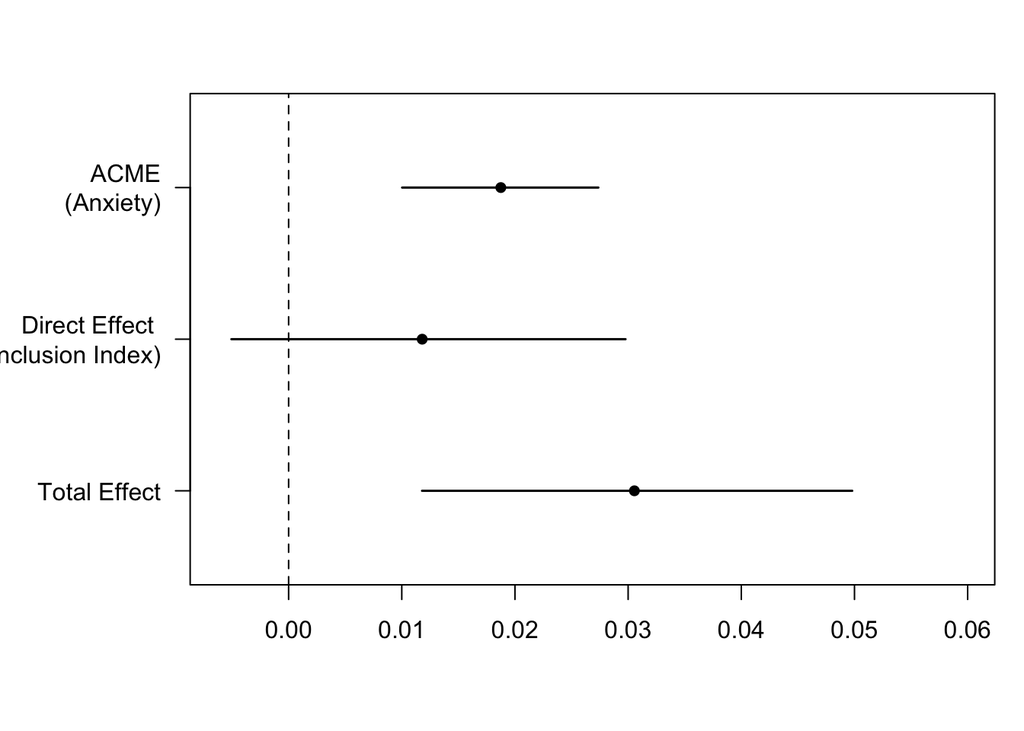

```r
par(mar=c(5,6.5,3.2,01))
plot(mediation_anxiety, labels=c("ACME\n(Anxiety)",
                            "Direct Effect \n(Behavioral Inclusion Index)", "Total Effect"))
```

```r
# save plot to PDF: Appendix Figure D.44
pdf(here::here("Figures/si_fig44_med_anxiety.pdf"), width = 7, height = 5)
par(mar=c(5,6.5,3.2,01))
plot(mediation_anxiety, labels=c("ACME\n(Anxiety)",
                            "Direct Effect \n(Behavioral Inclusion Index)", "Total Effect"))
dev.off()
```

```r
# uncomment if you want the sensitivity plots
#plot(sens.out_anxiety, sign.prod="positive", sens.par = "R2", r.type = c("residual"),
     #xlab="Proportion of Total Variance in M \nExplained by Confounder",
     #ylab="Proportion of Total Variance in Y \n Explained by Confounder", main="(a)")

#plot(sens.out_anxiety, sign.prod="negative", sens.par = "R2", r.type = c("residual"),
     #xlab="Proportion of Total Variance in M \nExplained by Confounder",
     #ylab="Proportion of Total Variance in Y \n Explained by Confounder", main="(b)")

##anger
anger_med <- lm(anger_index~PraiseControl,
                     data=data1White)

anger_out <- lm(behavioralindex~PraiseControl + anger_index, data = data1White)

mediation_anger <- mediate(anger_med, anger_out, treat = "PraiseControl",
                                mediator = "anger_index", dropobs=TRUE,
                                boot=TRUE, conf.level=.95)

sens.out_anger <- medsens(mediation_anger, rho.by = 0.1, effect.type = "both")

summary(mediation_anger)#0.01176      0.00355         0.02   0.012 *
```

```
##
## Causal Mediation Analysis
##
## Nonparametric Bootstrap Confidence Intervals with the Percentile Method
##
##                Estimate 95% CI Lower 95% CI Upper p-value
## ACME            0.01176      0.00355         0.02   0.012 *
## ADE             0.01876      0.00179         0.04   0.038 *
## Total Effect    0.03052      0.01181         0.05  <2e-16 ***
## Prop. Mediated  0.38540      0.14041         0.90   0.012 *
## ---
## Signif. codes:  0 '***' 0.001 '**' 0.01 '*' 0.05 '.' 0.1 ' ' 1
##
## Sample Size Used: 4042
##
##
## Simulations: 1000
```

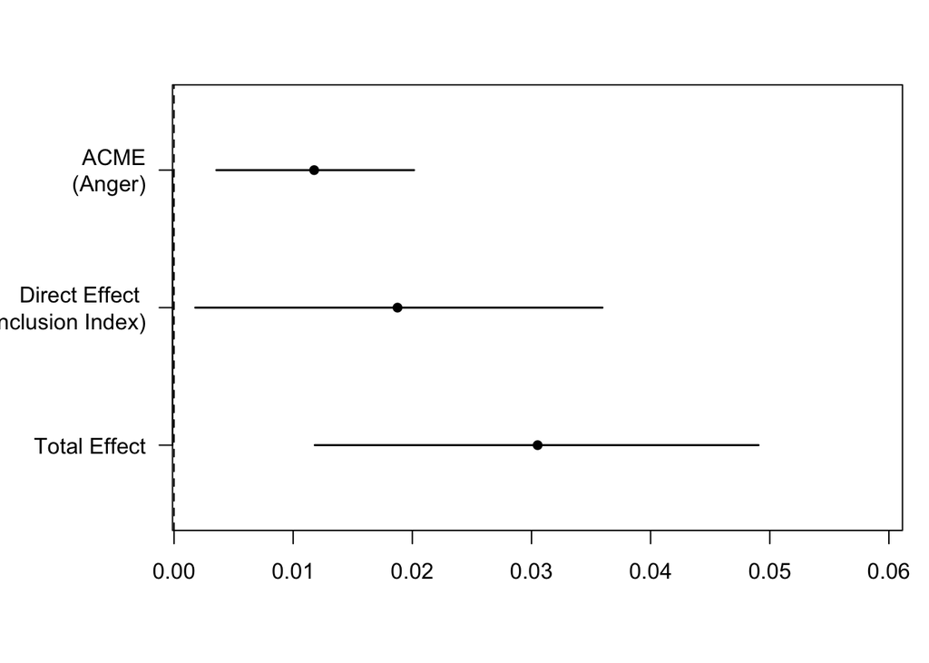

```r
par(mar=c(5,6.5,3.2,01))
plot(mediation_anger, labels=c("ACME\n(Anger)",
                            "Direct Effect \n(Behavioral Inclusion Index)", "Total Effect"))
```

```r
# save plot to PDF: Appendix Figure D.45
pdf(here::here("Figures/si_fig45_med_anger.pdf"), width = 7, height = 5)
par(mar=c(5,6.5,3.2,01))
plot(mediation_anger, labels=c("ACME\n(Anger)",
                            "Direct Effect \n(Behavioral Inclusion Index)", "Total Effect"))
dev.off()
```

```r
## uncomment if you want the sensitivity plots
#plot(sens.out_anger, sign.prod="positive", sens.par = "R2", r.type = c("residual"),
     #xlab="Proportion of Total Variance in M \nExplained by Confounder",
     #ylab="Proportion of Total Variance in Y \n Explained by Confounder", main="(a)")

#plot(sens.out_anger, sign.prod="negative", sens.par = "R2", r.type = c("residual"),
     #xlab="Proportion of Total Variance in M \nExplained by Confounder",
     #ylab="Proportion of Total Variance in Y \n Explained by Confounder", main="(b)")
```

We find exploratory evidence for anxiety/anger serving as mediators for the (+) peer praise treatment effect on behavioral inclusion.

### 1.7.3 Other HTEs

#### 1.7.3.1 Respondent Gender

Are there heterogeneous treatment effects by gender?

```r
#H1: DV is Behavioral Empathy
check2_1<-lm(empathytask~PraiseControl*sex,data=data1White_BH)
summary(check2_1)
```

```
##
## Call:
## lm(formula = empathytask ~ PraiseControl * sex, data = data1White_BH)
##
## Residuals:
##     Min      1Q  Median      3Q     Max
## -0.6522 -0.4062 -0.3099  0.5793  0.6901
##
## Coefficients:
##                             Estimate Std. Error t value Pr(>|t|)
## (Intercept)                  0.42071    0.01734  24.255  < 2e-16 ***
## PraiseControl                0.00319    0.02505   0.127 0.898669
## sexMale                     -0.08973    0.02308  -3.888 0.000103 ***
## sexNon-binary                0.01172    0.08065   0.145 0.884425
## sexOther                     0.15824    0.11128   1.422 0.155099
## PraiseControl:sexMale       -0.02423    0.03290  -0.736 0.461611
## PraiseControl:sexNon-binary  0.21655    0.12966   1.670 0.094977 .
## PraiseControl:sexOther      -0.17589    0.14100  -1.247 0.212336
## ---
## Signif. codes:  0 '***' 0.001 '**' 0.01 '*' 0.05 '.' 0.1 ' ' 1
##
## Residual standard error: 0.4791 on 3586 degrees of freedom
##   (922 observations deleted due to missingness)
## Multiple R-squared:  0.01441,    Adjusted R-squared:  0.01249
## F-statistic: 7.489 on 7 and 3586 DF,  p-value: 5.623e-09
```

```r
#H2: DV is Self Reported Empathy
check2_2<-lm(post_empathyselfindex~PraiseControl*sex,data=data1White)
summary(check2_2)
```

```
##
## Call:
## lm(formula = post_empathyselfindex ~ PraiseControl * sex, data = data1White)
##
## Residuals:
##      Min       1Q   Median       3Q      Max
## -2.33415 -0.20099  0.05964  0.30964  0.67674
##
## Coefficients:
##                               Estimate Std. Error t value Pr(>|t|)
## (Intercept)                  2.4509918  0.0149808 163.609  < 2e-16 ***
## PraiseControl               -0.0106365  0.0216449  -0.491   0.6232
## sexMale                     -0.1168444  0.0198805  -5.877 4.51e-09 ***
## sexNon-binary                0.1323415  0.0718053   1.843   0.0654 .
## sexOther                     0.1399173  0.0946931   1.478   0.1396
## PraiseControl:sexMale       -0.0002501  0.0283999  -0.009   0.9930
## PraiseControl:sexNon-binary  0.0790889  0.1107658   0.714   0.4753
## PraiseControl:sexOther       0.0683761  0.1200375   0.570   0.5690
## ---
## Signif. codes:  0 '***' 0.001 '**' 0.01 '*' 0.05 '.' 0.1 ' ' 1
##
## Residual standard error: 0.4386 on 4039 degrees of freedom
##   (1034 observations deleted due to missingness)
## Multiple R-squared:  0.02568,    Adjusted R-squared:  0.02399
## F-statistic: 15.21 on 7 and 4039 DF,  p-value: < 2.2e-16
```

```r
#H3: Behavioral Inclusion
check2_3<-lm(behavioralindex~PraiseControl*sex,data=data1White)
summary(check2_3)
```

```
##
## Call:
## lm(formula = behavioralindex ~ PraiseControl * sex, data = data1White)
##
## Residuals:
##      Min       1Q   Median       3Q      Max
## -0.46978 -0.23147 -0.08147  0.28022  0.77051
##
## Coefficients:
##                              Estimate Std. Error t value Pr(>|t|)
## (Intercept)                  0.348775   0.010317  33.805  < 2e-16 ***
## PraiseControl                0.032697   0.014907   2.193   0.0283 *
## sexMale                      0.093588   0.013692   6.835  9.4e-12 ***
## sexNon-binary               -0.119288   0.049452  -2.412   0.0159 *
## sexOther                    -0.162411   0.065214  -2.490   0.0128 *
## PraiseControl:sexMale       -0.005277   0.019559  -0.270   0.7873
## PraiseControl:sexNon-binary -0.033613   0.076284  -0.441   0.6595
## PraiseControl:sexOther      -0.009601   0.082669  -0.116   0.9075
## ---
## Signif. codes:  0 '***' 0.001 '**' 0.01 '*' 0.05 '.' 0.1 ' ' 1
##
## Residual standard error: 0.302 on 4039 degrees of freedom
##   (1034 observations deleted due to missingness)
## Multiple R-squared:  0.03639,    Adjusted R-squared:  0.03472
## F-statistic: 21.79 on 7 and 4039 DF,  p-value: < 2.2e-16
```

```r
#H4: DV is Attitudinal Inclusion
check2_4<-lm(post_attitudinalindex~PraiseControl*sex,data=data1White)
summary(check2_4)
```

```
##
## Call:
## lm(formula = post_attitudinalindex ~ PraiseControl * sex, data = data1White)
##
## Residuals:
##      Min       1Q   Median       3Q      Max
## -1.34738 -0.07837  0.01947  0.09663  0.60262
##
## Coefficients:
##                               Estimate Std. Error t value Pr(>|t|)
## (Intercept)                  1.4471937  0.0056795 254.810  < 2e-16 ***
## PraiseControl               -0.0021577  0.0082060  -0.263    0.793
## sexMale                     -0.0469983  0.0075371  -6.236 4.96e-10 ***
## sexNon-binary                0.0174217  0.0272227   0.640    0.522
## sexOther                    -0.0123452  0.0358999  -0.344    0.731
## PraiseControl:sexMale       -0.0006565  0.0107669  -0.061    0.951
## PraiseControl:sexNon-binary -0.0118624  0.0419934  -0.282    0.778
## PraiseControl:sexOther       0.0501921  0.0455084   1.103    0.270
## ---
## Signif. codes:  0 '***' 0.001 '**' 0.01 '*' 0.05 '.' 0.1 ' ' 1
##
## Residual standard error: 0.1663 on 4039 degrees of freedom
##   (1034 observations deleted due to missingness)
## Multiple R-squared:  0.02115,    Adjusted R-squared:  0.01945
## F-statistic: 12.47 on 7 and 4039 DF,  p-value: 6.775e-16
```

```r
#H5:DV is Long-run behavioral inclusion
check2_5<-lm(empathytask~PraiseControl*sex,data=data2White_BH)
summary(check2_5)
```

```
##
## Call:
## lm(formula = empathytask ~ PraiseControl * sex, data = data2White_BH)
##
## Residuals:
##     Min      1Q  Median      3Q     Max
## -0.4286 -0.3912 -0.2360  0.5880  0.7640
##
## Coefficients:
##                             Estimate Std. Error t value Pr(>|t|)
## (Intercept)                  0.41195    0.01838  22.408  < 2e-16 ***
## PraiseControl               -0.02079    0.02652  -0.784    0.433
## sexMale                     -0.11585    0.02484  -4.663 3.26e-06 ***
## sexNon-binary               -0.41195    0.46399  -0.888    0.375
## sexOther                    -0.41195    0.32835  -1.255    0.210
## PraiseControl:sexMale       -0.03927    0.03543  -1.108    0.268
## PraiseControl:sexNon-binary  0.44936    0.49635   0.905    0.365
## PraiseControl:sexOther       0.35413    0.42406   0.835    0.404
## ---
## Signif. codes:  0 '***' 0.001 '**' 0.01 '*' 0.05 '.' 0.1 ' ' 1
##
## Residual standard error: 0.4636 on 2787 degrees of freedom
##   (730 observations deleted due to missingness)
## Multiple R-squared:  0.02387,    Adjusted R-squared:  0.02142
## F-statistic: 9.738 on 7 and 2787 DF,  p-value: 4.935e-12
```

```r
#H6:DV is Long-run attitudinal inclusion
check2_6<-lm(post_attitudinalindex~PraiseControl*sex,data=data2White)
summary(check2_6)
```

```
##
## Call:
## lm(formula = post_attitudinalindex ~ PraiseControl * sex, data = data2White)
##
## Residuals:
##      Min       1Q   Median       3Q      Max
## -1.35196 -0.07798  0.02479  0.10479  0.60804
##
## Coefficients:
##                              Estimate Std. Error t value Pr(>|t|)
## (Intercept)                  1.441872   0.006200 232.563  < 2e-16 ***
## PraiseControl                0.002773   0.008954   0.310    0.757
## sexMale                     -0.053784   0.008425  -6.384 1.98e-10 ***
## sexNon-binary               -0.016872   0.096448  -0.175    0.861
## sexOther                     0.008128   0.096448   0.084    0.933
## PraiseControl:sexMale        0.001102   0.012020   0.092    0.927
## PraiseControl:sexNon-binary -0.114678   0.115387  -0.994    0.320
## PraiseControl:sexOther      -0.047217   0.136410  -0.346    0.729
## ---
## Signif. codes:  0 '***' 0.001 '**' 0.01 '*' 0.05 '.' 0.1 ' ' 1
##
## Residual standard error: 0.1667 on 3126 degrees of freedom
##   (813 observations deleted due to missingness)
## Multiple R-squared:  0.02536,    Adjusted R-squared:  0.02318
## F-statistic: 11.62 on 7 and 3126 DF,  p-value: 1.161e-14
```

No evidence to support gender HTEs.

#### 1.7.3.2 Respondent Age

Are there heterogeneous treatment effects by age?

```r
#H1: DV is Behavioral Empathy
check3_1<-lm(empathytask~PraiseControl*age,data=data1White_BH)
summary(check3_1)
```

```
##
## Call:
## lm(formula = empathytask ~ PraiseControl * age, data = data1White_BH)
##
## Residuals:
##     Min      1Q  Median      3Q     Max
## -0.3977 -0.3723 -0.3570  0.6231  0.7156
##
## Coefficients:
##                     Estimate Std. Error t value Pr(>|t|)
## (Intercept)        0.4508706  0.0604385   7.460 1.08e-13 ***
## PraiseControl     -0.0002319  0.0856927  -0.003    0.998
## age               -0.0023116  0.0017733  -1.304    0.192
## PraiseControl:age -0.0003640  0.0025130  -0.145    0.885
## ---
## Signif. codes:  0 '***' 0.001 '**' 0.01 '*' 0.05 '.' 0.1 ' ' 1
##
## Residual standard error: 0.482 on 3590 degrees of freedom
##   (922 observations deleted due to missingness)
## Multiple R-squared:  0.001269,   Adjusted R-squared:  0.0004341
## F-statistic:  1.52 on 3 and 3590 DF,  p-value: 0.2071
```

```r
#H2: DV is Self Reported Empathy
check3_2<-lm(post_empathyselfindex~PraiseControl*age,data=data1White)
summary(check3_2)
```

```
##
## Call:
## lm(formula = post_empathyselfindex ~ PraiseControl * age, data = data1White)
##
## Residuals:
##     Min      1Q  Median      3Q     Max
## -2.3953 -0.1527  0.1034  0.3534  0.7393
##
## Coefficients:
##                     Estimate Std. Error t value Pr(>|t|)
## (Intercept)        2.494e+00  5.274e-02  47.289   <2e-16 ***
## PraiseControl     -1.265e-02  7.465e-02  -0.169   0.8655
## age               -3.080e-03  1.546e-03  -1.992   0.0464 *
## PraiseControl:age  5.964e-05  2.188e-03   0.027   0.9783
## ---
## Signif. codes:  0 '***' 0.001 '**' 0.01 '*' 0.05 '.' 0.1 ' ' 1
##
## Residual standard error: 0.4436 on 4043 degrees of freedom
##   (1034 observations deleted due to missingness)
## Multiple R-squared:  0.002066,   Adjusted R-squared:  0.001325
## F-statistic:  2.79 on 3 and 4043 DF,  p-value: 0.03909
```

```r
#H3: Behavioral Inclusion
check3_3<-lm(behavioralindex~PraiseControl*age,data=data1White)
summary(check3_3)
```

```
##
## Call:
## lm(formula = behavioralindex ~ PraiseControl * age, data = data1White)
##
## Residuals:
##     Min      1Q  Median      3Q     Max
## -0.4375 -0.2350 -0.1076  0.3187  0.6321
##
## Coefficients:
##                     Estimate Std. Error t value Pr(>|t|)
## (Intercept)        4.406e-01  3.650e-02  12.071   <2e-16 ***
## PraiseControl      2.816e-02  5.166e-02   0.545    0.586
## age               -1.322e-03  1.070e-03  -1.235    0.217
## PraiseControl:age  7.223e-05  1.514e-03   0.048    0.962
## ---
## Signif. codes:  0 '***' 0.001 '**' 0.01 '*' 0.05 '.' 0.1 ' ' 1
##
## Residual standard error: 0.307 on 4043 degrees of freedom
##   (1034 observations deleted due to missingness)
## Multiple R-squared:  0.003182,   Adjusted R-squared:  0.002442
## F-statistic: 4.302 on 3 and 4043 DF,  p-value: 0.004888
```

```r
#H4: DV is Attitudinal Inclusion
check3_4<-lm(post_attitudinalindex~PraiseControl*age,data=data1White)
summary(check3_4)
```

```
##
## Call:
## lm(formula = post_attitudinalindex ~ PraiseControl * age, data = data1White)
##
## Residuals:
##      Min       1Q   Median       3Q      Max
## -1.36608 -0.07213  0.02793  0.09793  0.60255
##
## Coefficients:
##                     Estimate Std. Error t value Pr(>|t|)
## (Intercept)        1.4795404  0.0199434  74.187  < 2e-16 ***
## PraiseControl     -0.0432445  0.0282286  -1.532  0.12561
## age               -0.0017321  0.0005848  -2.962  0.00308 **
## PraiseControl:age  0.0011999  0.0008273   1.450  0.14701
## ---
## Signif. codes:  0 '***' 0.001 '**' 0.01 '*' 0.05 '.' 0.1 ' ' 1
##
## Residual standard error: 0.1678 on 4043 degrees of freedom
##   (1034 observations deleted due to missingness)
## Multiple R-squared:  0.002451,   Adjusted R-squared:  0.001711
## F-statistic: 3.311 on 3 and 4043 DF,  p-value: 0.01923
```

```r
#H5:DV is Long-run behavioral inclusion
check3_5<-lm(empathytask~PraiseControl*age,data=data2White_BH)
summary(check3_5)
```

```
##
## Call:
## lm(formula = empathytask ~ PraiseControl * age, data = data2White_BH)
##
## Residuals:
##     Min      1Q  Median      3Q     Max
## -0.3522 -0.3467 -0.3037  0.6516  0.7405
##
## Coefficients:
##                     Estimate Std. Error t value Pr(>|t|)
## (Intercept)        0.3621011  0.0681431   5.314 1.16e-07 ***
## PraiseControl     -0.0210494  0.0949463  -0.222    0.825
## age               -0.0004286  0.0020028  -0.214    0.831
## PraiseControl:age -0.0007045  0.0027845  -0.253    0.800
## ---
## Signif. codes:  0 '***' 0.001 '**' 0.01 '*' 0.05 '.' 0.1 ' ' 1
##
## Residual standard error: 0.4684 on 2791 degrees of freedom
##   (730 observations deleted due to missingness)
## Multiple R-squared:  0.002417,   Adjusted R-squared:  0.001345
## F-statistic: 2.254 on 3 and 2791 DF,  p-value: 0.0801
```

```r
#H6:DV is Long-run attitudinal inclusion
check3_6<-lm(post_attitudinalindex~PraiseControl*age,data=data2White)
summary(check3_6)
```

```
##
## Call:
## lm(formula = post_attitudinalindex ~ PraiseControl * age, data = data2White)
##
## Residuals:
##      Min       1Q   Median       3Q      Max
## -1.37151 -0.07256  0.03801  0.10324  0.60014
##
## Coefficients:
##                     Estimate Std. Error t value Pr(>|t|)
## (Intercept)        1.4648986  0.0227415  64.415   <2e-16 ***
## PraiseControl     -0.0300862  0.0320461  -0.939   0.3479
## age               -0.0015527  0.0006664  -2.330   0.0199 *
## PraiseControl:age  0.0009395  0.0009388   1.001   0.3170
## ---
## Signif. codes:  0 '***' 0.001 '**' 0.01 '*' 0.05 '.' 0.1 ' ' 1
##
## Residual standard error: 0.1686 on 3130 degrees of freedom
##   (813 observations deleted due to missingness)
## Multiple R-squared:  0.002023,   Adjusted R-squared:  0.001066
## F-statistic: 2.115 on 3 and 3130 DF,  p-value: 0.09626
```

No evidence to support age HTEs.

#### 1.7.3.3 Respondent Education

Are there heterogeneous treatment effects by education?

```r
#H1: DV is Behavioral Empathy
check4_1<-lm(empathytask~PraiseControl*education_level,data=data1White_BH)
summary(check4_1)
```

```
##
## Call:
## lm(formula = empathytask ~ PraiseControl * education_level, data = data1White_BH)
##
## Residuals:
##     Min      1Q  Median      3Q     Max
## -0.4112 -0.3568 -0.3431  0.6015  0.6905
##
## Coefficients:
##                                     Estimate Std. Error t value Pr(>|t|)
## (Intercept)                          0.30952    0.07431   4.165 3.18e-05 ***
## PraiseControl                        0.04531    0.11403   0.397    0.691
## education_levelMedium                0.04732    0.07561   0.626    0.531
## education_levelHigh                  0.10171    0.07708   1.319    0.187
## PraiseControl:education_levelMedium -0.05908    0.11575  -0.510    0.610
## PraiseControl:education_levelHigh   -0.05800    0.11766  -0.493    0.622
## ---
## Signif. codes:  0 '***' 0.001 '**' 0.01 '*' 0.05 '.' 0.1 ' ' 1
##
## Residual standard error: 0.4816 on 3525 degrees of freedom
##   (985 observations deleted due to missingness)
## Multiple R-squared:  0.003123,   Adjusted R-squared:  0.001709
## F-statistic: 2.209 on 5 and 3525 DF,  p-value: 0.05078
```

```r
#H2: DV is Self Reported Empathy
check4_2<-lm(post_empathyselfindex~PraiseControl*education_level,data=data1White)
summary(check4_2)
```

```
##
## Call:
## lm(formula = post_empathyselfindex ~ PraiseControl * education_level,
##     data = data1White)
##
## Residuals:
##     Min      1Q  Median      3Q     Max
## -2.4730 -0.1958  0.1258  0.3042  1.0530
##
## Coefficients:
##                                     Estimate Std. Error t value Pr(>|t|)
## (Intercept)                          1.93617    0.06333  30.574  < 2e-16 ***
## PraiseControl                        0.01080    0.09860   0.110    0.913
## education_levelMedium                0.43798    0.06444   6.797 1.23e-11 ***
## education_levelHigh                  0.53683    0.06562   8.182 3.74e-16 ***
## PraiseControl:education_levelMedium -0.02099    0.10004  -0.210    0.834
## PraiseControl:education_levelHigh   -0.03805    0.10161  -0.374    0.708
## ---
## Signif. codes:  0 '***' 0.001 '**' 0.01 '*' 0.05 '.' 0.1 ' ' 1
##
## Residual standard error: 0.4342 on 3967 degrees of freedom
##   (1108 observations deleted due to missingness)
## Multiple R-squared:  0.0307, Adjusted R-squared:  0.02948
## F-statistic: 25.13 on 5 and 3967 DF,  p-value: < 2.2e-16
```

```r
#H3: Behavioral Inclusion
check4_3<-lm(behavioralindex~PraiseControl*education_level,data=data1White)
summary(check4_3)
```

```
##
## Call:
## lm(formula = behavioralindex ~ PraiseControl * education_level,
##     data = data1White)
##
## Residuals:
##     Min      1Q  Median      3Q     Max
## -0.6091 -0.2164 -0.1110  0.3043  0.6390
##
## Coefficients:
##                                     Estimate Std. Error t value Pr(>|t|)
## (Intercept)                          0.45213    0.04445  10.171   <2e-16 ***
## PraiseControl                        0.15696    0.06922   2.268   0.0234 *
## education_levelMedium               -0.03570    0.04524  -0.789   0.4300
## education_levelHigh                 -0.09109    0.04606  -1.978   0.0480 *
## PraiseControl:education_levelMedium -0.12769    0.07022  -1.818   0.0691 .
## PraiseControl:education_levelHigh   -0.12803    0.07133  -1.795   0.0727 .
## ---
## Signif. codes:  0 '***' 0.001 '**' 0.01 '*' 0.05 '.' 0.1 ' ' 1
##
## Residual standard error: 0.3048 on 3967 degrees of freedom
##   (1108 observations deleted due to missingness)
## Multiple R-squared:  0.01284,    Adjusted R-squared:  0.0116
## F-statistic: 10.32 on 5 and 3967 DF,  p-value: 7.499e-10
```

```r
#H4: DV is Attitudinal Inclusion
check4_4<-lm(post_attitudinalindex~PraiseControl*education_level,data=data1White)
summary(check4_4)
```

```
##
## Call:
## lm(formula = post_attitudinalindex ~ PraiseControl * education_level,
##     data = data1White)
##
## Residuals:
##      Min       1Q   Median       3Q      Max
## -1.37326 -0.07069  0.02530  0.09840  0.61586
##
## Coefficients:
##                                      Estimate Std. Error t value Pr(>|t|)
## (Intercept)                          1.410496   0.024366  57.889   <2e-16 ***
## PraiseControl                       -0.026355   0.037937  -0.695    0.487
## education_levelMedium                0.015870   0.024793   0.640    0.522
## education_levelHigh                  0.001856   0.025246   0.074    0.941
## PraiseControl:education_levelMedium  0.023252   0.038490   0.604    0.546
## PraiseControl:education_levelHigh    0.022504   0.039095   0.576    0.565
## ---
## Signif. codes:  0 '***' 0.001 '**' 0.01 '*' 0.05 '.' 0.1 ' ' 1
##
## Residual standard error: 0.167 on 3967 degrees of freedom
##   (1108 observations deleted due to missingness)
## Multiple R-squared:  0.002098,   Adjusted R-squared:  0.0008401
## F-statistic: 1.668 on 5 and 3967 DF,  p-value: 0.1388
```

```r
#H5:DV is Long-run behavioral inclusion
check4_5<-lm(empathytask~PraiseControl*education_level,data=data2White_BH)
summary(check4_5)
```

```
##
## Call:
## lm(formula = empathytask ~ PraiseControl * education_level, data = data2White_BH)
##
## Residuals:
##     Min      1Q  Median      3Q     Max
## -0.4005 -0.3390 -0.2857  0.6305  0.9630
##
## Coefficients:
##                                      Estimate Std. Error t value Pr(>|t|)
## (Intercept)                          0.060606   0.081223   0.746 0.455627
## PraiseControl                       -0.023569   0.121079  -0.195 0.845676
## education_levelMedium                0.278431   0.082643   3.369 0.000765 ***
## education_levelHigh                  0.339874   0.084375   4.028 5.78e-05 ***
## PraiseControl:education_levelMedium -0.029754   0.122999  -0.242 0.808871
## PraiseControl:education_levelHigh   -0.007452   0.125374  -0.059 0.952604
## ---
## Signif. codes:  0 '***' 0.001 '**' 0.01 '*' 0.05 '.' 0.1 ' ' 1
##
## Residual standard error: 0.4666 on 2736 degrees of freedom
##   (783 observations deleted due to missingness)
## Multiple R-squared:  0.01537,    Adjusted R-squared:  0.01357
## F-statistic: 8.543 on 5 and 2736 DF,  p-value: 4.874e-08
```

```r
#H6:DV is Long-run attitudinal inclusion
check4_6<-lm(post_attitudinalindex~PraiseControl*education_level,data=data2White)
summary(check4_6)
```

```
##
## Call:
## lm(formula = post_attitudinalindex ~ PraiseControl * education_level,
##     data = data2White)
##
## Residuals:
##      Min       1Q   Median       3Q      Max
## -1.38763 -0.06596  0.03404  0.10019  0.58723
##
## Coefficients:
##                                      Estimate Std. Error t value Pr(>|t|)
## (Intercept)                          1.200450   0.026634  45.072  < 2e-16 ***
## PraiseControl                        0.011097   0.040580   0.273    0.785
## education_levelMedium                0.226023   0.027102   8.340  < 2e-16 ***
## education_levelHigh                  0.208176   0.027645   7.530 6.62e-14 ***
## PraiseControl:education_levelMedium -0.009941   0.041198  -0.241    0.809
## PraiseControl:education_levelHigh   -0.016949   0.041938  -0.404    0.686
## ---
## Signif. codes:  0 '***' 0.001 '**' 0.01 '*' 0.05 '.' 0.1 ' ' 1
##
## Residual standard error: 0.162 on 3073 degrees of freedom
##   (868 observations deleted due to missingness)
## Multiple R-squared:  0.03873,    Adjusted R-squared:  0.03717
## F-statistic: 24.77 on 5 and 3073 DF,  p-value: < 2.2e-16
```

No evidence to support education HTEs.

#### 1.7.3.4 Respondent Income

Are there heterogeneous treatment effects by income?

```r
#H1: DV is Behavioral Empathy
check5_1<-lm(empathytask~PraiseControl*income,data=data1White_BH)
summary(check5_1)
```

```
##
## Call:
## lm(formula = empathytask ~ PraiseControl * income, data = data1White_BH)
##
## Residuals:
##     Min      1Q  Median      3Q     Max
## -0.4115 -0.3896 -0.3291  0.6075  0.8475
##
## Coefficients:
##                         Estimate Std. Error t value Pr(>|t|)
## (Intercept)             0.323468   0.023814  13.583   <2e-16 ***
## PraiseControl          -0.030283   0.035959  -0.842    0.400
## income.L               -0.076029   0.072166  -1.054    0.292
## income.Q               -0.118321   0.061643  -1.919    0.055 .
## income.C                0.054128   0.041725   1.297    0.195
## income^4                0.003974   0.024359   0.163    0.870
## PraiseControl:income.L  0.011911   0.109599   0.109    0.913
## PraiseControl:income.Q -0.071769   0.093482  -0.768    0.443
## PraiseControl:income.C -0.036065   0.062236  -0.579    0.562
## PraiseControl:income^4 -0.039080   0.035172  -1.111    0.267
## ---
## Signif. codes:  0 '***' 0.001 '**' 0.01 '*' 0.05 '.' 0.1 ' ' 1
##
## Residual standard error: 0.4803 on 3584 degrees of freedom
##   (922 observations deleted due to missingness)
## Multiple R-squared:  0.01025,    Adjusted R-squared:  0.007769
## F-statistic: 4.126 on 9 and 3584 DF,  p-value: 2.658e-05
```

```r
#H2: DV is Self Reported Empathy
check5_2<-lm(post_empathyselfindex~PraiseControl*income,data=data1White)
summary(check5_2)
```

```
##
## Call:
## lm(formula = post_empathyselfindex ~ PraiseControl * income,
##     data = data1White)
##
## Residuals:
##      Min       1Q   Median       3Q      Max
## -2.50316 -0.20151  0.08383  0.33383  0.68413
##
## Coefficients:
##                        Estimate Std. Error t value Pr(>|t|)
## (Intercept)             2.40051    0.02100 114.289   <2e-16 ***
## PraiseControl           0.02147    0.03088   0.695    0.487
## income.L                0.10386    0.06377   1.629    0.103
## income.Q                0.03302    0.05445   0.606    0.544
## income.C                0.07095    0.03665   1.936    0.053 .
## income^4               -0.02606    0.02117  -1.231    0.218
## PraiseControl:income.L -0.02242    0.09409  -0.238    0.812
## PraiseControl:income.Q  0.08631    0.08027   1.075    0.282
## PraiseControl:income.C  0.02228    0.05347   0.417    0.677
## PraiseControl:income^4 -0.03296    0.03031  -1.087    0.277
## ---
## Signif. codes:  0 '***' 0.001 '**' 0.01 '*' 0.05 '.' 0.1 ' ' 1
##
## Residual standard error: 0.4412 on 4037 degrees of freedom
##   (1034 observations deleted due to missingness)
## Multiple R-squared:  0.01445,    Adjusted R-squared:  0.01225
## F-statistic: 6.575 on 9 and 4037 DF,  p-value: 2.289e-09
```

```r
#H3: Behavioral Inclusion
check5_3<-lm(behavioralindex~PraiseControl*income,data=data1White)
summary(check5_3)
```

```
##
## Call:
## lm(formula = behavioralindex ~ PraiseControl * income, data = data1White)
##
## Residuals:
##      Min       1Q   Median       3Q      Max
## -0.48705 -0.21757 -0.09395  0.30605  0.66093
##
## Coefficients:
##                         Estimate Std. Error t value Pr(>|t|)
## (Intercept)             0.410161   0.014481  28.325   <2e-16 ***
## PraiseControl           0.008636   0.021292   0.406   0.6850
## income.L                0.087371   0.043968   1.987   0.0470 *
## income.Q                0.019517   0.037538   0.520   0.6031
## income.C               -0.049305   0.025268  -1.951   0.0511 .
## income^4                0.014769   0.014596   1.012   0.3117
## PraiseControl:income.L  0.019386   0.064870   0.299   0.7651
## PraiseControl:income.Q -0.060055   0.055341  -1.085   0.2779
## PraiseControl:income.C  0.008226   0.036865   0.223   0.8234
## PraiseControl:income^4 -0.009908   0.020899  -0.474   0.6355
## ---
## Signif. codes:  0 '***' 0.001 '**' 0.01 '*' 0.05 '.' 0.1 ' ' 1
##
## Residual standard error: 0.3042 on 4037 degrees of freedom
##   (1034 observations deleted due to missingness)
## Multiple R-squared:  0.02319,    Adjusted R-squared:  0.02101
## F-statistic: 10.65 on 9 and 4037 DF,  p-value: < 2.2e-16
```

```r
#H4: DV is Attitudinal Inclusion
check5_4<-lm(post_attitudinalindex~PraiseControl*income,data=data1White)
summary(check5_4)
```

```
##
## Call:
## lm(formula = post_attitudinalindex ~ PraiseControl * income,
##     data = data1White)
##
## Residuals:
##      Min       1Q   Median       3Q      Max
## -1.36376 -0.07090  0.02403  0.09903  0.58624
##
## Coefficients:
##                          Estimate Std. Error t value Pr(>|t|)
## (Intercept)             1.4311152  0.0079743 179.467   <2e-16 ***
## PraiseControl           0.0163366  0.0117248   1.393   0.1636
## income.L               -0.0475082  0.0242123  -1.962   0.0498 *
## income.Q                0.0264758  0.0206716   1.281   0.2003
## income.C               -0.0193300  0.0139148  -1.389   0.1649
## income^4                0.0009361  0.0080378   0.116   0.9073
## PraiseControl:income.L  0.0402990  0.0357228   1.128   0.2593
## PraiseControl:income.Q  0.0599376  0.0304753   1.967   0.0493 *
## PraiseControl:income.C  0.0258302  0.0203009   1.272   0.2033
## PraiseControl:income^4  0.0078604  0.0115086   0.683   0.4946
## ---
## Signif. codes:  0 '***' 0.001 '**' 0.01 '*' 0.05 '.' 0.1 ' ' 1
##
## Residual standard error: 0.1675 on 4037 degrees of freedom
##   (1034 observations deleted due to missingness)
## Multiple R-squared:  0.007054,   Adjusted R-squared:  0.00484
## F-statistic: 3.186 on 9 and 4037 DF,  p-value: 0.0007564
```

```r
#H5:DV is Long-run behavioral inclusion
check5_5<-lm(empathytask~PraiseControl*income,data=data2White_BH)
summary(check5_5)
```

```
##
## Call:
## lm(formula = empathytask ~ PraiseControl * income, data = data2White_BH)
##
## Residuals:
##     Min      1Q  Median      3Q     Max
## -0.4133 -0.3655 -0.2778  0.6169  0.8909
##
## Coefficients:
##                                           Estimate Std. Error t value Pr(>|t|)
## (Intercept)                                0.15385    0.06430   2.393 0.016786
## PraiseControl                             -0.04476    0.08968  -0.499 0.617775
## income25k to less than 50k                 0.25943    0.06778   3.828 0.000132
## income50k to less than 75k                 0.21169    0.06693   3.163 0.001580
## income75k to less than 100k                0.06704    0.07069   0.948 0.343049
## incomeLess than 25k                        0.19615    0.12199   1.608 0.107964
## PraiseControl:income25k to less than 50k   0.01461    0.09498   0.154 0.877744
## PraiseControl:income50k to less than 75k  -0.03283    0.09341  -0.352 0.725225
## PraiseControl:income75k to less than 100k  0.07870    0.09867   0.798 0.425172
## PraiseControl:incomeLess than 25k         -0.02747    0.17531  -0.157 0.875509
##
## (Intercept)                               *
## PraiseControl
## income25k to less than 50k                ***
## income50k to less than 75k                **
## income75k to less than 100k
## incomeLess than 25k
## PraiseControl:income25k to less than 50k
## PraiseControl:income50k to less than 75k
## PraiseControl:income75k to less than 100k
## PraiseControl:incomeLess than 25k
## ---
## Signif. codes:  0 '***' 0.001 '**' 0.01 '*' 0.05 '.' 0.1 ' ' 1
##
## Residual standard error: 0.4636 on 2785 degrees of freedom
##   (730 observations deleted due to missingness)
## Multiple R-squared:  0.02453,    Adjusted R-squared:  0.02137
## F-statistic: 7.781 on 9 and 2785 DF,  p-value: 2.139e-11
```

```r
#H6:DV is Long-run attitudinal inclusion
check5_6<-lm(post_attitudinalindex~PraiseControl*income,data=data2White)
summary(check5_6)
```

```
##
## Call:
## lm(formula = post_attitudinalindex ~ PraiseControl * income,
##     data = data2White)
##
## Residuals:
##      Min       1Q   Median       3Q      Max
## -1.36386 -0.07517  0.03334  0.10703  0.59614
##
## Coefficients:
##                                            Estimate Std. Error t value Pr(>|t|)
## (Intercept)                                1.416032   0.021239  66.671   <2e-16
## PraiseControl                              0.058825   0.030677   1.918   0.0553
## income25k to less than 50k                 0.001924   0.022487   0.086   0.9318
## income50k to less than 75k                -0.006392   0.022184  -0.288   0.7732
## income75k to less than 100k               -0.007342   0.023470  -0.313   0.7544
## incomeLess than 25k                        0.022222   0.042478   0.523   0.6009
## PraiseControl:income25k to less than 50k  -0.057475   0.032502  -1.768   0.0771
## PraiseControl:income50k to less than 75k  -0.059420   0.031966  -1.859   0.0631
## PraiseControl:income75k to less than 100k -0.063653   0.033746  -1.886   0.0594
## PraiseControl:incomeLess than 25k         -0.039829   0.060954  -0.653   0.5135
##
## (Intercept)                               ***
## PraiseControl                             .
## income25k to less than 50k
## income50k to less than 75k
## income75k to less than 100k
## incomeLess than 25k
## PraiseControl:income25k to less than 50k  .
## PraiseControl:income50k to less than 75k  .
## PraiseControl:income75k to less than 100k .
## PraiseControl:incomeLess than 25k
## ---
## Signif. codes:  0 '***' 0.001 '**' 0.01 '*' 0.05 '.' 0.1 ' ' 1
##
## Residual standard error: 0.1686 on 3124 degrees of freedom
##   (813 observations deleted due to missingness)
## Multiple R-squared:  0.003972,   Adjusted R-squared:  0.001103
## F-statistic: 1.384 on 9 and 3124 DF,  p-value: 0.1892
```

#### 1.7.3.5 Respondent State

Are there heterogeneous treatment effects by state?

```r
data1White_BH$state<-factor(data1White_BH$state)
data1White_BH$state <- relevel(data1White_BH$state, ref = "Pennsylvania")

#H1: DV is Behavioral Empathy
check6_1<-lm(empathytask~PraiseControl*state,data=data1White_BH)
summary(check6_1)
```

```
##
## Call:
## lm(formula = empathytask ~ PraiseControl * state, data = data1White_BH)
##
## Residuals:
##     Min      1Q  Median      3Q     Max
## -0.6250 -0.3905 -0.2632  0.5778  0.8889
##
## Coefficients: (6 not defined because of singularities)
##                                          Estimate Std. Error t value Pr(>|t|)
## (Intercept)                              0.422222   0.071313   5.921 3.51e-09
## PraiseControl                            0.052778   0.103955   0.508   0.6117
## stateAlabama                            -0.088889   0.155422  -0.572   0.5674
## stateAlaska                             -0.090934   0.080557  -1.129   0.2591
## stateArizona                             0.107190   0.097840   1.096   0.2733
## stateArkansas                           -0.222222   0.225510  -0.985   0.3245
## stateCalifornia                         -0.015583   0.077686  -0.201   0.8410
## stateColorado                           -0.041270   0.126424  -0.326   0.7441
## stateConnecticut                        -0.047222   0.110621  -0.427   0.6695
## stateDelaware                           -0.222222   0.225510  -0.985   0.3245
## stateDistrict of Columbia                0.577778   0.483666   1.195   0.2323
## stateFlorida                             0.022222   0.090906   0.244   0.8069
## stateGeorgia                            -0.082937   0.095771  -0.866   0.3866
## stateHawaii                             -0.297222   0.183552  -1.619   0.1055
## stateIdaho                               0.077778   0.249594   0.312   0.7554
## stateIllinois                            0.002435   0.090666   0.027   0.9786
## stateIndiana                            -0.107615   0.079820  -1.348   0.1777
## stateIowa                               -0.088889   0.207910  -0.428   0.6690
## stateKansas                             -0.088889   0.285251  -0.312   0.7554
## stateKentucky                           -0.088889   0.207910  -0.428   0.6690
## stateLouisiana                          -0.022222   0.167243  -0.133   0.8943
## stateMaine                               0.077778   0.345701   0.225   0.8220
## stateMaryland                            0.093907   0.111659   0.841   0.4004
## stateMassachusetts                      -0.080117   0.105394  -0.760   0.4472
## stateMichigan                            0.128798   0.098772   1.304   0.1923
## stateMinnesota                          -0.422222   0.249594  -1.692   0.0908
## stateMississippi                        -0.422222   0.194366  -2.172   0.0299
## stateMissouri                            0.105556   0.106969   0.987   0.3238
## stateMontana                            -0.172222   0.249594  -0.690   0.4902
## stateNebraska                            0.025000   0.346619   0.072   0.9425
```

[output cut: 167 more lines]

```
## PraiseControl:stateTexas
## PraiseControl:stateUtah
## PraiseControl:stateVermont
## PraiseControl:stateVirginia
## PraiseControl:stateWashington
## PraiseControl:stateWest Virginia
## PraiseControl:stateWisconsin
## PraiseControl:stateWyoming
## ---
## Signif. codes:  0 '***' 0.001 '**' 0.01 '*' 0.05 '.' 0.1 ' ' 1
##
## Residual standard error: 0.4784 on 3498 degrees of freedom
##   (922 observations deleted due to missingness)
## Multiple R-squared:  0.04153,    Adjusted R-squared:  0.0155
## F-statistic: 1.595 on 95 and 3498 DF,  p-value: 0.0002591
```

```r
#H2: DV is Self Reported Empathy
check6_2<-lm(post_empathyselfindex~PraiseControl*state,data=data1White)
summary(check6_2)
```

```
##
## Call:
## lm(formula = post_empathyselfindex ~ PraiseControl * state, data = data1White)
##
## Residuals:
##      Min       1Q   Median       3Q      Max
## -2.50000 -0.24123  0.02917  0.25000  1.37500
##
## Coefficients: (6 not defined because of singularities)
##                                          Estimate Std. Error t value Pr(>|t|)
## (Intercept)                              2.461538   0.118530  20.767  < 2e-16
## PraiseControl                           -0.364316   0.155551  -2.342 0.019225
## stateAlaska                             -0.162854   0.122518  -1.329 0.183850
## stateArizona                             0.070280   0.131796   0.533 0.593893
## stateArkansas                           -0.311538   0.224895  -1.385 0.166051
## stateCalifornia                         -0.140377   0.121382  -1.156 0.247548
## stateColorado                           -0.055288   0.147172  -0.376 0.707180
## stateConnecticut                        -0.183761   0.138285  -1.329 0.183973
## stateDelaware                           -0.128205   0.210926  -0.608 0.543342
## stateDistrict of Columbia                0.038462   0.273734   0.141 0.888267
## stateFlorida                            -0.126244   0.127272  -0.992 0.321294
## stateGeorgia                            -0.033508   0.129679  -0.258 0.796117
## stateHawaii                             -0.242788   0.192041  -1.264 0.206214
## stateIdaho                              -1.211538   0.244356  -4.958 7.42e-07
## stateIllinois                           -0.054562   0.127174  -0.429 0.667923
## stateIndiana                            -0.138834   0.122398  -1.134 0.256743
## stateIowa                               -0.211538   0.210926  -1.003 0.315969
## stateKansas                             -0.128205   0.273734  -0.468 0.639555
## stateKentucky                           -0.086538   0.210926  -0.410 0.681624
## stateLouisiana                          -0.302448   0.175081  -1.727 0.084161
## stateMaine                              -1.086538   0.324608  -3.347 0.000824
## stateMaryland                            0.077524   0.140560   0.552 0.581296
## stateMassachusetts                       0.062271   0.135639   0.459 0.646193
## stateMichigan                            0.062046   0.132271   0.469 0.639033
## stateMinnesota                          -0.649038   0.244356  -2.656 0.007936
## stateMississippi                        -0.274038   0.192041  -1.427 0.153665
## stateMissouri                            0.133056   0.137789   0.966 0.334276
## stateMontana                            -0.161538   0.224895  -0.718 0.472625
## stateNebraska                           -1.472222   0.318540  -4.622 3.93e-06
## stateNevada                              0.288462   0.244356   1.180 0.237874
```

[output cut: 167 more lines]

```
## PraiseControl:stateTexas                *
## PraiseControl:stateUtah
## PraiseControl:stateVermont
## PraiseControl:stateVirginia             *
## PraiseControl:stateWashington           **
## PraiseControl:stateWest Virginia        .
## PraiseControl:stateWisconsin            *
## PraiseControl:stateWyoming              .
## ---
## Signif. codes:  0 '***' 0.001 '**' 0.01 '*' 0.05 '.' 0.1 ' ' 1
##
## Residual standard error: 0.4274 on 3951 degrees of freedom
##   (1034 observations deleted due to missingness)
## Multiple R-squared:  0.09492,    Adjusted R-squared:  0.07316
## F-statistic: 4.362 on 95 and 3951 DF,  p-value: < 2.2e-16
```

```r
#H3: Behavioral Inclusion
check6_3<-lm(behavioralindex~PraiseControl*state,data=data1White)
summary(check6_3)
```

```
##
## Call:
## lm(formula = behavioralindex ~ PraiseControl * state, data = data1White)
##
## Residuals:
##      Min       1Q   Median       3Q      Max
## -0.56500 -0.20219 -0.04797  0.23640  0.75862
##
## Coefficients: (6 not defined because of singularities)
##                                           Estimate Std. Error t value Pr(>|t|)
## (Intercept)                              0.4192308  0.0807514   5.192 2.19e-07
## PraiseControl                            0.0807692  0.1059729   0.762   0.4460
## stateAlaska                              0.1173482  0.0834683   1.406   0.1598
## stateArizona                            -0.1983217  0.0897890  -2.209   0.0272
## stateArkansas                           -0.1592308  0.1532150  -1.039   0.2987
## stateCalifornia                          0.0240277  0.0826939   0.291   0.7714
## stateColorado                           -0.0650641  0.1002641  -0.649   0.5164
## stateConnecticut                         0.0418803  0.0942100   0.445   0.6567
## stateDelaware                           -0.0692308  0.1436982  -0.482   0.6300
## stateDistrict of Columbia               -0.4192308  0.1864874  -2.248   0.0246
## stateFlorida                            -0.0462896  0.0867069  -0.534   0.5935
## stateGeorgia                            -0.0783217  0.0883470  -0.887   0.3754
## stateHawaii                             -0.1254808  0.1308322  -0.959   0.3376
## stateIdaho                              -0.3192308  0.1664733  -1.918   0.0552
## stateIllinois                            0.0941413  0.0866400   1.087   0.2773
## stateIndiana                             0.0445447  0.0833864   0.534   0.5932
## stateIowa                                0.0974359  0.1436982   0.678   0.4978
## stateKansas                              0.0307692  0.1864874   0.165   0.8690
## stateKentucky                           -0.0942308  0.1436982  -0.656   0.5120
## stateLouisiana                           0.0807692  0.1192777   0.677   0.4983
## stateMaine                               0.0807692  0.2211468   0.365   0.7150
## stateMaryland                           -0.1520433  0.0957594  -1.588   0.1124
## stateMassachusetts                      -0.1632784  0.0924074  -1.767   0.0773
## stateMichigan                           -0.1003628  0.0901123  -1.114   0.2655
## stateMinnesota                          -0.1067308  0.1664733  -0.641   0.5215
## stateMississippi                         0.2120192  0.1308322   1.621   0.1052
## stateMissouri                           -0.1476091  0.0938716  -1.572   0.1159
## stateMontana                             0.0007692  0.1532150   0.005   0.9960
## stateNebraska                           -0.3750000  0.2170129  -1.728   0.0841
## stateNevada                              0.1057692  0.1664733   0.635   0.5252
```

[output cut: 167 more lines]

```
## PraiseControl:stateTexas
## PraiseControl:stateUtah
## PraiseControl:stateVermont
## PraiseControl:stateVirginia
## PraiseControl:stateWashington
## PraiseControl:stateWest Virginia
## PraiseControl:stateWisconsin
## PraiseControl:stateWyoming
## ---
## Signif. codes:  0 '***' 0.001 '**' 0.01 '*' 0.05 '.' 0.1 ' ' 1
##
## Residual standard error: 0.2912 on 3951 degrees of freedom
##   (1034 observations deleted due to missingness)
## Multiple R-squared:  0.1241, Adjusted R-squared:  0.103
## F-statistic:  5.89 on 95 and 3951 DF,  p-value: < 2.2e-16
```

```r
#H4: DV is Attitudinal Inclusion
check6_4<-lm(post_attitudinalindex~PraiseControl*state,data=data1White)
summary(check6_4)
```

```
##
## Call:
## lm(formula = post_attitudinalindex ~ PraiseControl * state, data = data1White)
##
## Residuals:
##      Min       1Q   Median       3Q      Max
## -1.37624 -0.07665  0.01144  0.09140  0.60061
##
## Coefficients: (6 not defined because of singularities)
##                                         Estimate Std. Error t value Pr(>|t|)
## (Intercept)                              1.56372    0.04497  34.773  < 2e-16
## PraiseControl                           -0.18538    0.05902  -3.141 0.001694
## stateAlaska                             -0.19645    0.04648  -4.226 2.43e-05
## stateArizona                            -0.12308    0.05000  -2.462 0.013878
## stateArkansas                           -0.19905    0.08532  -2.333 0.019704
## stateCalifornia                         -0.15373    0.04605  -3.338 0.000851
## stateColorado                           -0.21004    0.05584  -3.762 0.000171
## stateConnecticut                        -0.23432    0.05246  -4.466 8.18e-06
## stateDelaware                           -0.18261    0.08002  -2.282 0.022548
## stateDistrict of Columbia               -0.02427    0.10385  -0.234 0.815207
## stateFlorida                            -0.14133    0.04829  -2.927 0.003444
## stateGeorgia                            -0.11844    0.04920  -2.407 0.016115
## stateHawaii                             -0.07830    0.07286  -1.075 0.282577
## stateIdaho                              -0.41122    0.09271  -4.436 9.43e-06
## stateIllinois                           -0.08911    0.04825  -1.847 0.064853
## stateIndiana                            -0.14796    0.04644  -3.186 0.001452
## stateIowa                               -0.20344    0.08002  -2.542 0.011052
## stateKansas                             -0.12038    0.10385  -1.159 0.246451
## stateKentucky                           -0.15483    0.08002  -1.935 0.053088
## stateLouisiana                          -0.12538    0.06642  -1.888 0.059150
## stateMaine                              -0.39705    0.12315  -3.224 0.001274
## stateMaryland                           -0.06898    0.05333  -1.293 0.195918
## stateMassachusetts                      -0.07919    0.05146  -1.539 0.123903
## stateMichigan                           -0.09494    0.05018  -1.892 0.058567
## stateMinnesota                          -0.15413    0.09271  -1.663 0.096473
## stateMississippi                        -0.09893    0.07286  -1.358 0.174613
## stateMissouri                           -0.10962    0.05228  -2.097 0.036064
## stateMontana                            -0.16972    0.08532  -1.989 0.046759
## stateNebraska                           -0.03500    0.12085  -0.290 0.772130
## stateNevada                             -0.05497    0.09271  -0.593 0.553269
```

[output cut: 167 more lines]

```
## PraiseControl:stateTexas                **
## PraiseControl:stateUtah                 **
## PraiseControl:stateVermont
## PraiseControl:stateVirginia             *
## PraiseControl:stateWashington           **
## PraiseControl:stateWest Virginia
## PraiseControl:stateWisconsin            **
## PraiseControl:stateWyoming
## ---
## Signif. codes:  0 '***' 0.001 '**' 0.01 '*' 0.05 '.' 0.1 ' ' 1
##
## Residual standard error: 0.1621 on 3951 degrees of freedom
##   (1034 observations deleted due to missingness)
## Multiple R-squared:  0.08939,    Adjusted R-squared:  0.0675
## F-statistic: 4.083 on 95 and 3951 DF,  p-value: < 2.2e-16
```

```r
#H5:DV is Long-run behavioral inclusion
check6_5<-lm(empathytask~PraiseControl*state,data=data2White_BH)
summary(check6_5)
```

```
##
## Call:
## lm(formula = empathytask ~ PraiseControl * state, data = data2White_BH)
##
## Residuals:
##     Min      1Q  Median      3Q     Max
## -0.7619 -0.3404 -0.2022  0.5000  0.9091
##
## Coefficients: (9 not defined because of singularities)
##                                           Estimate Std. Error t value Pr(>|t|)
## (Intercept)                              2.222e-01  1.514e-01   1.467  0.14236
## PraiseControl                           -1.313e-01  2.042e-01  -0.643  0.52022
## stateAlaska                             -7.245e-14  1.567e-01   0.000  1.00000
## stateArizona                             3.232e-01  1.708e-01   1.892  0.05859
## stateArkansas                            2.778e-02  2.730e-01   0.102  0.91896
## stateCalifornia                          4.554e-02  1.551e-01   0.294  0.76910
## stateColorado                           -6.869e-14  2.142e-01   0.000  1.00000
## stateConnecticut                        -1.068e-01  1.757e-01  -0.608  0.54318
## stateDelaware                           -2.222e-01  3.551e-01  -0.626  0.53154
## stateDistrict of Columbia                1.111e-01  3.029e-01   0.367  0.71374
## stateFlorida                             1.507e-02  1.626e-01   0.093  0.92617
## stateGeorgia                             1.192e-01  1.672e-01   0.713  0.47588
## stateHawaii                             -2.222e-01  2.534e-01  -0.877  0.38057
## stateIdaho                              -2.222e-01  3.551e-01  -0.626  0.53154
## stateIllinois                            1.059e-01  1.617e-01   0.655  0.51264
## stateIndiana                             1.349e-01  1.558e-01   0.866  0.38655
## stateIowa                                1.778e-01  2.534e-01   0.702  0.48299
## stateKansas                              1.111e-01  3.029e-01   0.367  0.71374
## stateKentucky                            1.111e-01  3.029e-01   0.367  0.71374
## stateLouisiana                          -6.395e-14  2.142e-01   0.000  1.00000
## stateMaine                               2.778e-01  3.551e-01   0.782  0.43418
## stateMaryland                            5.397e-01  1.810e-01   2.982  0.00289
## stateMassachusetts                       3.932e-01  1.757e-01   2.238  0.02532
## stateMichigan                            3.304e-01  1.684e-01   1.962  0.04987
## stateMinnesota                           2.778e-01  3.551e-01   0.782  0.43418
## stateMississippi                        -7.937e-02  2.289e-01  -0.347  0.72887
## stateMissouri                            4.734e-01  1.786e-01   2.651  0.00808
## stateMontana                            -2.222e-01  3.551e-01  -0.626  0.53154
## stateNebraska                           -9.091e-02  4.745e-01  -0.192  0.84808
## stateNevada                             -2.222e-01  3.551e-01  -0.626  0.53154
```

[output cut: 167 more lines]

```
## PraiseControl:stateTexas
## PraiseControl:stateUtah
## PraiseControl:stateVermont
## PraiseControl:stateVirginia
## PraiseControl:stateWashington
## PraiseControl:stateWest Virginia
## PraiseControl:stateWisconsin
## PraiseControl:stateWyoming
## ---
## Signif. codes:  0 '***' 0.001 '**' 0.01 '*' 0.05 '.' 0.1 ' ' 1
##
## Residual standard error: 0.4543 on 2702 degrees of freedom
##   (730 observations deleted due to missingness)
## Multiple R-squared:  0.09138,    Adjusted R-squared:  0.06044
## F-statistic: 2.954 on 92 and 2702 DF,  p-value: < 2.2e-16
```

```r
#H6:DV is Long-run attitudinal inclusion
check6_6<-lm(post_attitudinalindex~PraiseControl*state,data=data2White)
summary(check6_6)
```

```
##
## Call:
## lm(formula = post_attitudinalindex ~ PraiseControl * state, data = data2White)
##
## Residuals:
##      Min       1Q   Median       3Q      Max
## -1.38500 -0.08541  0.01215  0.09330  0.59997
##
## Coefficients: (9 not defined because of singularities)
##                                         Estimate Std. Error t value Pr(>|t|)
## (Intercept)                              1.52983    0.05067  30.193  < 2e-16
## PraiseControl                           -0.14458    0.06740  -2.145 0.032015
## stateAlaska                             -0.21713    0.05240  -4.144 3.51e-05
## stateArizona                            -0.08600    0.05711  -1.506 0.132162
## stateArkansas                           -0.18192    0.09479  -1.919 0.055064
## stateCalifornia                         -0.14537    0.05187  -2.803 0.005099
## stateColorado                           -0.29826    0.06386  -4.671 3.13e-06
## stateConnecticut                        -0.21718    0.05805  -3.741 0.000186
## stateDelaware                           -0.18317    0.10547  -1.737 0.082561
## stateDistrict of Columbia               -0.26983    0.10547  -2.558 0.010567
## stateFlorida                            -0.10755    0.05443  -1.976 0.048236
## stateGeorgia                            -0.06857    0.05560  -1.233 0.217527
## stateHawaii                             -0.25783    0.08776  -2.938 0.003329
## stateIdaho                              -0.59483    0.16805  -3.540 0.000407
## stateIllinois                           -0.06850    0.05417  -1.265 0.206108
## stateIndiana                            -0.09190    0.05218  -1.761 0.078297
## stateIowa                               -0.10650    0.08274  -1.287 0.198142
## stateKansas                             -0.03983    0.10547  -0.378 0.705712
## stateKentucky                           -0.04692    0.09479  -0.495 0.620676
## stateLouisiana                          -0.07129    0.07600  -0.938 0.348311
## stateMaine                              -0.35317    0.12411  -2.846 0.004463
## stateMaryland                           -0.06078    0.06069  -1.001 0.316725
## stateMassachusetts                      -0.06602    0.05827  -1.133 0.257335
## stateMichigan                           -0.07776    0.05651  -1.376 0.168915
## stateMinnesota                          -0.40233    0.12411  -3.242 0.001201
## stateMississippi                        -0.11817    0.07896  -1.497 0.134623
## stateMissouri                           -0.06977    0.05995  -1.164 0.244631
## stateMontana                             0.09517    0.10547   0.902 0.366986
## stateNebraska                           -0.07442    0.12170  -0.612 0.540901
## stateNevada                             -0.07817    0.12411  -0.630 0.528868
```

[output cut: 167 more lines]

```
## PraiseControl:stateTexas                *
## PraiseControl:stateUtah
## PraiseControl:stateVermont              *
## PraiseControl:stateVirginia
## PraiseControl:stateWashington           *
## PraiseControl:stateWest Virginia        *
## PraiseControl:stateWisconsin            *
## PraiseControl:stateWyoming
## ---
## Signif. codes:  0 '***' 0.001 '**' 0.01 '*' 0.05 '.' 0.1 ' ' 1
##
## Residual standard error: 0.1602 on 3041 degrees of freedom
##   (813 observations deleted due to missingness)
## Multiple R-squared:  0.1241, Adjusted R-squared:  0.09764
## F-statistic: 4.685 on 92 and 3041 DF,  p-value: < 2.2e-16
```

```r
#Extra check -- add party_id in cases where there was significant interactions

check6_2id<-lm(post_empathyselfindex~PraiseControl*state+party_id,data=data1White)
summary(check6_2id)
```

```
##
## Call:
## lm(formula = post_empathyselfindex ~ PraiseControl * state +
##     party_id, data = data1White)
##
## Residuals:
##      Min       1Q   Median       3Q      Max
## -2.62183 -0.18799  0.04032  0.25969  1.46379
##
## Coefficients: (6 not defined because of singularities)
##                                          Estimate Std. Error t value Pr(>|t|)
## (Intercept)                              2.483704   0.114454  21.700  < 2e-16
## PraiseControl                           -0.346337   0.148977  -2.325 0.020135
## stateAlaska                             -0.180295   0.117478  -1.535 0.124934
## stateArizona                             0.006917   0.126495   0.055 0.956397
## stateArkansas                           -0.235215   0.215172  -1.093 0.274394
## stateCalifornia                         -0.149663   0.116232  -1.288 0.197952
## stateColorado                           -0.057447   0.140990  -0.407 0.683699
## stateConnecticut                        -0.245186   0.132463  -1.851 0.064246
## stateDelaware                           -0.270874   0.202111  -1.340 0.180249
## stateDistrict of Columbia                0.247999   0.262357   0.945 0.344577
## stateFlorida                            -0.171447   0.121989  -1.405 0.159971
## stateGeorgia                            -0.091727   0.124356  -0.738 0.460792
## stateHawaii                             -0.163452   0.184133  -0.888 0.374765
## stateIdaho                              -1.143676   0.234337  -4.880 1.10e-06
## stateIllinois                           -0.067987   0.121818  -0.558 0.576805
## stateIndiana                            -0.163399   0.117209  -1.394 0.163372
## stateIowa                               -0.275915   0.201820  -1.367 0.171661
## stateKansas                             -0.202425   0.262117  -0.772 0.440002
## stateKentucky                           -0.080575   0.201813  -0.399 0.689726
## stateLouisiana                          -0.305260   0.167657  -1.821 0.068722
## stateMaine                              -1.029990   0.310519  -3.317 0.000918
## stateMaryland                            0.009064   0.134935   0.067 0.946448
## stateMassachusetts                       0.020956   0.130158   0.161 0.872096
## stateMichigan                           -0.006730   0.126912  -0.053 0.957715
## stateMinnesota                          -0.626491   0.233851  -2.679 0.007414
## stateMississippi                        -0.330990   0.183966  -1.799 0.072064
## stateMissouri                            0.070772   0.132258   0.535 0.592605
## stateMontana                            -0.152218   0.215281  -0.707 0.479565
## stateNebraska                           -1.590448   0.304812  -5.218 1.90e-07
```

[output cut: 180 more lines]

```
## PraiseControl:stateTexas                *
## PraiseControl:stateUtah
## PraiseControl:stateVermont              .
## PraiseControl:stateVirginia             *
## PraiseControl:stateWashington           **
## PraiseControl:stateWest Virginia        .
## PraiseControl:stateWisconsin            *
## PraiseControl:stateWyoming
## ---
## Signif. codes:  0 '***' 0.001 '**' 0.01 '*' 0.05 '.' 0.1 ' ' 1
##
## Residual standard error: 0.4087 on 3945 degrees of freedom
##   (1034 observations deleted due to missingness)
## Multiple R-squared:  0.1733, Adjusted R-squared:  0.1522
## F-statistic: 8.189 on 101 and 3945 DF,  p-value: < 2.2e-16
```

```r
check6_4id<-lm(post_attitudinalindex~PraiseControl*state+party_id,data=data1White)
summary(check6_4id)
```

```
##
## Call:
## lm(formula = post_attitudinalindex ~ PraiseControl * state +
##     party_id, data = data1White)
##
## Residuals:
##      Min       1Q   Median       3Q      Max
## -1.37022 -0.07975  0.00713  0.08969  0.63630
##
## Coefficients: (6 not defined because of singularities)
##                                          Estimate Std. Error t value Pr(>|t|)
## (Intercept)                              1.573576   0.045222  34.797  < 2e-16
## PraiseControl                           -0.173279   0.058862  -2.944 0.003261
## stateAlaska                             -0.187568   0.046417  -4.041 5.42e-05
## stateArizona                            -0.120950   0.049980  -2.420 0.015566
## stateArkansas                           -0.199558   0.085017  -2.347 0.018960
## stateCalifornia                         -0.149045   0.045924  -3.245 0.001182
## stateColorado                           -0.196519   0.055707  -3.528 0.000424
## stateConnecticut                        -0.233577   0.052337  -4.463 8.31e-06
## stateDelaware                           -0.174182   0.079856  -2.181 0.029228
## stateDistrict of Columbia                0.001559   0.103660   0.015 0.987999
## stateFlorida                            -0.136114   0.048199  -2.824 0.004767
## stateGeorgia                            -0.113615   0.049135  -2.312 0.020811
## stateHawaii                             -0.055624   0.072753  -0.765 0.444581
## stateIdaho                              -0.422803   0.092589  -4.566 5.11e-06
## stateIllinois                           -0.084126   0.048132  -1.748 0.080571
## stateIndiana                            -0.156493   0.046311  -3.379 0.000734
## stateIowa                               -0.201465   0.079741  -2.526 0.011560
## stateKansas                             -0.123299   0.103565  -1.191 0.233905
## stateKentucky                           -0.157072   0.079739  -1.970 0.048927
## stateLouisiana                          -0.117715   0.066243  -1.777 0.075643
## stateMaine                              -0.405428   0.122690  -3.305 0.000960
## stateMaryland                           -0.066310   0.053314  -1.244 0.213665
## stateMassachusetts                      -0.076982   0.051427  -1.497 0.134496
## stateMichigan                           -0.086561   0.050144  -1.726 0.084384
## stateMinnesota                          -0.147837   0.092397  -1.600 0.109675
## stateMississippi                        -0.087553   0.072687  -1.205 0.228457
## stateMissouri                           -0.108654   0.052257  -2.079 0.037659
## stateMontana                            -0.178984   0.085060  -2.104 0.035424
## stateNebraska                           -0.046548   0.120434  -0.387 0.699144
```

[output cut: 180 more lines]

```
## PraiseControl:stateTexas                **
## PraiseControl:stateUtah                 *
## PraiseControl:stateVermont
## PraiseControl:stateVirginia             .
## PraiseControl:stateWashington           *
## PraiseControl:stateWest Virginia
## PraiseControl:stateWisconsin            **
## PraiseControl:stateWyoming
## ---
## Signif. codes:  0 '***' 0.001 '**' 0.01 '*' 0.05 '.' 0.1 ' ' 1
##
## Residual standard error: 0.1615 on 3945 degrees of freedom
##   (1034 observations deleted due to missingness)
## Multiple R-squared:  0.09794,    Adjusted R-squared:  0.07484
## F-statistic: 4.241 on 101 and 3945 DF,  p-value: < 2.2e-16
```

```r
check6_6id<-lm(post_attitudinalindex~PraiseControl*state+party_id,data=data2White)
summary(check6_6id)
```

```
##
## Call:
## lm(formula = post_attitudinalindex ~ PraiseControl * state +
##     party_id, data = data2White)
##
## Residuals:
##      Min       1Q   Median       3Q      Max
## -1.36889 -0.08052  0.01029  0.08874  0.57082
##
## Coefficients: (9 not defined because of singularities)
##                                          Estimate Std. Error t value Pr(>|t|)
## (Intercept)                              1.543786   0.050624  30.495  < 2e-16
## PraiseControl                           -0.133247   0.066764  -1.996 0.046045
## stateAlaska                             -0.207119   0.051984  -3.984 6.93e-05
## stateArizona                            -0.087407   0.056695  -1.542 0.123247
## stateArkansas                           -0.184335   0.093818  -1.965 0.049527
## stateCalifornia                         -0.140171   0.051373  -2.728 0.006399
## stateColorado                           -0.286013   0.063250  -4.522 6.36e-06
## stateConnecticut                        -0.216410   0.057541  -3.761 0.000172
## stateDelaware                           -0.184040   0.104528  -1.761 0.078395
## stateDistrict of Columbia               -0.215344   0.104633  -2.058 0.039666
## stateFlorida                            -0.100605   0.053959  -1.864 0.062353
## stateGeorgia                            -0.064571   0.055154  -1.171 0.241796
## stateHawaii                             -0.199167   0.087248  -2.283 0.022513
## stateIdaho                              -0.622716   0.167962  -3.707 0.000213
## stateIllinois                           -0.065793   0.053669  -1.226 0.220328
## stateIndiana                            -0.104039   0.051712  -2.012 0.044318
## stateIowa                               -0.107765   0.081915  -1.316 0.188416
## stateKansas                             -0.047246   0.104523  -0.452 0.651290
## stateKentucky                           -0.039171   0.093862  -0.417 0.676472
## stateLouisiana                          -0.061093   0.075295  -0.811 0.417205
## stateMaine                              -0.360844   0.122831  -2.938 0.003331
## stateMaryland                           -0.062237   0.060286  -1.032 0.301983
## stateMassachusetts                      -0.065430   0.057845  -1.131 0.258092
## stateMichigan                           -0.073584   0.056072  -1.312 0.189515
## stateMinnesota                          -0.406476   0.122933  -3.306 0.000956
## stateMississippi                        -0.106514   0.078256  -1.361 0.173584
## stateMissouri                           -0.077804   0.059528  -1.307 0.191310
## stateMontana                             0.085398   0.104392   0.818 0.413394
## stateNebraska                           -0.089896   0.120496  -0.746 0.455696
```

[output cut: 180 more lines]

```
## PraiseControl:stateTexas                *
## PraiseControl:stateUtah
## PraiseControl:stateVermont              *
## PraiseControl:stateVirginia
## PraiseControl:stateWashington           .
## PraiseControl:stateWest Virginia        *
## PraiseControl:stateWisconsin            *
## PraiseControl:stateWyoming
## ---
## Signif. codes:  0 '***' 0.001 '**' 0.01 '*' 0.05 '.' 0.1 ' ' 1
##
## Residual standard error: 0.1585 on 3035 degrees of freedom
##   (813 observations deleted due to missingness)
## Multiple R-squared:  0.1442, Adjusted R-squared:  0.1165
## F-statistic: 5.217 on 98 and 3035 DF,  p-value: < 2.2e-16
```

### 1.7.4 Did respondents engage in empathy more with white faces?

```r
#In H1 we tested if, among White respondents seeing BH image, peer praise could influence willingness to engage in behavioral empathy (empathy task).
checkdata<-data1White
checkdata$Image_race<-factor(checkdata$Image_race,levels=c("B","L","W"))

#Broken down by W or BL faces
check1<-lm(empathytask~PraiseControl*Image_raceBH,data=checkdata)
summary(check1)
```

```
##
## Call:
## lm(formula = empathytask ~ PraiseControl * Image_raceBH, data = checkdata)
##
## Residuals:
##     Min      1Q  Median      3Q     Max
## -0.4128 -0.3735 -0.3610  0.6265  0.6422
##
## Coefficients:
##                            Estimate Std. Error t value Pr(>|t|)
## (Intercept)                 0.35776    0.03169  11.290   <2e-16 ***
## PraiseControl               0.05509    0.04553   1.210    0.226
## Image_raceBH                0.01572    0.03366   0.467    0.640
## PraiseControl:Image_raceBH -0.06758    0.04829  -1.399    0.162
## ---
## Signif. codes:  0 '***' 0.001 '**' 0.01 '*' 0.05 '.' 0.1 ' ' 1
##
## Residual standard error: 0.4827 on 4040 degrees of freedom
##   (1037 observations deleted due to missingness)
## Multiple R-squared:  0.0006362,  Adjusted R-squared:  -0.0001059
## F-statistic: 0.8572 on 3 and 4040 DF,  p-value: 0.4626
```

```r
#Broken down by B, L, W faces
check1<-lm(empathytask~PraiseControl*Image_race,data=checkdata)
summary(check1)
```

```
##
## Call:
## lm(formula = empathytask ~ PraiseControl * Image_race, data = checkdata)
##
## Residuals:
##     Min      1Q  Median      3Q     Max
## -0.4128 -0.3829 -0.3527  0.6079  0.6786
##
## Coefficients:
##                           Estimate Std. Error t value Pr(>|t|)
## (Intercept)                0.39205    0.01320  29.692  < 2e-16 ***
## PraiseControl             -0.03939    0.01882  -2.093  0.03644 *
## Image_raceL               -0.07063    0.02575  -2.743  0.00612 **
## Image_raceW               -0.03430    0.03430  -1.000  0.31750
## PraiseControl:Image_raceL  0.10085    0.03628   2.779  0.00547 **
## PraiseControl:Image_raceW  0.09447    0.04923   1.919  0.05505 .
## ---
## Signif. codes:  0 '***' 0.001 '**' 0.01 '*' 0.05 '.' 0.1 ' ' 1
##
## Residual standard error: 0.4823 on 4038 degrees of freedom
##   (1037 observations deleted due to missingness)
## Multiple R-squared:  0.002839,   Adjusted R-squared:  0.001605
## F-statistic:   2.3 on 5 and 4038 DF,  p-value: 0.04256
```

Is this because Latino faces might have appeared more “white” or non-outgroup to White respondents? Yes, probably. The errors for mislabeling L were higher (70% wrong) than for mislabeling B (18%) or W (6%), and when they were wrong they erred on labeling as W instead.

```r
table(data1$ver_face,data1$Image_race)
```

| / | B | L | W |
| --- | --- | --- | --- |
| Black | 2826 | 34 | 6 |
| Hispanic | 125 | 367 | 31 |
| White | 497 | 855 | 544 |

# 2 Study 2

Co-Partisan Peer Praise effects on Racial/Ethnic Outgroup Inclusion

## 2.1 Clean preprocess data

```r
data3<-readRDS(here::here("Data/Survey Data/Main Study 2","Study2.rds"))

#######################################################################
###### CLEAN DATA -- PUBLIC DEIDENTIFIED VERSION STARTS HERE ##########
#######################################################################

### Treatment ###
data3$PraiseControl<-ifelse(data3$treatment=="empathetic",1,ifelse(data3$treatment=="control",0,NA))

### Covs ###
#Race
data3$raceWhite<-ifelse(data3$race=="White, not-Hispanic",1,0)#not include multirace -- only strictly White
data3$raceBH <- ifelse(
  grepl("Black or African American", data3$race) |
  grepl("Hispanic or Latino", data3$race),
  1, ifelse(data3$raceWhite==1,0,NA)
) #this variable is a binary capturing B/H versus White
#Time
data3$min<-as.numeric(data3$Duration..in.seconds.)/60
#Ethnocentrism: higher values more ethnocentric
  #culturebackward
data3$ethnocentrism_1n <- ifelse(data3$ethnocentrism_1=="Strongly disagree",0,ifelse(data3$ethnocentrism_1=="Disagree",1,ifelse(data3$ethnocentrism_1=="Neutral",2,ifelse(data3$ethnocentrism_1=="Agree",3,ifelse(data3$ethnocentrism_1=="Strongly agree",4,NA)))))
  #rolemodel
data3$ethnocentrism_2n <- ifelse(data3$ethnocentrism_2=="Strongly disagree",0,ifelse(data3$ethnocentrism_2=="Disagree",1,ifelse(data3$ethnocentrism_2=="Neutral",2,ifelse(data3$ethnocentrism_2=="Agree",3,ifelse(data3$ethnocentrism_2=="Strongly agree",4,NA)))))
  #actstrange
data3$ethnocentrism_3n <- ifelse(data3$ethnocentrism_3=="Strongly disagree",0,ifelse(data3$ethnocentrism_3=="Disagree",1,ifelse(data3$ethnocentrism_3=="Neutral",2,ifelse(data3$ethnocentrism_3=="Agree",3,ifelse(data3$ethnocentrism_3=="Strongly agree",4,NA)))))
  #othersvalid --- reverse code
data3$ethnocentrism_4n <- ifelse(data3$ethnocentrism_4=="Strongly disagree",4,ifelse(data3$ethnocentrism_4=="Disagree",3,ifelse(data3$ethnocentrism_4=="Neutral",2,ifelse(data3$ethnocentrism_4=="Agree",1,ifelse(data3$ethnocentrism_4=="Strongly agree",0,NA)))))
  #othersshouldbelikemine
data3$ethnocentrism_5n <- ifelse(data3$ethnocentrism_5=="Strongly disagree",0,ifelse(data3$ethnocentrism_5=="Disagree",1,ifelse(data3$ethnocentrism_5=="Neutral",2,ifelse(data3$ethnocentrism_5=="Agree",3,ifelse(data3$ethnocentrism_5=="Strongly agree",4,NA)))))
  #notinterested
data3$ethnocentrism_6n <- ifelse(data3$ethnocentrism_6=="Strongly disagree",0,ifelse(data3$ethnocentrism_6=="Disagree",1,ifelse(data3$ethnocentrism_6=="Neutral",2,ifelse(data3$ethnocentrism_6=="Agree",3,ifelse(data3$ethnocentrism_6=="Strongly agree",4,NA)))))
  #learnfromothers --- reverse code
data3$ethnocentrism_7n <- ifelse(data3$ethnocentrism_7=="Strongly disagree",4,ifelse(data3$ethnocentrism_7=="Disagree",3,ifelse(data3$ethnocentrism_7=="Neutral",2,ifelse(data3$ethnocentrism_7=="Agree",1,ifelse(data3$ethnocentrism_7=="Strongly agree",0,NA)))))
  #dkwhatsgood
data3$ethnocentrism_8n <- ifelse(data3$ethnocentrism_8=="Strongly disagree",0,ifelse(data3$ethnocentrism_8=="Disagree",1,ifelse(data3$ethnocentrism_8=="Neutral",2,ifelse(data3$ethnocentrism_8=="Agree",3,ifelse(data3$ethnocentrism_8=="Strongly agree",4,NA)))))

data3$ethnocentrism_index<-rowSums(data3[, c("ethnocentrism_1n", "ethnocentrism_2n", "ethnocentrism_3n", "ethnocentrism_4n","ethnocentrism_5n","ethnocentrism_6n","ethnocentrism_7n","ethnocentrism_8n")], na.rm = FALSE)

#Age
data3$age<-as.numeric(data3$age)
#Sex
data3$sex<-factor(data3$sex,levels=c("Female","Male","Non-binary","Other"))
#Educ: code a version that is up to and including HS, college of Assoc degree, beyond college code as L, M, H
data3$education_level <- sapply(data3$education, classify_education)
data3$education_level <- factor(data3$education_level, levels = c("Low", "Medium", "High"))
#Political Party: code version D, I, R
data3$party<-ifelse(data3$party_id=="Strong Democrat"|data3$party_id=="Democrat"|data3$party_id=="Lean Democrat","Democrat",ifelse(data3$party_id=="Strong Republican"|data3$party_id=="Republican"|data3$party_id=="Lean Republican","Republican",ifelse(data3$party_id=="Independent","Independent",NA)))
data3$party<-factor(data3$party,levels=c("Republican","Independent","Democrat"))
#Income
income_levels <- c("Less than 25k", "25k to less than 50k", "50k to less than 75k", "75k to less than 100k", "100k or more")
# Convert the income variable to an ordered factor
data3$income <- factor(data3$income, levels = income_levels, ordered = TRUE)

#Baseline Empathy - Post11--Empathy Battery (measured post DV)
  #inshoes
data3$base_empathy1 <- as.numeric(gsub("\\D.*", "", data3$post11_1))
  #imagineinplace
data3$base_empathy2 <- as.numeric(gsub("\\D.*", "", data3$post11_2))
  #tenderconcern
data3$base_empathy3 <- as.numeric(gsub("\\D.*", "", data3$post11_3))
  #protective
data3$base_empathy4 <- as.numeric(gsub("\\D.*", "", data3$post11_4))
  #emotional situation scares me: reverse code
data3$base_empathy5 <- ifelse(data3$post11_5=="5\nDescribes me very well\n",1,ifelse(data3$post11_5=="4\nDescribes me\n",2,ifelse(data3$post11_5=="3\nSomewhat describes me\n",3,ifelse(data3$post11_5=="2\nDoes not describe me\n",4,ifelse(data3$post11_5=="1\nDoes not describe me well\n",5,NA)))))
  #emergencypieces
data3$base_empathy6 <- as.numeric(gsub("\\D.*", "", data3$post11_6))
  #storynovel
data3$base_empathy7 <- as.numeric(gsub("\\D.*", "", data3$post11_7))
  #movie
data3$base_empathy8 <- as.numeric(gsub("\\D.*", "", data3$post11_8))
  #index
data3$base_empathy <- rowSums(data3[, c("base_empathy1", "base_empathy2", "base_empathy3", "base_empathy4", "base_empathy5","base_empathy6","base_empathy7","base_empathy8")], na.rm = T)
#Desirable to be empathetic (personal belief)
data3$empathy_desirable <- ifelse(data3$post17=="Objectivity is much more desirable",0,ifelse(data3$post17=="Objectivity is more desirable",1,ifelse(data3$post17=="They are equally desirable",2,ifelse(data3$post17=="Empathy is more desirable",3,ifelse(data3$post17=="Empathy is much more desirable",4,NA)))))
#Norms: how strongly agree/disagree people value empathetic behavior
data3$norms_n<-ifelse(data3$norms=="Strongly disagree",0,ifelse(data3$norms=="Disagree",1,ifelse(data3$norms=="Neither agree nor disagree",2,ifelse(data3$norms=="Agree",3,ifelse(data3$norms=="Strongly agree",4,NA)))))
```

```r
#Emotions:
  ##Happy: indiv vars numeric, and indexed together
data3$Happy_1_n<-ifelse(data3$Happy_1=="Very slightly or not at all",0,ifelse(data3$Happy_1=="A little",1,ifelse(data3$Happy_1=="Moderately",2,ifelse(data3$Happy_1=="Quite a lot",3,ifelse(data3$Happy_1=="Extremely",4,NA)))))
data3$Happy_2_n<-ifelse(data3$Happy_2=="Very slightly or not at all",0,ifelse(data3$Happy_2=="A little",1,ifelse(data3$Happy_2=="Moderately",2,ifelse(data3$Happy_2=="Quite a lot",3,ifelse(data3$Happy_2=="Extremely",4,NA)))))
data3$Happy_3_n<-ifelse(data3$Happy_3=="Very slightly or not at all",0,ifelse(data3$Happy_3=="A little",1,ifelse(data3$Happy_3=="Moderately",2,ifelse(data3$Happy_3=="Quite a lot",3,ifelse(data3$Happy_3=="Extremely",4,NA)))))
data3$Happy_index<-rowSums(data3[, c("Happy_1_n", "Happy_2_n", "Happy_3_n")], na.rm = FALSE)


  ##anxiety
data3$anxiety_1_n<-ifelse(data3$anxiety_1=="Very slightly or not at all",0,ifelse(data3$anxiety_1=="A little",1,ifelse(data3$anxiety_1=="Moderately",2,ifelse(data3$anxiety_1=="Quite a lot",3,ifelse(data3$anxiety_1=="Extremely",4,NA)))))
data3$anxiety_2_n<-ifelse(data3$anxiety_2=="Very slightly or not at all",0,ifelse(data3$anxiety_2=="A little",1,ifelse(data3$anxiety_2=="Moderately",2,ifelse(data3$anxiety_2=="Quite a lot",3,ifelse(data3$anxiety_2=="Extremely",4,NA)))))
data3$anxiety_3_n<-ifelse(data3$anxiety_3=="Very slightly or not at all",0,ifelse(data3$anxiety_3=="A little",1,ifelse(data3$anxiety_3=="Moderately",2,ifelse(data3$anxiety_3=="Quite a lot",3,ifelse(data3$anxiety_3=="Extremely",4,NA)))))
data3$anxiety_index<-rowSums(data3[, c("anxiety_1_n", "anxiety_2_n", "anxiety_3_n")], na.rm = FALSE)

  ##anger
data3$anger_1_n<-ifelse(data3$anger_1=="Very slightly or not at all",0,ifelse(data3$anger_1=="A little",1,ifelse(data3$anger_1=="Moderately",2,ifelse(data3$anger_1=="Quite a lot",3,ifelse(data3$anger_1=="Extremely",4,NA)))))
data3$anger_2_n<-ifelse(data3$anger_2=="Very slightly or not at all",0,ifelse(data3$anger_2=="A little",1,ifelse(data3$anger_2=="Moderately",2,ifelse(data3$anger_2=="Quite a lot",3,ifelse(data3$anger_2=="Extremely",4,NA)))))
data3$anger_3_n<-ifelse(data3$anger_3=="Very slightly or not at all",0,ifelse(data3$anger_3=="A little",1,ifelse(data3$anger_3=="Moderately",2,ifelse(data3$anger_3=="Quite a lot",3,ifelse(data3$anger_3=="Extremely",4,NA)))))
data3$anger_index<-rowSums(data3[, c("anger_1_n", "anger_2_n", "anger_3_n")], na.rm = FALSE)


#Manipulation check (man_checkDEM,man_checkREP) -- checks only for Dem/Rep
data3$pass_manipcheckstrict<-ifelse((data3$man_checkDEM=="Yes"&data3$treatment=="empathetic")|(data3$man_checkREP=="Yes"&data3$treatment=="empathetic")|(data3$man_checkDEM=="No"&data3$treatment=="control")|(data3$man_checkREP=="No"&data3$treatment=="control"),1,0)

#Peers -- extent see other mturkers as peers, learn or gather info from other mturkers, value other mturkers' opinions
data3$peers_1<-factor(data3$peers_1,levels=c("Strongly disagree", "Disagree", "Neither agree nor disagree", "Agree", "Strongly agree"),ordered=T)
data3$peers_1n<-ifelse(data3$peers_1=="Strongly disagree",0,ifelse(data3$peers_1=="Disagree",1,ifelse(data3$peers_1=="Neither agree nor disagree",2,ifelse(data3$peers_1=="Agree",3,ifelse(data3$peers_1=="Strongly agree",4,NA)))))
data3$peers_2<-factor(data3$peers_2,levels=c("Strongly disagree", "Disagree", "Neither agree nor disagree", "Agree", "Strongly agree"),ordered=T)
data3$peers_2n<-ifelse(data3$peers_2=="Strongly disagree",0,ifelse(data3$peers_2=="Disagree",1,ifelse(data3$peers_2=="Neither agree nor disagree",2,ifelse(data3$peers_2=="Agree",3,ifelse(data3$peers_2=="Strongly agree",4,NA)))))
data3$peers_3<-factor(data3$peers_3,levels=c("Strongly disagree", "Disagree", "Neither agree nor disagree", "Agree", "Strongly agree"),ordered=T)
data3$peers_3n<-ifelse(data3$peers_3=="Strongly disagree",0,ifelse(data3$peers_3=="Disagree",1,ifelse(data3$peers_3=="Neither agree nor disagree",2,ifelse(data3$peers_3=="Agree",3,ifelse(data3$peers_3=="Strongly agree",4,NA)))))
data3$peers_index<-rowSums(data3[, c("peers_1n", "peers_2n", "peers_3n")], na.rm = FALSE)

#Trump approval (measured post DV)
data3$trump_approval_n<-ifelse(data3$trump_approval=="Disapprove extremely strongly",0,ifelse(data3$trump_approval=="Disapprove moderately strongly",1,ifelse(data3$trump_approval=="Disapprove slightly",2,ifelse(data3$trump_approval=="Neither approve nor disapprove",3,ifelse(data3$trump_approval=="Approve slightly",4,ifelse(data3$trump_approval=="Approve moderately strongly",5,ifelse(data3$trump_approval=="Approve extremely strongly",6,NA))))))) #numeric
#Image information: image race/emotion
data3$Image_race<-substr(data3$ImageName, 1, 1)
data3$Image_raceBH<-ifelse(data3$Image_race=="B"|data3$Image_race=="L",1,ifelse(data3$Image_race=="W",0,NA))
data3$Image_emotion<-substr(data3$ImageName, 2, 2)


### DVs ###
# 1) EmpathyBehavior: Behavioral empathy task
data3$empathytask<-ifelse(data3$cards1=="IM_et9Fsf1O3VPwxnw",0,ifelse(data3$cards1=="IM_01Di3evwDTtxlFs",1,NA)) #"IM_et9Fsf1O3VPwxnw" is for describe=0, and "IM_01Di3evwDTtxlFs" is feel=1

# 2) EmpathySelf: Self-reported empathy --  combine the responses to the statements into a single “Self-reported empathy” outcome measure (normalizing each and adding to an index taking values from 0 to 3).
  #EmpathySelfPre and Post
data3$pre_empathyself1<-ifelse(data3$empathyself1=="Strongly disagree",0,ifelse(data3$empathyself1=="Disagree",1,ifelse(data3$empathyself1=="Neither agree nor disagree",2,ifelse(data3$empathyself1=="Agree",3,ifelse(data3$empathyself1=="Strongly agree",4,NA)))))/4
data3$pre_empathyself2<-ifelse(data3$empathyself2=="Strongly disagree",0,ifelse(data3$empathyself2=="Disagree",1,ifelse(data3$empathyself2=="Neither agree nor disagree",2,ifelse(data3$empathyself2=="Agree",3,ifelse(data3$empathyself2=="Strongly agree",4,NA)))))/4
data3$pre_empathyself3<-ifelse(data3$empathyself3=="Strongly disagree",0,ifelse(data3$empathyself3=="Disagree",1,ifelse(data3$empathyself3=="Neither agree nor disagree",2,ifelse(data3$empathyself3=="Agree",3,ifelse(data3$empathyself3=="Strongly agree",4,NA)))))/4
# Sum the original index variables (raw scores)
data3$pre_empathyselfindex <- rowSums(data3[, c("pre_empathyself1", "pre_empathyself2", "pre_empathyself3")], na.rm = FALSE)
```

```r
data3$post_empathyself1<-ifelse(data3$empathyself1b=="Strongly disagree",0,ifelse(data3$empathyself1b=="Disagree",1,ifelse(data3$empathyself1b=="Neither agree nor disagree",2,ifelse(data3$empathyself1b=="Agree",3,ifelse(data3$empathyself1b=="Strongly agree",4,NA)))))/4
data3$post_empathyself2<-ifelse(data3$empathyself2b=="Strongly disagree",0,ifelse(data3$empathyself2b=="Disagree",1,ifelse(data3$empathyself2b=="Neither agree nor disagree",2,ifelse(data3$empathyself2b=="Agree",3,ifelse(data3$empathyself2b=="Strongly agree",4,NA)))))/4
data3$post_empathyself3<-ifelse(data3$empathyself3b=="Strongly disagree",0,ifelse(data3$empathyself3b=="Disagree",1,ifelse(data3$empathyself3b=="Neither agree nor disagree",2,ifelse(data3$empathyself3b=="Agree",3,ifelse(data3$empathyself3b=="Strongly agree",4,NA)))))/4
# Sum the original index variables (raw scores)
data3$post_empathyselfindex <- rowSums(data3[, c("post_empathyself1", "post_empathyself2", "post_empathyself3")], na.rm = FALSE)

# 3) Attitudinal Inclusion Index -- combine from social distance and thermometer: We combine Social Distance and Thermometer into a single Attitudinal Outcome Index in which Social Distance and Thermometer take on equal weight; the Index ranges from [0,2].

#Social Distance (norm divided by 6 to have variable from 0-1)
data3$pre_socialdist <- ifelse(data3$social_dis1=="None",0,ifelse(data3$social_dis1=="Visitors",1,ifelse(data3$social_dis1=="Citizens",2,ifelse(data3$social_dis1=="Coworkers",3,ifelse(data3$social_dis1=="Neighbors",4,ifelse(data3$social_dis1=="Friends",5,ifelse(data3$social_dis1=="Relatives",6,NA)))))))/6
data3$post_socialdist <- ifelse(data3$social_dis2=="None",0,ifelse(data3$social_dis2=="Visitors",1,ifelse(data3$social_dis2=="Citizens",2,ifelse(data3$social_dis2=="Coworkers",3,ifelse(data3$social_dis2=="Neighbors",4,ifelse(data3$social_dis2=="Friends",5,ifelse(data3$social_dis2=="Relatives",6,NA)))))))/6

#Thermometer
data3$pre_thermB<-as.numeric(data3$therm1_1)
data3$pre_thermH<-as.numeric(data3$therm1_2)
data3$pre_therm<-ifelse(is.na(data3$pre_thermB) | is.na(data3$pre_thermH), NA, (data3$pre_thermB+data3$pre_thermH) / 2)

data3$post_thermB<-as.numeric(data3$therm2_1)
data3$post_thermH<-as.numeric(data3$therm2_2)
data3$post_therm<-ifelse(is.na(data3$post_thermB) | is.na(data3$post_thermH), NA, (data3$post_thermB+data3$post_thermH) / 2)


#norm to 0-1 variable
data3$pre_therm<-data3$pre_therm/100
data3$post_therm<-data3$post_therm/100

# Create equal-weighted index (average of normalized values)
data3$post_attitudinalindex <- rowSums(data3[, c("post_socialdist", "post_therm")], na.rm = FALSE)
data3$pre_attitudinalindex <- rowSums(data3[, c("pre_socialdist", "pre_therm")], na.rm = FALSE)

# 4) Behavioral Inclusion-- donation and letter normalized and weighted equally
  #Donation --sum donation_blm and donation_unidos
data3$donation_blm<-as.numeric(data3$donation_blm_1)
data3$donation_unidos<-as.numeric(data3$donation_unidos_1)
data3$donation<-rowSums(data3[, c("donation_blm", "donation_unidos")], na.rm = FALSE)

  #Letter: will need to create robust version that checks letter content matches
data3$letter<-ifelse(data3$letter=="Yes",1,ifelse(data3$letter=="No",0,NA))
# Create equal-weighted index for Behavioral Inclusion
data3$behavioralindex <- rowMeans(data3[, c("donation", "letter")], na.rm = FALSE)


#subset to white, dems and reps (no independents):
data3White<-subset(data3,raceWhite==1&(party=="Democrat"|party=="Republican"))
# Relevel the 'party' factor so that 'Republican' is the baseline
data3White$party <- relevel(data3White$party, ref = "Republican")
data3White$party <- droplevels(data3White$party)
#Save Data
saveRDS(data3,file=here::here("Data","Survey Data","Main Study 2","study2full.rds")) #study 2 full
saveRDS(data3White,file=here::here("Data","Survey Data","Main Study 2","study2w.rds")) #study 2 white


#Subset to White who see BH image
data3White_BH<-subset(data3White,Image_raceBH==1)
```

### 2.1.1 Balance tests

- find covariates by-chance imbalanced — we don’t find imbalance in sex, age, education, party and income variables.

```r
#Sex=sex,Age=age, Educ=education_level, Party=party, Income=income
table_sex <- table(data3White$sex, data3White$treatment)
chisq.test(table_sex)
t.test(age ~ PraiseControl, data = data3White)
table_education <- table(data3White$education, data3White$treatment)
chisq.test(table_education)
table_party <- table(data3White$party, data3White$treatment)
chisq.test(table_party)
table_income <- table(data3White$income, data3White$treatment)
chisq.test(table_income)

#Sex=sex,Age=age, Educ=education_level, Party=party, Income=income
table_sex <- table(data3White$sex, data3White$treatment)
res1<-chisq.test(table_sex)
res2<-t.test(age ~ PraiseControl, data = data3White)
table_education <- table(data3White$education, data3White$treatment)
res3<-chisq.test(table_education)
table_party <- table(data3White$party, data3White$treatment)
res4<-chisq.test(table_party)
table_income <- table(data3White$income, data3White$treatment)
res5<-chisq.test(table_income)

results_df <- data.frame(
  var      = c("sex","age","education","party","income"),
  test     = c("chi-sq","t.test","chi-sq","chi-sq","chi-sq"),
  test_val = c(res1$statistic, res2$statistic, res3$statistic, res4$statistic, res5$statistic),
  pval     = c(res1$p.value, res2$p.value, res3$p.value, res4$p.value, res5$p.value)
)

# Output as LaTeX table (requires \usepackage{booktabs})
kable(
  results_df,
  format   = "latex",
  booktabs = TRUE,
  digits   = 3,
  col.names = c("Variable","Test","Statistic","p-value"),
  caption  = "Balance Tests Study 2",
  label    = "balance2"
)
#Table E.20 in Appendix
```

[output not shown]

## 2.2 Registered Hypothesis Tests

### 2.2.1 H7: White respondents who receive co-partisan peer praise are more likely to empathize with racial/ethnic outgroup members than respondents who do not receive peer praise.

- We run this test on white respondents who see a racial/ethnic outgroup image
- OLS coef test of Co-partisan Peer Praise on behavioral empathy task. Robustness check: OLS regression with controls for pre-treatment covariates that are imbalanced.

```r
#H7: DV is Behavioral Empathy
h7_model<-lm(empathytask~PraiseControl,data=data3White_BH)
summary(h7_model)#0.006317, p=0.744
```

```
##
## Call:
## lm(formula = empathytask ~ PraiseControl, data = data3White_BH)
##
## Residuals:
##     Min      1Q  Median      3Q     Max
## -0.4426 -0.4426 -0.4363  0.5574  0.5637
##
## Coefficients:
##               Estimate Std. Error t value Pr(>|t|)
## (Intercept)   0.436293   0.013797  31.622   <2e-16 ***
## PraiseControl 0.006317   0.019373   0.326    0.744
## ---
## Signif. codes:  0 '***' 0.001 '**' 0.01 '*' 0.05 '.' 0.1 ' ' 1
##
## Residual standard error: 0.4965 on 2626 degrees of freedom
## Multiple R-squared:  4.049e-05,  Adjusted R-squared:  -0.0003403
## F-statistic: 0.1063 on 1 and 2626 DF,  p-value: 0.7444
```

```r
confint(h7_model, level = 0.95) #CIs for paper -0.03166975 0.04430418
```

|  | 2.5 % | 97.5 % |
| --- | --- | --- |
| (Intercept) | 0.4092391 | 0.4633478 |
| PraiseControl | -0.0316697 | 0.0443042 |

Exploratory moderation test by Party:

```r
#appears in text for interaction
h7_model_exp1<-lm(empathytask~PraiseControl*party,data=data3White_BH)
summary(h7_model_exp1) #0.083764, p=0.0314
```

```
##
## Call:
## lm(formula = empathytask ~ PraiseControl * party, data = data3White_BH)
##
## Residuals:
##     Min      1Q  Median      3Q     Max
## -0.4784 -0.4381 -0.3980  0.5619  0.6020
##
## Coefficients:
##                              Estimate Std. Error t value Pr(>|t|)
## (Intercept)                  0.438144   0.020555  21.316   <2e-16 ***
## PraiseControl               -0.040168   0.028934  -1.388   0.1652
## partyDemocrat               -0.003362   0.027701  -0.121   0.9034
## PraiseControl:partyDemocrat  0.083764   0.038914   2.153   0.0314 *
## ---
## Signif. codes:  0 '***' 0.001 '**' 0.01 '*' 0.05 '.' 0.1 ' ' 1
##
## Residual standard error: 0.4959 on 2624 degrees of freedom
## Multiple R-squared:  0.003333,   Adjusted R-squared:  0.002194
## F-statistic: 2.925 on 3 and 2624 DF,  p-value: 0.03262
```

```r
confint(h7_model_exp1, level = 0.95) #CIs for paper 0.007458147 0.16006927
```

|  | 2.5 % | 97.5 % |
| --- | --- | --- |
| (Intercept) | 0.3978393 | 0.4784494 |
| PraiseControl | -0.0969030 | 0.0165671 |
| partyDemocrat | -0.0576805 | 0.0509570 |
| PraiseControl:partyDemocrat | 0.0074581 | 0.1600693 |

No general ATE, but HTE by party – democrats more susceptible to co-partisan peer praise effect on behavioral empathy task for outgroup.

### 2.2.2 H8: White respondents receiving co-partisan peer praise are more likely to report empathizing with racial/ethnic outgroup members, compared to respondents who did not receive peer praise.

- OLS coef test of Co-Partisan Peer Praise on self- reported empathy, an index created from three agreement statements, normalized and summed.

```r
#H8: DV is Self Reported Empathy
h8_model<-lm(post_empathyselfindex~PraiseControl,data=data3White)
summary(h8_model) #-0.003875, p=0.809
```

```
##
## Call:
## lm(formula = post_empathyselfindex ~ PraiseControl, data = data3White)
##
## Residuals:
##     Min      1Q  Median      3Q     Max
## -2.3729 -0.3690  0.1271  0.3771  0.6310
##
## Coefficients:
##                Estimate Std. Error t value Pr(>|t|)
## (Intercept)    2.372922   0.011380 208.509   <2e-16 ***
## PraiseControl -0.003875   0.016023  -0.242    0.809
## ---
## Signif. codes:  0 '***' 0.001 '**' 0.01 '*' 0.05 '.' 0.1 ' ' 1
##
## Residual standard error: 0.4325 on 2912 degrees of freedom
## Multiple R-squared:  2.008e-05,  Adjusted R-squared:  -0.0003233
## F-statistic: 0.05848 on 1 and 2912 DF,  p-value: 0.8089
```

```r
confint(h8_model, level = 0.95) #CIs for paper -0.03529245 0.02754281
```

|  | 2.5 % | 97.5 % |
| --- | --- | --- |
| (Intercept) | 2.3506079 | 2.3952369 |
| PraiseControl | -0.0352925 | 0.0275428 |

```r
#h8_model_robustness<-lm(post_empathyselfindex~PraiseControl*pre_empathyselfindex,data=data3White)
```

Exploratory moderation test by Party:

```r
h8_model_exp1<-lm(post_empathyselfindex~PraiseControl*party,data=data3White)
summary(h8_model_exp1)
```

```
##
## Call:
## lm(formula = post_empathyselfindex ~ PraiseControl * party, data = data3White)
##
## Residuals:
##      Min       1Q   Median       3Q      Max
## -2.15146 -0.30276 -0.05276  0.19724  0.85954
##
## Coefficients:
##                             Estimate Std. Error t value Pr(>|t|)
## (Intercept)                  2.15146    0.01496 143.825   <2e-16 ***
## PraiseControl               -0.01100    0.02113  -0.521    0.603
## partyDemocrat                0.40378    0.02020  19.991   <2e-16 ***
## PraiseControl:partyDemocrat  0.00852    0.02846   0.299    0.765
## ---
## Signif. codes:  0 '***' 0.001 '**' 0.01 '*' 0.05 '.' 0.1 ' ' 1
##
## Residual standard error: 0.382 on 2910 degrees of freedom
## Multiple R-squared:  0.2204, Adjusted R-squared:  0.2196
## F-statistic: 274.3 on 3 and 2910 DF,  p-value: < 2.2e-16
```

No evidence of ATE or HTE by party.

### 2.2.3 H9: White respondents who receive co-partisan peer praise are more likely to behave politically inclusively towards racial/ethnic outgroup members, compared to respondents who don’t receive peer praise.

```r
#H9: Political Inclusion
h9_model<-lm(behavioralindex~PraiseControl,data=data3White)
summary(h9_model)#0.013904, p= 0.273
```

```
##
## Call:
## lm(formula = behavioralindex ~ PraiseControl, data = data3White)
##
## Residuals:
##     Min      1Q  Median      3Q     Max
## -0.4605 -0.2605 -0.1605  0.3534  0.5534
##
## Coefficients:
##               Estimate Std. Error t value Pr(>|t|)
## (Intercept)   0.446607   0.008999  49.629   <2e-16 ***
## PraiseControl 0.013904   0.012670   1.097    0.273
## ---
## Signif. codes:  0 '***' 0.001 '**' 0.01 '*' 0.05 '.' 0.1 ' ' 1
##
## Residual standard error: 0.342 on 2912 degrees of freedom
## Multiple R-squared:  0.0004134,  Adjusted R-squared:  7.009e-05
## F-statistic: 1.204 on 1 and 2912 DF,  p-value: 0.2726
```

```r
confint(h9_model, level = 0.95) #CIs for paper -0.01093955 0.03874666
```

|  | 2.5 % | 97.5 % |
| --- | --- | --- |
| (Intercept) | 0.4289617 | 0.4642516 |
| PraiseControl | -0.0109395 | 0.0387467 |

```r
#summary(lm(behavioralindex~PraisePlacebo,data=data3White))
```

Exploratory moderation test by Party:

```r
#H9: Political Inclusion
h9_model_exp1<-lm(behavioralindex~PraiseControl*party,data=data3White)
summary(h9_model_exp1)
```

```
##
## Call:
## lm(formula = behavioralindex ~ PraiseControl * party, data = data3White)
##
## Residuals:
##      Min       1Q   Median       3Q      Max
## -0.67015 -0.14202 -0.04202  0.22985  0.71755
##
## Coefficients:
##                             Estimate Std. Error t value Pr(>|t|)
## (Intercept)                  0.64601    0.01128  57.281   <2e-16 ***
## PraiseControl                0.02414    0.01593   1.515    0.130
## partyDemocrat               -0.36356    0.01523 -23.874   <2e-16 ***
## PraiseControl:partyDemocrat -0.01457    0.02145  -0.679    0.497
## ---
## Signif. codes:  0 '***' 0.001 '**' 0.01 '*' 0.05 '.' 0.1 ' ' 1
##
## Residual standard error: 0.288 on 2910 degrees of freedom
## Multiple R-squared:  0.2916, Adjusted R-squared:  0.2909
## F-statistic: 399.3 on 3 and 2910 DF,  p-value: < 2.2e-16
```

No evidence of ATE or HTE by party.

### 2.2.4 H10: White respondents who receive co-partisan peer praise are more likely to be attitudinally inclusive towards racial/ethnic outgroup members, compared to respondents who did not receive peer praise.

*OLS coef test of Peer Praise on attitudinal index composed of social distance and thermometer outcomes, normalized and weighted equally. Robustness check adds pretreatment attitudinal index.

```r
#H10: DV is Attitudinal Inclusion
h10_model<-lm(post_attitudinalindex~PraiseControl,data=data3White)
summary(h10_model)#-0.004113, p=0.455
```

```
##
## Call:
## lm(formula = post_attitudinalindex ~ PraiseControl, data = data3White)
##
## Residuals:
##      Min       1Q   Median       3Q      Max
## -0.97582 -0.07748  0.01840  0.06840  0.55585
##
## Coefficients:
##                Estimate Std. Error t value Pr(>|t|)
## (Intercept)    1.448263   0.003906 370.737   <2e-16 ***
## PraiseControl -0.004113   0.005500  -0.748    0.455
## ---
## Signif. codes:  0 '***' 0.001 '**' 0.01 '*' 0.05 '.' 0.1 ' ' 1
##
## Residual standard error: 0.1484 on 2912 degrees of freedom
## Multiple R-squared:  0.000192,   Adjusted R-squared:  -0.0001513
## F-statistic: 0.5593 on 1 and 2912 DF,  p-value: 0.4546
```

```r
confint(h10_model, level = 0.95) #CIs for paper -0.01489768 0.006671144
```

|  | 2.5 % | 97.5 % |
| --- | --- | --- |
| (Intercept) | 1.4406033 | 1.4559226 |
| PraiseControl | -0.0148977 | 0.0066711 |

```r
#Robustness check
h10_model_robustnesscheck<-lm(post_attitudinalindex~PraiseControl*pre_attitudinalindex,data=data3White)
summary(h10_model_robustnesscheck)
```

```
##
## Call:
## lm(formula = post_attitudinalindex ~ PraiseControl * pre_attitudinalindex,
##     data = data3White)
##
## Residuals:
##      Min       1Q   Median       3Q      Max
## -0.59734 -0.04585 -0.00153  0.04461  0.78515
##
## Coefficients:
##                                     Estimate Std. Error t value Pr(>|t|)
## (Intercept)                         0.283804   0.023578  12.037   <2e-16 ***
## PraiseControl                      -0.008253   0.031982  -0.258    0.796
## pre_attitudinalindex                0.804485   0.016211  49.626   <2e-16 ***
## PraiseControl:pre_attitudinalindex  0.004811   0.022005   0.219    0.827
## ---
## Signif. codes:  0 '***' 0.001 '**' 0.01 '*' 0.05 '.' 0.1 ' ' 1
##
## Residual standard error: 0.08777 on 2910 degrees of freedom
## Multiple R-squared:  0.6507, Adjusted R-squared:  0.6504
## F-statistic:  1807 on 3 and 2910 DF,  p-value: < 2.2e-16
```

Exploratory moderation test by Party:

```r
#H10: DV is Attitudinal Inclusion
h10_model_exp1<-lm(post_attitudinalindex~PraiseControl*party,data=data3White)
summary(h10_model_exp1)
```

```
##
## Call:
## lm(formula = post_attitudinalindex ~ PraiseControl * party, data = data3White)
##
## Residuals:
##      Min       1Q   Median       3Q      Max
## -0.95134 -0.06020 -0.00216  0.05480  0.58314
##
## Coefficients:
##                              Estimate Std. Error t value Pr(>|t|)
## (Intercept)                  1.416863   0.005730 247.283  < 2e-16 ***
## PraiseControl                0.002806   0.008094   0.347    0.729
## partyDemocrat                0.057248   0.007737   7.400 1.78e-13 ***
## PraiseControl:partyDemocrat -0.013094   0.010900  -1.201    0.230
## ---
## Signif. codes:  0 '***' 0.001 '**' 0.01 '*' 0.05 '.' 0.1 ' ' 1
##
## Residual standard error: 0.1463 on 2910 degrees of freedom
## Multiple R-squared:  0.02948,    Adjusted R-squared:  0.02848
## F-statistic: 29.47 on 3 and 2910 DF,  p-value: < 2.2e-16
```

```r
h10_model_exp1robust<-lm(post_attitudinalindex~PraiseControl*party*pre_attitudinalindex,data=data3White)
summary(h10_model_exp1robust)
```

```
##
## Call:
## lm(formula = post_attitudinalindex ~ PraiseControl * party *
##     pre_attitudinalindex, data = data3White)
##
## Residuals:
##      Min       1Q   Median       3Q      Max
## -0.61633 -0.04637 -0.00321  0.04679  0.79931
##
## Coefficients:
##                                                  Estimate Std. Error t value
## (Intercept)                                       0.26632    0.02919   9.122
## PraiseControl                                    -0.02406    0.03926  -0.613
## partyDemocrat                                     0.08128    0.05032   1.615
## pre_attitudinalindex                              0.81172    0.02046  39.683
## PraiseControl:partyDemocrat                       0.03446    0.06838   0.504
## PraiseControl:pre_attitudinalindex                0.01670    0.02745   0.608
## partyDemocrat:pre_attitudinalindex               -0.04654    0.03448  -1.350
## PraiseControl:partyDemocrat:pre_attitudinalindex -0.02562    0.04691  -0.546
##                                                  Pr(>|t|)
## (Intercept)                                        <2e-16 ***
## PraiseControl                                       0.540
## partyDemocrat                                       0.106
## pre_attitudinalindex                               <2e-16 ***
## PraiseControl:partyDemocrat                         0.614
## PraiseControl:pre_attitudinalindex                  0.543
## partyDemocrat:pre_attitudinalindex                  0.177
## PraiseControl:partyDemocrat:pre_attitudinalindex    0.585
## ---
## Signif. codes:  0 '***' 0.001 '**' 0.01 '*' 0.05 '.' 0.1 ' ' 1
##
## Residual standard error: 0.08751 on 2906 degrees of freedom
## Multiple R-squared:  0.6533, Adjusted R-squared:  0.6524
## F-statistic: 782.2 on 7 and 2906 DF,  p-value: < 2.2e-16
```

No evidence of ATE or HTE by party.

### 2.2.5 MH adjusted p-values

```r
# Extract p-values for the PraiseControl coefficient from each model
pvals <- c(
  summary(h7_model)$coefficients["PraiseControl", "Pr(>|t|)"],
  summary(h8_model)$coefficients["PraiseControl", "Pr(>|t|)"],
  summary(h9_model)$coefficients["PraiseControl", "Pr(>|t|)"],
  summary(h10_model)$coefficients["PraiseControl", "Pr(>|t|)"]
)

# Apply Benjamini-Hochberg (FDR) correction
pvals_BH <- p.adjust(pvals, method = "BH")

# Print both raw and adjusted p-values
presult2 <- data.frame(
  hypothesis = paste0("hypothesis", 7:10),
  raw_p = pvals,
  BH_adjusted_p = pvals_BH
)

cat("BH adjusted hypothesis tests and adjusted p-values:\n")
```

```
## BH adjusted hypothesis tests and adjusted p-values:
```

```r
presult2
```

| hypothesis | raw_p | BH_adjusted_p |
| --- | --- | --- |
| hypothesis7 | 0.7443811 | 0.8089305 |
| hypothesis8 | 0.8089305 | 0.8089305 |
| hypothesis9 | 0.2725752 | 0.8089305 |
| hypothesis10 | 0.4546062 | 0.8089305 |

## 2.3 Bayes Factor checks

As noted in our registered protocol, we conduct Bayesian analysis for null treatment effects (H7-H10) using the “BayesFactor” package in R, using a noninformative Jeffreys prior on the variance of the normal population, and a Cauchy prior on the standardized effect size. We use standard ranges for Bayes Factors (BF) from Kass & Raftery 1995 for interpretation: BFs<1 as evidence for null hypothesis, 1-3 as anecdotal evidence for alternative hypothesis, 3-10 as moderate evidence for alternative, 10-30 as strong evidence for alternative, 30-100 as very strong evidence for alternative, and BF-100 as extreme evidence for alternative.

### 2.3.1 H7 BF check

```r
#H7: DV is Behavioral Empathy: h7_model<-lm(empathytask~PraiseControl,data=data3White_BH)
# Run the Bayesian linear model: remove NAs in predictors
bf_result <- lmBF(empathytask ~ PraiseControl, data = subset(data3White_BH,treatment!="placebo"),
                    whichModels = "null")
# Extract the Bayes Factor in favor of the alternative over the null
bf_value <- extractBF(bf_result)$bf

# Print the Bayes Factor
cat("Bayes Factor (BF) = ", bf_value, "\n")
```

```
## Bayes Factor (BF) =  0.04627224
```

```r
# Interpretation based on Kass & Raftery (1995)
if (bf_value < 1) {
  cat("Evidence for null hypothesis\n")
} else if (bf_value < 3) {
  cat("Anecdotal evidence for alternative hypothesis\n")
} else if (bf_value < 10) {
  cat("Moderate evidence for alternative hypothesis\n")
} else if (bf_value < 30) {
  cat("Strong evidence for alternative hypothesis\n")
} else if (bf_value < 100) {
  cat("Very strong evidence for alternative hypothesis\n")
} else {
  cat("Extreme evidence for alternative hypothesis\n")
}
```

```
## Evidence for null hypothesis
```

### 2.3.2 H8 BF check

```r
#H8: DV is Self Reported Empathy  h8_model<-lm(post_empathyselfindex~PraiseControl,data=data3White)
# Run the Bayesian linear model: remove NAs in predictors
bf_result <- lmBF(post_empathyselfindex ~ PraiseControl, data = subset(data3White,treatment!="placebo"),
                    whichModels = "null")
# Extract the Bayes Factor in favor of the alternative over the null
bf_value <- extractBF(bf_result)$bf

# Print the Bayes Factor
cat("Bayes Factor (BF) = ", bf_value, "\n")
```

```
## Bayes Factor (BF) =  0.04292304
```

```r
# Interpretation based on Kass & Raftery (1995)
if (bf_value < 1) {
  cat("Evidence for null hypothesis\n")
} else if (bf_value < 3) {
  cat("Anecdotal evidence for alternative hypothesis\n")
} else if (bf_value < 10) {
  cat("Moderate evidence for alternative hypothesis\n")
} else if (bf_value < 30) {
  cat("Strong evidence for alternative hypothesis\n")
} else if (bf_value < 100) {
  cat("Very strong evidence for alternative hypothesis\n")
} else {
  cat("Extreme evidence for alternative hypothesis\n")
}
```

```
## Evidence for null hypothesis
```

### 2.3.3 H9 BF check

```r
#H9: Political Inclusion h9_model<-lm(behavioralindex~PraiseControl,data=data3White)
# Run the Bayesian linear model: remove NAs in predictors
bf_result <- lmBF(behavioralindex ~ PraiseControl, data = subset(data3White,treatment!="placebo"),
                    whichModels = "null")
# Extract the Bayes Factor in favor of the alternative over the null
bf_value <- extractBF(bf_result)$bf

# Print the Bayes Factor
cat("Bayes Factor (BF) = ", bf_value, "\n")
```

```
## Bayes Factor (BF) =  0.0758866
```

```r
# Interpretation based on Kass & Raftery (1995)
if (bf_value < 1) {
  cat("Evidence for null hypothesis\n")
} else if (bf_value < 3) {
  cat("Anecdotal evidence for alternative hypothesis\n")
} else if (bf_value < 10) {
  cat("Moderate evidence for alternative hypothesis\n")
} else if (bf_value < 30) {
  cat("Strong evidence for alternative hypothesis\n")
} else if (bf_value < 100) {
  cat("Very strong evidence for alternative hypothesis\n")
} else {
  cat("Extreme evidence for alternative hypothesis\n")
}
```

```
## Evidence for null hypothesis
```

### 2.3.4 H10 BF check

```r
#H10: DV is Attitudinal Inclusion h10_model<-lm(post_attitudinalindex~PraiseControl,data=data3White)
# Run the Bayesian linear model:
bf_result <- lmBF(post_attitudinalindex ~ PraiseControl, data = data3White,
                    whichModels = "null")
# Extract the Bayes Factor in favor of the alternative over the null
bf_value <- extractBF(bf_result)$bf

# Print the Bayes Factor
cat("Bayes Factor (BF) = ", bf_value, "\n")
```

```
## Bayes Factor (BF) =  0.05506519
```

```r
# Interpretation based on Kass & Raftery (1995)
if (bf_value < 1) {
  cat("Evidence for null hypothesis\n")
} else if (bf_value < 3) {
  cat("Anecdotal evidence for alternative hypothesis\n")
} else if (bf_value < 10) {
  cat("Moderate evidence for alternative hypothesis\n")
} else if (bf_value < 30) {
  cat("Strong evidence for alternative hypothesis\n")
} else if (bf_value < 100) {
  cat("Very strong evidence for alternative hypothesis\n")
} else {
  cat("Extreme evidence for alternative hypothesis\n")
}
```

```
## Evidence for null hypothesis
```

We find evidence for null hypotheses H7, H8, H9 and H10.

## 2.4 Figure 8

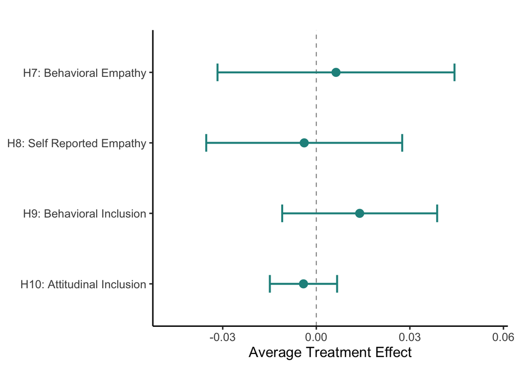

```r
# Define consistent colors (hex) — viridis-like palette adjusted:
cols <- viridis(n = 3,option="D")

models <- list(h7_model, h8_model, h9_model, h10_model)

# Extract PraiseControl coef and 95% CI for each model
coef_df <- lapply(seq_along(models), function(i) {
  m <- models[[i]]
  td <- broom::tidy(m, conf.int = TRUE, conf.level = 0.95)
  row <- td %>% filter(term == "PraiseControl")
  if (nrow(row) == 0) stop(paste0("Coefficient 'PraiseControl' not found in model ", i+6))
  data.frame(
    H = paste0("H", i + 6),                      # H7..H10
    estimate = row$estimate,
    conf.low = row$conf.low,
    conf.high = row$conf.high,
    stringsAsFactors = FALSE
  )
}) %>% bind_rows()

# Descriptive labels
label_map <- c(
  H7  = "H7: Behavioral Empathy",
  H8  = "H8: Self Reported Empathy",
  H9  = "H9: Behavioral Inclusion",
  H10 = "H10: Attitudinal Inclusion"
)

coef_df <- coef_df %>%
  mutate(H_label = label_map[H])

# Order so H7 at top, H10 bottom
coef_df$H_label <- factor(coef_df$H_label, levels = rev(unname(label_map)))

# All points same color "red"
coef_df <- coef_df %>% mutate(group = "greengroup")

# Plot (no numeric point estimate labels)
p <- ggplot(coef_df, aes(x = estimate, y = H_label, color = group)) +
  geom_vline(xintercept = 0, linetype = "dashed", color = "gray60") +
  geom_errorbarh(aes(xmin = conf.low, xmax = conf.high), height = 0.25, size = 0.9) +
  geom_point(size = 3.5) +
  scale_color_manual(values = c("greengroup" = "#21908CFF"),
                     labels = c("greengroup" = "")) +
  labs(x = "Average Treatment Effect", y = NULL,
       color = NULL, title = "") +
  theme_classic(base_size = 14) +
  theme(legend.position = "none",
        panel.grid.major.y = element_blank(),
        panel.grid.minor = element_blank())

# Expand x-axis so error bars are not cut off
x_range <- range(coef_df$conf.low, coef_df$conf.high, coef_df$estimate)
xpad <- diff(x_range) * 0.15
p <- p + scale_x_continuous(limits = c(x_range[1] - xpad, x_range[2] + xpad), labels = comma)

print(p)
```

```r
ggsave(p,file=here::here("Figures","Fig8.pdf"),width=6,height=5)
```

## 2.5 Appendix Table Main Results H7-10

```r
models <- list(h7_model, h8_model, h9_model, h10_model)

# presult1 must be a data.frame with BH_adjusted_p in the same order as models
# Prepare BH-adjusted p-values from presult2 (must be same order as models)
adjp <- presult2$BH_adjusted_p

# Add a row with the BH-adjusted p-values (formatted)
add_line <- list(c("BH-adjusted p-value", formatC(adjp, format = "f", digits = 3)))
col.labels <- paste("H",7:10,sep="")


# Create the stargazer table and write to file
stargazer(
    models,
    type = "latex",
    out = "regression_table2.tex",
    title = "H7-H10 models",
    column.labels = col.labels,
    dep.var.labels.include = FALSE,
    covariate.labels = c("Intercept", "Co-Partisan PeerPraise"),
    keep.stat = c("n", "rsq"),
    add.lines = add_line,
    digits = 2,
    single.row = TRUE,
    no.space = TRUE
)
```

```
##
## % Table created by stargazer v.5.2.3 by Marek Hlavac, Social Policy Institute. E-mail: marek.hlavac at gmail.com
## % Date and time: Thu, Dec 25, 2025 - 15:30:40
## \begin{table}[!htbp] \centering
##   \caption{H7-H10 models}
##   \label{}
## \begin{tabular}{@{\extracolsep{5pt}}lcccc}
## \\[-1.8ex]\hline
## \hline \\[-1.8ex]
##  & \multicolumn{4}{c}{\textit{Dependent variable:}} \\
## \cline{2-5}
##  & H7 & H8 & H9 & H10 \\
## \\[-1.8ex] & (1) & (2) & (3) & (4)\\
## \hline \\[-1.8ex]
##  Intercept & 0.01 (0.02) & $-$0.004 (0.02) & 0.01 (0.01) & $-$0.004 (0.01) \\
##   Co-Partisan PeerPraise & 0.44$^{***}$ (0.01) & 2.37$^{***}$ (0.01) & 0.45$^{***}$ (0.01) & 1.45$^{***}$ (0.004) \\
##  \hline \\[-1.8ex]
## BH-adjusted p-value & 0.809 & 0.809 & 0.809 & 0.809 \\
## Observations & 2,628 & 2,914 & 2,914 & 2,914 \\
## R$^{2}$ & 0.0000 & 0.0000 & 0.0004 & 0.0002 \\
## \hline
## \hline \\[-1.8ex]
## \textit{Note:}  & \multicolumn{4}{r}{$^{*}$p$<$0.1; $^{**}$p$<$0.05; $^{***}$p$<$0.01} \\
## \end{tabular}
## \end{table}
```

```r
#Table E.21 in Appendix
```

## 2.6 Robustness

### 2.6.1 Did respondents engage in empathy more with white faces?

```r
#In H7 we tested if, among White respondents seeing BH image, co-partisan peer praise could influence willingness to engage in behavioral empathy (empathy task).
checkdata<-data3White
checkdata$Image_race<-factor(checkdata$Image_race,levels=c("B","L","W"))

#Broken down by W or BL faces
check1<-lm(empathytask~PraiseControl*Image_raceBH,data=checkdata)
summary(check1)
```

```
##
## Call:
## lm(formula = empathytask ~ PraiseControl * Image_raceBH, data = checkdata)
##
## Residuals:
##     Min      1Q  Median      3Q     Max
## -0.4598 -0.4426 -0.4363  0.5574  0.5676
##
## Coefficients:
##                             Estimate Std. Error t value Pr(>|t|)
## (Intercept)                 0.432432   0.040829  10.591   <2e-16 ***
## PraiseControl               0.027422   0.058889   0.466    0.642
## Image_raceBH                0.003861   0.043099   0.090    0.929
## PraiseControl:Image_raceBH -0.021104   0.061996  -0.340    0.734
## ---
## Signif. codes:  0 '***' 0.001 '**' 0.01 '*' 0.05 '.' 0.1 ' ' 1
##
## Residual standard error: 0.4967 on 2909 degrees of freedom
##   (1 observation deleted due to missingness)
## Multiple R-squared:  0.0001244,  Adjusted R-squared:  -0.0009067
## F-statistic: 0.1207 on 3 and 2909 DF,  p-value: 0.948
```

```r
#Broken down by B, L, W faces
check1<-lm(empathytask~PraiseControl*Image_race,data=checkdata)
summary(check1)
```

```
##
## Call:
## lm(formula = empathytask ~ PraiseControl * Image_race, data = checkdata)
##
## Residuals:
##     Min      1Q  Median      3Q     Max
## -0.4598 -0.4372 -0.4318  0.5628  0.5682
##
## Coefficients:
##                            Estimate Std. Error t value Pr(>|t|)
## (Intercept)               0.4318418  0.0160263  26.946   <2e-16 ***
## PraiseControl             0.0053390  0.0225602   0.237    0.813
## Image_raceL               0.0172600  0.0315570   0.547    0.584
## Image_raceW               0.0005906  0.0438702   0.013    0.989
## PraiseControl:Image_raceL 0.0031864  0.0441046   0.072    0.942
## PraiseControl:Image_raceW 0.0220826  0.0630743   0.350    0.726
## ---
## Signif. codes:  0 '***' 0.001 '**' 0.01 '*' 0.05 '.' 0.1 ' ' 1
##
## Residual standard error: 0.4968 on 2907 degrees of freedom
##   (1 observation deleted due to missingness)
## Multiple R-squared:  0.0003787,  Adjusted R-squared:  -0.001341
## F-statistic: 0.2203 on 5 and 2907 DF,  p-value: 0.9539
```

Respondents didn’t engage differently with images of different race/ethnicities.

### 2.6.2 Other HTEs

#### 2.6.2.1 Respondent Gender

Are there heterogeneous treatment effects by gender?

```r
#H7: DV is Behavioral Empathy
check2_1<-lm(empathytask~PraiseControl*sex,data=data3White_BH)
summary(check2_1)
```

```
##
## Call:
## lm(formula = empathytask ~ PraiseControl * sex, data = data3White_BH)
##
## Residuals:
##     Min      1Q  Median      3Q     Max
## -0.5714 -0.4876 -0.3571  0.5123  0.6429
##
## Coefficients:
##                              Estimate Std. Error t value Pr(>|t|)
## (Intercept)                  0.487646   0.017787  27.416  < 2e-16 ***
## PraiseControl                0.001047   0.024940   0.042    0.967
## sexMale                     -0.130503   0.028511  -4.577 4.93e-06 ***
## sexNon-binary               -0.059075   0.133021  -0.444    0.657
## sexOther                    -0.078555   0.106654  -0.737    0.461
## PraiseControl:sexMale        0.009825   0.039841   0.247    0.805
## PraiseControl:sexNon-binary  0.115836   0.200294   0.578    0.563
## PraiseControl:sexOther       0.161290   0.215492   0.748    0.454
## ---
## Signif. codes:  0 '***' 0.001 '**' 0.01 '*' 0.05 '.' 0.1 ' ' 1
##
## Residual standard error: 0.4932 on 2620 degrees of freedom
## Multiple R-squared:  0.01537,    Adjusted R-squared:  0.01274
## F-statistic: 5.844 on 7 and 2620 DF,  p-value: 9.544e-07
```

```r
#H8: DV is Self Reported Empathy
check2_2<-lm(post_empathyselfindex~PraiseControl*sex,data=data3White)
summary(check2_2)
```

```
##
## Call:
## lm(formula = post_empathyselfindex ~ PraiseControl * sex, data = data3White)
##
## Residuals:
##      Min       1Q   Median       3Q      Max
## -2.42679 -0.26805  0.07321  0.32321  0.73195
##
## Coefficients:
##                              Estimate Std. Error t value Pr(>|t|)
## (Intercept)                  2.417055   0.014538 166.258  < 2e-16 ***
## PraiseControl                0.009733   0.020431   0.476    0.634
## sexMale                     -0.124628   0.023295  -5.350 9.48e-08 ***
## sexNon-binary                0.116279   0.110972   1.048    0.295
## sexOther                     0.128400   0.091998   1.396    0.163
## PraiseControl:sexMale       -0.034114   0.032686  -1.044    0.297
## PraiseControl:sexNon-binary  0.138752   0.170369   0.814    0.415
## PraiseControl:sexOther       0.119812   0.163783   0.732    0.465
## ---
## Signif. codes:  0 '***' 0.001 '**' 0.01 '*' 0.05 '.' 0.1 ' ' 1
##
## Residual standard error: 0.4261 on 2906 degrees of freedom
## Multiple R-squared:  0.03125,    Adjusted R-squared:  0.02892
## F-statistic: 13.39 on 7 and 2906 DF,  p-value: < 2.2e-16
```

```r
#H9: Behavioral Inclusion
check2_3<-lm(behavioralindex~PraiseControl*sex,data=data3White)
summary(check2_3)
```

```
##
## Call:
## lm(formula = behavioralindex ~ PraiseControl * sex, data = data3White)
##
## Residuals:
##     Min      1Q  Median      3Q     Max
## -0.5634 -0.2497 -0.1497  0.3197  0.6003
##
## Coefficients:
##                              Estimate Std. Error t value Pr(>|t|)
## (Intercept)                  0.403667   0.011367  35.513  < 2e-16 ***
## PraiseControl               -0.003951   0.015974  -0.247  0.80467
## sexMale                      0.126625   0.018213   6.952 4.42e-12 ***
## sexNon-binary               -0.207000   0.086764  -2.386  0.01711 *
## sexOther                    -0.194576   0.071930  -2.705  0.00687 **
## PraiseControl:sexMale        0.037039   0.025556   1.449  0.14735
## PraiseControl:sexNon-binary  0.052739   0.133204   0.396  0.69219
## PraiseControl:sexOther       0.004860   0.128055   0.038  0.96973
## ---
## Signif. codes:  0 '***' 0.001 '**' 0.01 '*' 0.05 '.' 0.1 ' ' 1
##
## Residual standard error: 0.3331 on 2906 degrees of freedom
## Multiple R-squared:  0.05326,    Adjusted R-squared:  0.05098
## F-statistic: 23.35 on 7 and 2906 DF,  p-value: < 2.2e-16
```

```r
#H10: DV is Attitudinal Inclusion
check2_4<-lm(post_attitudinalindex~PraiseControl*sex,data=data3White)
summary(check2_4)
```

```
##
## Call:
## lm(formula = post_attitudinalindex ~ PraiseControl * sex, data = data3White)
##
## Residuals:
##      Min       1Q   Median       3Q      Max
## -0.96117 -0.07284  0.01258  0.06332  0.57050
##
## Coefficients:
##                               Estimate Std. Error t value Pr(>|t|)
## (Intercept)                  1.4540900  0.0050571 287.536   <2e-16 ***
## PraiseControl               -0.0007453  0.0071070  -0.105   0.9165
## sexMale                     -0.0169337  0.0081032  -2.090   0.0367 *
## sexNon-binary                0.0325766  0.0386020   0.844   0.3988
## sexOther                     0.0171221  0.0320019   0.535   0.5927
## PraiseControl:sexMale       -0.0069069  0.0113698  -0.607   0.5436
## PraiseControl:sexNon-binary -0.0288001  0.0592634  -0.486   0.6270
## PraiseControl:sexOther      -0.0188001  0.0569725  -0.330   0.7414
## ---
## Signif. codes:  0 '***' 0.001 '**' 0.01 '*' 0.05 '.' 0.1 ' ' 1
##
## Residual standard error: 0.1482 on 2906 degrees of freedom
## Multiple R-squared:  0.005321,   Adjusted R-squared:  0.002925
## F-statistic: 2.221 on 7 and 2906 DF,  p-value: 0.0299
```

No evidence of HTEs by gender.

#### 2.6.2.2 Respondent Age

Are there heterogeneous treatment effects by age?

```r
#H7: DV is Behavioral Empathy
check3_1<-lm(empathytask~PraiseControl*age,data=data3White_BH)
summary(check3_1)
```

```
##
## Call:
## lm(formula = empathytask ~ PraiseControl * age, data = data3White_BH)
##
## Residuals:
##     Min      1Q  Median      3Q     Max
## -0.4979 -0.4466 -0.4045  0.5436  0.7096
##
## Coefficients:
##                    Estimate Std. Error t value Pr(>|t|)
## (Intercept)        0.611956   0.068938   8.877  < 2e-16 ***
## PraiseControl     -0.045933   0.094706  -0.485  0.62771
## age               -0.005187   0.001994  -2.601  0.00936 **
## PraiseControl:age  0.001567   0.002729   0.574  0.56572
## ---
## Signif. codes:  0 '***' 0.001 '**' 0.01 '*' 0.05 '.' 0.1 ' ' 1
##
## Residual standard error: 0.4957 on 2624 degrees of freedom
## Multiple R-squared:  0.004041,   Adjusted R-squared:  0.002902
## F-statistic: 3.549 on 3 and 2624 DF,  p-value: 0.01392
```

```r
#H8: DV is Self Reported Empathy
check3_2<-lm(post_empathyselfindex~PraiseControl*age,data=data3White)
summary(check3_2)
```

```
##
## Call:
## lm(formula = post_empathyselfindex ~ PraiseControl * age, data = data3White)
##
## Residuals:
##     Min      1Q  Median      3Q     Max
## -2.3749 -0.3691  0.1271  0.3773  0.6316
##
## Coefficients:
##                     Estimate Std. Error t value Pr(>|t|)
## (Intercept)        2.371e+00  5.645e-02  41.996   <2e-16 ***
## PraiseControl     -9.571e-04  7.791e-02  -0.012    0.990
## age                6.538e-05  1.626e-03   0.040    0.968
## PraiseControl:age -8.577e-05  2.240e-03  -0.038    0.969
## ---
## Signif. codes:  0 '***' 0.001 '**' 0.01 '*' 0.05 '.' 0.1 ' ' 1
##
## Residual standard error: 0.4326 on 2910 degrees of freedom
## Multiple R-squared:  2.07e-05,   Adjusted R-squared:  -0.00101
## F-statistic: 0.02008 on 3 and 2910 DF,  p-value: 0.9961
```

```r
#H9: Behavioral Inclusion
check3_3<-lm(behavioralindex~PraiseControl*age,data=data3White)
summary(check3_3)
```

```
##
## Call:
## lm(formula = behavioralindex ~ PraiseControl * age, data = data3White)
##
## Residuals:
##     Min      1Q  Median      3Q     Max
## -0.4820 -0.2607 -0.1618  0.3576  0.5659
##
## Coefficients:
##                     Estimate Std. Error t value Pr(>|t|)
## (Intercept)        0.4112212  0.0446322   9.214   <2e-16 ***
## PraiseControl      0.0410266  0.0616008   0.666    0.505
## age                0.0010407  0.0012857   0.809    0.418
## PraiseControl:age -0.0007982  0.0017712  -0.451    0.652
## ---
## Signif. codes:  0 '***' 0.001 '**' 0.01 '*' 0.05 '.' 0.1 ' ' 1
##
## Residual standard error: 0.342 on 2910 degrees of freedom
## Multiple R-squared:  0.000652,   Adjusted R-squared:  -0.0003783
## F-statistic: 0.6328 on 3 and 2910 DF,  p-value: 0.5938
```

```r
#H10: DV is Attitudinal Inclusion
check3_4<-lm(post_attitudinalindex~PraiseControl*age,data=data3White)
summary(check3_3)
```

```
##
## Call:
## lm(formula = behavioralindex ~ PraiseControl * age, data = data3White)
##
## Residuals:
##     Min      1Q  Median      3Q     Max
## -0.4820 -0.2607 -0.1618  0.3576  0.5659
##
## Coefficients:
##                     Estimate Std. Error t value Pr(>|t|)
## (Intercept)        0.4112212  0.0446322   9.214   <2e-16 ***
## PraiseControl      0.0410266  0.0616008   0.666    0.505
## age                0.0010407  0.0012857   0.809    0.418
## PraiseControl:age -0.0007982  0.0017712  -0.451    0.652
## ---
## Signif. codes:  0 '***' 0.001 '**' 0.01 '*' 0.05 '.' 0.1 ' ' 1
##
## Residual standard error: 0.342 on 2910 degrees of freedom
## Multiple R-squared:  0.000652,   Adjusted R-squared:  -0.0003783
## F-statistic: 0.6328 on 3 and 2910 DF,  p-value: 0.5938
```

No evidence to support age HTEs.

#### 2.6.2.3 Respondent Education

Are there heterogeneous treatment effects by education?

```r
#H7: DV is Behavioral Empathy
check4_1<-lm(empathytask~PraiseControl*education_level,data=data3White_BH)
summary(check4_1)
```

```
##
## Call:
## lm(formula = empathytask ~ PraiseControl * education_level, data = data3White_BH)
##
## Residuals:
##     Min      1Q  Median      3Q     Max
## -0.4488 -0.4463 -0.4202  0.5537  0.8333
##
## Coefficients:
##                                     Estimate Std. Error t value Pr(>|t|)
## (Intercept)                           0.1667     0.2026   0.823    0.411
## PraiseControl                        -0.1667     0.2865  -0.582    0.561
## education_levelMedium                 0.2797     0.2033   1.376    0.169
## education_levelHigh                   0.2536     0.2039   1.243    0.214
## PraiseControl:education_levelMedium   0.1627     0.2875   0.566    0.572
## PraiseControl:education_levelHigh     0.1952     0.2883   0.677    0.498
##
## Residual standard error: 0.4962 on 2580 degrees of freedom
##   (42 observations deleted due to missingness)
## Multiple R-squared:  0.002914,   Adjusted R-squared:  0.0009812
## F-statistic: 1.508 on 5 and 2580 DF,  p-value: 0.184
```

```r
#H8: DV is Self Reported Empathy
check4_2<-lm(post_empathyselfindex~PraiseControl*education_level,data=data3White)
summary(check4_2)
```

```
##
## Call:
## lm(formula = post_empathyselfindex ~ PraiseControl * education_level,
##     data = data3White)
##
## Residuals:
##      Min       1Q   Median       3Q      Max
## -2.28932 -0.28932 -0.02485  0.22515  1.00000
##
## Coefficients:
##                                     Estimate Std. Error t value Pr(>|t|)
## (Intercept)                           2.0000     0.1453  13.767  < 2e-16 ***
## PraiseControl                         0.2143     0.2127   1.008 0.313716
## education_levelMedium                 0.2799     0.1459   1.918 0.055166 .
## education_levelHigh                   0.5519     0.1464   3.769 0.000167 ***
## PraiseControl:education_levelMedium  -0.2049     0.2135  -0.960 0.337371
## PraiseControl:education_levelHigh    -0.2414     0.2142  -1.127 0.260045
## ---
## Signif. codes:  0 '***' 0.001 '**' 0.01 '*' 0.05 '.' 0.1 ' ' 1
##
## Residual standard error: 0.4109 on 2860 degrees of freedom
##   (48 observations deleted due to missingness)
## Multiple R-squared:  0.0822, Adjusted R-squared:  0.08059
## F-statistic: 51.23 on 5 and 2860 DF,  p-value: < 2.2e-16
```

```r
#H9: Behavioral Inclusion
check4_3<-lm(behavioralindex~PraiseControl*education_level,data=data3White)
summary(check4_3)
```

```
##
## Call:
## lm(formula = behavioralindex ~ PraiseControl * education_level,
##     data = data3White)
##
## Residuals:
##     Min      1Q  Median      3Q     Max
## -0.5137 -0.2637 -0.1204  0.3581  0.6581
##
## Coefficients:
##                                     Estimate Std. Error t value Pr(>|t|)
## (Intercept)                          0.08750    0.11784   0.743 0.457812
## PraiseControl                        0.08393    0.17249   0.487 0.626609
## education_levelMedium                0.42518    0.11835   3.592 0.000333 ***
## education_levelHigh                  0.25444    0.11878   2.142 0.032276 *
## PraiseControl:education_levelMedium -0.08295    0.17319  -0.479 0.632001
## PraiseControl:education_levelHigh   -0.05549    0.17378  -0.319 0.749528
## ---
## Signif. codes:  0 '***' 0.001 '**' 0.01 '*' 0.05 '.' 0.1 ' ' 1
##
## Residual standard error: 0.3333 on 2860 degrees of freedom
##   (48 observations deleted due to missingness)
## Multiple R-squared:  0.05319,    Adjusted R-squared:  0.05154
## F-statistic: 32.13 on 5 and 2860 DF,  p-value: < 2.2e-16
```

```r
#H10: DV is Attitudinal Inclusion
check4_4<-lm(post_attitudinalindex~PraiseControl*education_level,data=data3White)
summary(check4_4)
```

```
##
## Call:
## lm(formula = post_attitudinalindex ~ PraiseControl * education_level,
##     data = data3White)
##
## Residuals:
##      Min       1Q   Median       3Q      Max
## -0.97653 -0.07631  0.01869  0.06997  0.55514
##
## Coefficients:
##                                      Estimate Std. Error t value Pr(>|t|)
## (Intercept)                          1.439167   0.051328  28.038   <2e-16 ***
## PraiseControl                        0.161310   0.075137   2.147   0.0319 *
## education_levelMedium                0.008810   0.051553   0.171   0.8643
## education_levelHigh                  0.007534   0.051741   0.146   0.8842
## PraiseControl:education_levelMedium -0.164426   0.075440  -2.180   0.0294 *
## PraiseControl:education_levelHigh   -0.172417   0.075697  -2.278   0.0228 *
## ---
## Signif. codes:  0 '***' 0.001 '**' 0.01 '*' 0.05 '.' 0.1 ' ' 1
##
## Residual standard error: 0.1452 on 2860 degrees of freedom
##   (48 observations deleted due to missingness)
## Multiple R-squared:  0.003694,   Adjusted R-squared:  0.001952
## F-statistic: 2.121 on 5 and 2860 DF,  p-value: 0.06015
```

```r
#PraiseControl                        0.161310   0.075137   2.147   0.0319 *
#PraiseControl:education_levelMedium -0.164426   0.075440  -2.180   0.0294 *
#PraiseControl:education_levelHigh   -0.172417   0.075697  -2.278   0.0228 *
confint(check4_4, level = 0.95) # TreatxLow=0.01398108  0.30863797; TreatxMid=-0.31234742 -0.01650464; TreatxHigh=-0.32084225 -0.02399112
```

|  | 2.5 % | 97.5 % |
| --- | --- | --- |
| (Intercept) | 1.3385222 | 1.5398112 |
| PraiseControl | 0.0139811 | 0.3086380 |
| education_levelMedium | -0.0922755 | 0.1098953 |
| education_levelHigh | -0.0939193 | 0.1089865 |
| PraiseControl:education_levelMedium | -0.3123474 | -0.0165046 |
| PraiseControl:education_levelHigh | -0.3208423 | -0.0239911 |

Exploratory analysis suggests education moderates co-partisan peer praise effect on attitudinal inclusion.